# Supplementary Materials for TEDS Attrition Bias Paper

**Contents**

- Pre-registration Changes
- Descriptive Statistics
- Study Variables
- Participant Ages
- Maternal Education
- Longitudinal Participation Patterns
- Research Question 1: Predictors of Attrition
- Variables in Imputation Model
- Logistic Regression Coefficients
- Education Marginal Effects Plot
- Ethnicity Marginal Effects Plot
- Research Question 2: Effects of Attrition(ing)
- Toddlerhood Outcomes - Attritioned vs Original Estimates (Bias)
- Sample Sizes
- Sample Size Table
- Means and Variances
- Variance of Maternal Education
- Correlation Changes Plot
- Correlations
- ACE Estimates
- Adolescent Outcomes and Polygenic Scores - Attritioned vs Original Estimates (Bias)
- Sample Sizes
- Means and Variances
- Correlations
- Number of Significant Correlation Changes
- Sensitivity Analysis: Chip-adjusted PGS
- ACE Estimates
- Research Question 3: Evaluating methods for correcting attrition bias
- Imputation Model
- Auxiliary Variables Selected by quickpred
- Fraction of Missing Information
- Bias of Unadjusted, Weighted and Imputed Estimates
- Mean Absolute Bias (Means, Variances & Correlations)
- Bias by Parameter
- Bias by Outcome
- ACE Estimates
- Impact of Imputation Method (Inclusive vs quickpred)
- Imputation Convergence
- quickpred vs Inclusive Imputation
- Discussion
- Maternal Education & Child Outcomes
- Maternal Education Distribution

# Changes from the pre-registration

← Back to Online Supplement

Here, we describe all changes from the [pre-registration](https://osf.io/v8sgf/files/tp8h3) to the manuscript. Note that the pre-registration is available as a PDF in the “files” section of the OSF registration.

It is worth noting some changes to the numbering of research questions from the pre-registration to the manuscript. Pre-registration research question 3 has been moved to the descriptive statistics section. Pre-registration questions 4 and 5 have been merged into manuscript research question 3.

## All Research Questions

### Major Changes

- Participation time points 2, 7, and 14 were dropped from all analyses because not all participants were eligible to participate at these time points.
- To shorten the manuscript and reduce the number of analyses, for research questions 4–5 we focused only on the four adolescence measures and did not analyse the toddlerhood measures.
- The pre-registration did not specify exclusion criteria; we therefore applied the standard TEDS exclusion criteria provided in the online documentation.

## RQ1

### Major Changes

- Instead of fitting multivariate logistic regression models, we used univariate (single outcome) logistic regression with cluster-robust standard errors and Wald tests.
- McFadden’s R^2 was added as a measure of prediction accuracy.
- Participation in web tests and questionnaires at the same time point was modelled separately.

### Minor Changes

- We dropped the following variables from the analyses: twin genetic problems (agenpro1/2), mother/father social class (amoclass/afaclass), mother/father has a job (amojob/afajob), mother/father needs special qualification for job (amospq/afaspq).

## RQ2

### Major Changes

- We added baseline maternal education as an outcome variable.
- We dropped anxiety symptoms (GAD-D) as an outcome variable.
- As with RQ1, we omitted Hellinger’s distance and SRMR from the models, and compared variances and correlations instead of covariances.
- Outcomes were narrowed to single time points. Where the pre-registration specified each phenotype across multiple ages (e.g., depression at ages 12, 16, 21, and 26), the manuscript analyses each outcome at a single age (Cognitive Y12, GCSE Y16, Depression Y12, Externalising Y12).
- Twin models were fitted separately by sex.

## RQ3

### Major Changes

- Instead of generating time-point-specific weights, we created individualised weights for each variable and pair of variables, as several variables showed uneven missingness even within the same time point.
- IP-weight truncation at the 1st and 99th percentiles was added (not pre-specified).
- We increased the number of imputations from 100 to 250.

### Minor Changes

- Instead of using IP weights fitted to model participation at a given timepoint, we used IP weights fitted to model missingness in each variable or pair of variables.
- We increased the number of imputed datasets to 250 and iterations to 75.

# Descriptive Statistics: All Study Variables

The table below lists every variable used across the analyses, grouped into five panels: (A) baseline variables used to predict later participation and for IP weighting, (B) participation indicators at each wave (1 = participated, 0 = did not), (C) toddlerhood outcome measures (RQ2), (D) adolescent outcome measures (RQ2-3), and (E) polygenic scores (PGS). PGS are available only for genotyped twins of White ethnic origin; they were residualised on the first 10 genetic principal components and standardised in the PGS analysis sample (MZ twins weighted 0.5 so each genotype counts once), so their means and variances here are close to, but not exactly, 0 and 1. For each variable we report a short label, a description, the TEDS variable code (an asterisk denotes a code that was recoded/renamed from the raw TEDS data), the observed range or factor levels, the mean and variance, the number of non-missing observations, and the study wave at which it was collected.

```r
# Function to map variable prefix to study wave
get_study_wave = function(var_name) {
  prefix = substr(var_name, 1, 1)
  wave_map = c(
    "a" = "1st Contact",
    "b" = "2 Year",
    "c" = "3 Year",
    "d" = "4 Year",
    "e" = "In Home",
    "g" = "7 Year",
    "h" = "8 Year",
    "i" = "9 Year",
    "j" = "10 Year",
    "l" = "12 Year",
    "n" = "14 Year",
    "p" = "16 Year",
    "r" = "18 Year",
    "u" = "21 Year",
    "z" = "26 Year"
  )
  return(wave_map[prefix])
}

# Function to clean description labels
clean_description = function(x) {
  x %>%
    # Remove range info at end (e.g., ", 0-22", ", 1-9", ", 4-11")
    str_remove(", \\d+-\\d+$") %>%
    # Remove "see value labels"
    str_remove(", see value labels") %>%
    str_remove("see value labels") %>%
    # Spell out abbreviations inline
    str_replace("SOC employment", "Standard Occupational Classification employment") %>%
    str_replace("MHQ\\)", "Mental Health Questionnaire)") %>%
    str_replace("SLQ\\)", "questionnaire)") %>%
    str_replace("G-game", "G-game (general cognitive ability)") %>%
    str_replace_all(" qnr", " questionnaire") %>%
    # Clean up extra whitespace

    str_squish()
}

# Nominal (unordered) factors: no meaningful mean, excluded from Mean/Variance columns
nominal_vars = c("afasoc2", "amosoc2", "aethnicc", "alang")

# Factors whose level order does not follow the intended ordinal scale (mother/father
# qualification codes come from different underlying SPSS numeric codes), so we map
# them onto a common, substantively-ordered scale instead of using the raw level order
quals_vars = c("afahqual", "amohqual")
quals_order = c(
  "no qualifications",
  "CSE grade 2-5 or O-level/GCSE grade D-G",
  "CSE grade 1 or O-level/GCSE grade A-C",
  "A-level or S-level",
  "HNC",
  "HND",
  "undergraduate degree",
  "postgraduate qualification"
)

# Returns a numeric vector suitable for mean()/var(), or NULL for nominal variables.
# Dichotomous/ordinal factors are recoded using their level order (reference/lowest
# level, marked with "*" in the Range/Level column, = 0), matching the existing table convention.
numeric_for_stats = function(var, df, nominal_vars = character(0), quals_vars = character(0), quals_order = NULL) {
  if (var %in% nominal_vars) return(NULL)
  x = df[[var]]
  if (var %in% quals_vars) return(match(as.character(x), quals_order))
  if (is.factor(x)) return(as.numeric(x) - 1)
  if (is.numeric(x)) return(as.numeric(x))
  NULL
}

get_mean_col = function(vars, df, nominal_vars = character(0), quals_vars = character(0), quals_order = NULL) {
  sapply(vars, function(var) {
    x = numeric_for_stats(var, df, nominal_vars, quals_vars, quals_order)
    if (is.null(x)) NA_real_ else mean(x, na.rm = TRUE)
  })
}

get_var_col = function(vars, df, nominal_vars = character(0), quals_vars = character(0), quals_order = NULL) {
  sapply(vars, function(var) {
    x = numeric_for_stats(var, df, nominal_vars, quals_vars, quals_order)
    if (is.null(x)) NA_real_ else stats::var(x, na.rm = TRUE)
  })
}

v_rq1x =
  data.frame(
    `Short Label` = rq1x_labels_clean,
    Description = rq1x_labels,
    `Teds Code` = ifelse(rq1x %in% colnames(df0), rq1x,paste0(rq1x,"*")),
    `Range or Level` = sapply(rq1x, function(var) {
      if (class(df[[var]]) == "numeric") {
        paste0(round(min(df[[var]], na.rm = TRUE), 2), " — ", round(max(df[[var]], na.rm = TRUE), 2))
      } else if (is.factor(df[[var]])) {
        factor_levels = levels(df[[var]])
        paste(c(paste0(factor_levels[1],"*"), factor_levels[-1]), collapse = ", ")
      } else {
        paste(unique(df[[var]]), collapse = ", ")
      }
    }),
    Mean = get_mean_col(rq1x, df, nominal_vars, quals_vars, quals_order),
    Variance = get_var_col(rq1x, df, nominal_vars, quals_vars, quals_order),
    N = sapply(rq1x, function(var) {
      sum(!is.na(df[[var]]))
    }),
    `Study Wave` = sapply(rq1x, get_study_wave)
  )

v_rq1x$Description = str_remove(v_rq1x$Description,"\\(1st.*")
v_rq1x$Description = clean_description(v_rq1x$Description)

# Manual edit for cens01pop98density study wave
v_rq1x$`Study.Wave`[v_rq1x$`Teds.Code` == "cens01pop98density"] = "1st Contact"
v_rq1x$`Study.Wave`[v_rq1x$`Teds.Code` == "pollution1998pca"] = "1st Contact"

# Clean uniform descriptions for participation indicator variables
rq1y_twin_descriptions = c(
  "Parent-report twin booklet data present",
  "Web test data present",
  "Self-report questionnaire data present",
  "Self-report behaviour booklet data present",
  "Self-report questionnaire data present",
  "TEDS21 phase 1 self-report questionnaire data present",
  "TEDS26 Mental Health Questionnaire data present",
  "CATSLife web test data present",
  "Genotyped data present"
)

v_rq1y =
  data.frame(
    `Short Label` = rq1y_twin_labels_clean,
    Description = rq1y_twin_descriptions,
    `Teds Code` = ifelse(rq1y_twin1 %in% colnames(df0), rq1y_twin1, paste0(rq1y_twin1, "*")),
    `Range or Level` = sapply(rq1y_twin1, function(var) {
      if (class(df[[var]]) == "numeric") {
        paste0(round(min(df[[var]], na.rm = TRUE), 2), " — ", round(max(df[[var]], na.rm = TRUE), 2))
      } else if (is.factor(df[[var]])) {
        factor_levels = levels(df[[var]])
        paste(c(paste0(factor_levels[1], "*"), factor_levels[-1]), collapse = ", ")
      } else {
        paste(unique(df[[var]]), collapse = ", ")
      }
    }),
    Mean = get_mean_col(rq1y_twin1, df),
    Variance = get_var_col(rq1y_twin1, df),
    N = sapply(rq1y_twin1, function(var) {
      sum(!is.na(df[[var]]))
    }),
    `Study Wave` = sapply(rq1y_twin, get_study_wave)
  )

v_rq2 = data.frame(
  `Short Label` = rq2y_labels_short,
  Description   = rq2y_labels,
  `Teds Code` = ifelse(rq2y %in% colnames(df0), rq2y,paste0(rq2y,"*")),
  `Range or Level` = sapply(rq2y, function(var) {
    if (class(df[[var]]) == "numeric") {
      paste0(round(min(df[[var]], na.rm = TRUE), 2), " — ", round(max(df[[var]], na.rm = TRUE), 2))
    } else if (is.factor(df[[var]])) {
      factor_levels = levels(df[[var]])
      paste(c(paste0(factor_levels[1],"*"), factor_levels[-1]), collapse = ", ")
    } else {
      paste(unique(df[[var]]), collapse = ", ")
    }
  }),
  Mean = get_mean_col(rq2y, df),
  Variance = get_var_col(rq2y, df),
  N = sapply(rq2y, function(var) {
    sum(!is.na(df[[var]]))
  }),
  `Study Wave` = sapply(rq2y, get_study_wave)
)

v_rq2$Description = str_remove(v_rq2$Description,"\\(2.*")

v_rq3 = data.frame(
  `Short Label` = rq6y_labels,
  Description   = clean_description(var_to_label(rq6y)),
  `Teds Code` = ifelse(rq6y %in% colnames(df0), rq6y, paste0(rq6y, "*")),
  `Range or Level` = sapply(rq6y, function(var) {
    if (class(df[[var]]) == "numeric") {
      paste0(round(min(df[[var]], na.rm = TRUE), 2), " — ", round(max(df[[var]], na.rm = TRUE), 2))
    } else if (is.factor(df[[var]])) {
      factor_levels = levels(df[[var]])
      paste(c(paste0(factor_levels[1], "*"), factor_levels[-1]), collapse = ", ")
    } else {
      paste(unique(df[[var]]), collapse = ", ")
    }
  }),
  Mean = get_mean_col(rq6y, df),
  Variance = get_var_col(rq6y, df),
  N = sapply(rq6y, function(var) {
    sum(!is.na(df[[var]]))
  }),
  `Study Wave` = sapply(rq6y, get_study_wave)
)

# Polygenic scores (twin's own score; ordered as in the PGS plots)
pgs_gwas = c(
  "EA4_no23andme_Okbay2022"             = "Okbay et al., 2022",
  "Cognitive_Demange2021"               = "Demange et al., 2021",
  "ExecutiveFunction_Hatoum2022"        = "Hatoum et al., 2022",
  "MDD_no23andme_Adams2024"             = "Adams et al., 2024",
  "Anxiety_Purves2019"                  = "Purves et al., 2019",
  "Neuroticism_no23andme_Nagel2018"     = "Nagel et al., 2018",
  "ADHD_Demontis2023"                   = "Demontis et al., 2023",
  "Externalizing_Linner2021"            = "Karlsson Linnér et al., 2021",
  "ASD_Grove2019"                       = "Grove et al., 2019",
  "Schizophrenia_Trubetskoy2022"        = "Trubetskoy et al., 2022",
  "Risk_RiskTolerance_Linner2019_FRCT1" = "Karlsson Linnér et al., 2019",
  "SocDepriv_Hill2016_FRCT1"            = "Hill et al., 2016"
)

pgs_table_lookup = pgs_lookup[match(pgs_order, pgs_lookup$label), ]
pgs_table_vars   = paste0(pgs_table_lookup$short, "1")

testthat::test_that("All PGS included in descriptives table", {
  testthat::expect_setequal(pgs_table_vars, pgs_vars1)
  testthat::expect_true(all(pgs_table_lookup$raw %in% names(pgs_gwas)))
})
```

```
Test passed 🥇
```

```r
v_pgs = data.frame(
  `Short Label` = paste0("PGS ", pgs_table_lookup$label),
  Description   = paste0(
    "Polygenic score for ", tolower(pgs_table_lookup$label),
    " (GWAS: ", pgs_gwas[pgs_table_lookup$raw], "), residualised on genetic PCs 1-10 and standardised",
    ifelse(pgs_table_lookup$short == "pgs_anx", "; sign reversed so higher = higher genetic propensity for anxiety", "")
  ),
  `Teds Code` = paste0(pgs_table_lookup$raw, "*"),
  `Range or Level` = sapply(pgs_table_vars, function(var) {
    paste0(round(min(df[[var]], na.rm = TRUE), 2), " — ", round(max(df[[var]], na.rm = TRUE), 2))
  }),
  Mean = get_mean_col(pgs_table_vars, df),
  Variance = get_var_col(pgs_table_vars, df),
  N = sapply(pgs_table_vars, function(var) {
    sum(!is.na(df[[var]]))
  }),
  `Study Wave` = "Genotyped"
)

# Combine all v_rq dataframes with row indices for grouping
v_rq1x_indexed = cbind(row_group = "RQ1 Variables", row_id = 1:nrow(v_rq1x), v_rq1x)
v_rq1y_indexed = cbind(row_group = "RQ1 Outcome Variables", row_id = (nrow(v_rq1x)+1):(nrow(v_rq1x)+nrow(v_rq1y)), v_rq1y)
v_rq2_indexed = cbind(row_group = "RQ2 Variables", row_id = (nrow(v_rq1x)+nrow(v_rq1y)+1):(nrow(v_rq1x)+nrow(v_rq1y)+nrow(v_rq2)), v_rq2)
v_rq3_indexed = cbind(row_group = "RQ3 Variables", row_id = (nrow(v_rq1x)+nrow(v_rq1y)+nrow(v_rq2)+1):(nrow(v_rq1x)+nrow(v_rq1y)+nrow(v_rq2)+nrow(v_rq3)), v_rq3)

n_before_pgs  = nrow(v_rq1x) + nrow(v_rq1y) + nrow(v_rq2) + nrow(v_rq3)
v_pgs_indexed = cbind(row_group = "PGS Variables", row_id = (n_before_pgs + 1):(n_before_pgs + nrow(v_pgs)), v_pgs)

v_rq_combined = rbind(v_rq1x_indexed, v_rq1y_indexed, v_rq2_indexed, v_rq3_indexed, v_pgs_indexed)
rownames(v_rq_combined) = NULL

gt(v_rq_combined) %>%
  tab_row_group(
    label = "E) Polygenic Scores (genotyped twins of White ethnic origin)",
    rows = row_group == "PGS Variables"
  ) %>%
  tab_row_group(
    label = "D) RQ2-3 Adolescence Measures",
    rows = row_group == "RQ3 Variables"
  ) %>%
  tab_row_group(
    label = "C) RQ2 Toddlerhood Measures",
    rows = row_group == "RQ2 Variables"
  ) %>%
  tab_row_group(
    label = "B) RQ1-2 Participation Indicators (1 = yes, 0 = no)",
    rows = row_group == "RQ1 Outcome Variables"
  ) %>%
  tab_row_group(
    label = "A) Baseline variables used to predict later participation, and for IP weighting",
    rows = row_group == "RQ1 Variables"
  ) %>%
  cols_hide(c(row_group, row_id)) %>%
  cols_width(
    `Range.or.Level` ~ px(100),
    Mean ~ px(70),
    Variance ~ px(70)
  ) %>%
  fmt_number(
    columns = c(Mean, Variance),
    decimals = 2
  ) %>%
  sub_missing(
    columns = c(Mean, Variance),
    missing_text = "—"
  ) %>%
  cols_label_with(fn = ~ gsub("\\.", " ", .x)) %>%
  tab_style(
    style = cell_text(font = "Times New Roman", size = px(12)),
    locations = cells_body()
  ) %>%
  tab_style(
    style = cell_text(font = "Times New Roman", size = px(12)),
    locations = cells_column_labels()
  ) %>%
  tab_style(
    style = cell_text(font = "Times New Roman", size = px(12)),
    locations = cells_row_groups()
  ) %>%
  tab_footnote(
    footnote = "Note. MFQ = Mood and Feelings Questionnaire; SDQ = Strengths and Difficulties Questionnaire; GCSE = General Certificate of Secondary Education; KS3 = Key Stage 3; GAD-D = Generalized Anxiety Disorder scale; PARCA = Parent Report of Children's Abilities; MZ = Monozygotic; DZ = Dizygotic; HNC = Higher National Certificate; HND = Higher National Diploma; CSE = Certificate of Secondary Education; PGS = polygenic score; GWAS = genome-wide association study; PCs = principal components; ADHD = attention-deficit/hyperactivity disorder."
  )
```

| Short Label | Description | Teds Code | Range or Level | Mean | Variance | N | Study Wave |
| --- | --- | --- | --- | --- | --- | --- | --- |
| A) Baseline variables used to predict later participation, and for IP weighting |  |  |  |  |  |  |  |
| Twin Sex | Twin sex, 0female 1male | sex1 | 0 — 1 | 0.50 | 0.25 | 25876 | NA |
| Mother age at birth | Age in years of natural mother at time of birth of twins | amumagetw | 14 — 45 | 30.78 | 23.11 | 25402 | 1st Contact |
| Father age at birth | Age in years of natural father at time of birth of twins | adadagetw | 16 — 66 | 33.36 | 34.08 | 22836 | 1st Contact |
| Single Parent | Single Parent | asingle | cohabiting biological mother and father / cohabiting biological parent with other*, single parent | 0.07 | 0.07 | 25428 | 1st Contact |
| Zygosity | Twin pair zygosity (best available estimate), 1MZ 2DZ | zygos | 1*, 2 | 0.66 | 0.22 | 25876 | 26 Year |
| Mother medical risk | Mother medical risk factor composite scale | amedtot | -2.49 — 4.98 | 0.00 | 1.00 | 25864 | 1st Contact |
| Father employment level | Father Standard Occupational Classification employment level | afasoc2* | 1*, 2, 3, 4, 5, 6, 7, 8, 9, caring for children at home, no job | — | — | 22966 | 1st Contact |
| Father education level | Male parent highest qualification level | afahqual | CSE grade 1 or O-level/GCSE grade A-C*, no qualifications, CSE grade 2-5 or O-level/GCSE grade D-G, A-level or S-level, HNC, HND, undergraduate degree, postgraduate qualification | 3.95 | 4.90 | 22902 | 1st Contact |
| Mother employment level | Mother Standard Occupational Classification employment level | amosoc2* | caring for children at home*, 1, 2, 3, 4, 5, 6, 7, 8, 9, no job | — | — | 25486 | 1st Contact |
| Mother education level | Female parent highest qualification level | amohqual | no qualifications*, CSE grade 2-5 or O-level/GCSE grade D-G, CSE grade 1 or O-level/GCSE grade A-C, A-level or S-level, HNC, HND, undergraduate degree, postgraduate qualification | 3.73 | 3.97 | 25466 | 1st Contact |
| Twin medical risk | Twin medical risk factor composite scale | atwmed1 | -1.88 — 3.33 | 0.00 | 1.00 | 25832 | 1st Contact |
| Ethnic origin | Ethnic origin of twins, original codes | aethnicc | White*, Asian, Black, Mixed race, Other | — | — | 25782 | 1st Contact |
| Language at home | Main language spoken at home | alang | other*, English, English + other | — | — | 25516 | 1st Contact |
| Older siblings | Number of older siblings | anoldsib | 0*, 1, 2, 3, 4, 5 or more | 0.79 | 0.92 | 25876 | 1st Contact |
| Younger siblings | Number of younger siblings | anyngsib | 0*, 1, 2 or more | 0.04 | 0.04 | 25876 | 1st Contact |
| Twins club member | Member of a Twins Club | atwclub | 0*, 1 | 0.32 | 0.22 | 24990 | 1st Contact |
| Childcare by others | Twins looked after by anyone else | alookels | 0*, 1 | 0.13 | 0.11 | 24636 | 1st Contact |
| Smoking in pregnancy | Smoked cigarettes while pregnant | asmoke | 0*, 1 | 0.19 | 0.15 | 25768 | 1st Contact |
| Alcohol in pregnancy | Drank alcohol while pregnant | adrink | 0*, 1 | 0.29 | 0.20 | 25620 | 1st Contact |
| Severe stress in pregnancy | Severe stress during pregnancy | astress | 0*, 1 | 0.21 | 0.17 | 25726 | 1st Contact |
| Pollution index | Principal Component of 1998 pollution variables | pollution1998pca | -2.47 — 4.57 | 0.00 | 1.00 | 22884 | 1st Contact |
| B) RQ1-2 Participation Indicators (1 = yes, 0 = no) |  |  |  |  |  |  |  |
| Y4 (parent-report twin booklet) | Parent-report twin booklet data present | dtwdata1 | 0 — 1 | 0.60 | 0.24 | 25876 | 4 Year |
| Y12 (web tests) | Web test data present | lcwdata1 | 0 — 1 | 0.44 | 0.25 | 25876 | 12 Year |
| Y12 (questionnaire) | Self-report questionnaire data present | lcqdata1 | 0 — 1 | 0.44 | 0.25 | 25876 | 12 Year |
| Y16 (behaviour booklet) | Self-report behaviour booklet data present | pcbhdata1 | 0 — 1 | 0.38 | 0.24 | 25876 | 16 Year |
| Y18 (questionnaire) | Self-report questionnaire data present | rcqdata1 | 0 — 1 | 0.53 | 0.25 | 25876 | 18 Year |
| Y21 (TEDS21 phase-1 questionnaire) | TEDS21 phase 1 self-report questionnaire data present | u1cdata1 | 0 — 1 | 0.38 | 0.23 | 25876 | 21 Year |
| Y26 (TEDS26 questionnaire) | TEDS26 Mental Health Questionnaire data present | zmhdata1 | 0 — 1 | 0.33 | 0.22 | 25876 | 26 Year |
| Y26 (CATSLife web tests) | CATSLife web test data present | zcdata1 | 0 — 1 | 0.15 | 0.13 | 25876 | 26 Year |
| Genotyped | Genotyped data present | hasgeno1 | 1, 0, NA | 0.54 | 0.25 | 23780 | 8 Year |
| C) RQ2 Toddlerhood Measures |  |  |  |  |  |  |  |
| Maternal Education | Maternal Education (formatted as numeric variable) | amohqualn1 | 1 — 8 | 3.73 | 3.97 | 25466 | 1st Contact |
| Vocabulary | Vocabulary total score | bvocab1 | 0 — 100 | 48.23 | 636.42 | 11742 | 2 Year |
| Grammar | Grammar composite score | bgramma1 | 0 — 2 | 0.99 | 0.60 | 11695 | 2 Year |
| Parent-admin cognition | Parent-administered Parca mean score | badparn1 | -3.09 — 3.45 | 0.00 | 1.00 | 11677 | 2 Year |
| Parent-report cognition | Parent-reported Parca total score | breparc1 | 0 — 26 | 18.14 | 11.24 | 11784 | 2 Year |
| Conduct problems | Conduct SDQ-comparable Behar subscale | bsdqccont1 | 0 — 8 | 2.24 | 2.17 | 11728 | 2 Year |
| Emotional problems | Emotion SDQ-comparable Behar subscale | bsdqcemot1 | 0 — 4 | 0.68 | 0.72 | 11735 | 2 Year |
| Hyperactivity | Hyperactivity SDQ-comparable Behar subscale | bsdqchypt1 | 0 — 6 | 2.46 | 2.72 | 11748 | 2 Year |
| Peer problems | Peer SDQ-comparable Behar subscale | bsdqcpert1 | 0 — 6 | 1.16 | 0.97 | 11478 | 2 Year |
| Prosocial behavior | Prosocial SDQ-comparable Behar subscale | bsdqcprot1 | 0 — 10 | 6.53 | 4.92 | 11642 | 2 Year |
| D) RQ2-3 Adolescence Measures |  |  |  |  |  |  |  |
| Y12: Depression (MFQ) | MFQ scale from 11 MFQ items (child self-report) at 12 | lcmfqt1 | 0 — 22 | 2.31 | 11.11 | 11403 | 12 Year |
| Y12: Externalising (SDQ) | SDQ Externalising scale at 12 | lsdqext1 | 0 — 20 | 5.42 | 12.03 | 11360 | 12 Year |
| Y12: Cognitive ability | G composite scale from child web tests at 12, standardised | lcg1 | -3.67 — 3.04 | 0.00 | 1.00 | 8444 | 12 Year |
| Y16: GCSE grade | Core subjects (English, maths, science): mean grade in GCSE results (twin exams at 16) | pcexgcsecoregrdm1 | 4 — 11 | 8.90 | 1.51 | 12942 | 16 Year |
| E) Polygenic Scores (genotyped twins of White ethnic origin) |  |  |  |  |  |  |  |
| PGS Executive function | Polygenic score for executive function (GWAS: Hatoum et al., 2022), residualised on genetic PCs 1-10 and standardised | ExecutiveFunction_Hatoum2022* | -3.92 — 3.69 | −0.01 | 1.00 | 12912 | Genotyped |
| PGS Educational attainment | Polygenic score for educational attainment (GWAS: Okbay et al., 2022), residualised on genetic PCs 1-10 and standardised | EA4_no23andme_Okbay2022* | -3.39 — 3.46 | −0.01 | 1.00 | 12912 | Genotyped |
| PGS Cognitive performance | Polygenic score for cognitive performance (GWAS: Demange et al., 2021), residualised on genetic PCs 1-10 and standardised | Cognitive_Demange2021* | -3.59 — 3.49 | −0.01 | 1.00 | 12912 | Genotyped |
| PGS Social deprivation | Polygenic score for social deprivation (GWAS: Hill et al., 2016), residualised on genetic PCs 1-10 and standardised | SocDepriv_Hill2016_FRCT1* | -4.07 — 3.7 | 0.00 | 1.00 | 12912 | Genotyped |
| PGS Schizophrenia | Polygenic score for schizophrenia (GWAS: Trubetskoy et al., 2022), residualised on genetic PCs 1-10 and standardised | Schizophrenia_Trubetskoy2022* | -3.58 — 3.61 | 0.00 | 1.00 | 12912 | Genotyped |
| PGS Anxiety | Polygenic score for anxiety (GWAS: Purves et al., 2019), residualised on genetic PCs 1-10 and standardised; sign reversed so higher = higher genetic propensity for anxiety | Anxiety_Purves2019* | -4.06 — 4 | 0.00 | 1.00 | 12912 | Genotyped |
| PGS Major depression | Polygenic score for major depression (GWAS: Adams et al., 2024), residualised on genetic PCs 1-10 and standardised | MDD_no23andme_Adams2024* | -3.72 — 3.77 | 0.00 | 1.00 | 12912 | Genotyped |
| PGS Neuroticism | Polygenic score for neuroticism (GWAS: Nagel et al., 2018), residualised on genetic PCs 1-10 and standardised | Neuroticism_no23andme_Nagel2018* | -4.11 — 3.57 | 0.01 | 0.99 | 12912 | Genotyped |
| PGS Externalising | Polygenic score for externalising (GWAS: Karlsson Linnér et al., 2021), residualised on genetic PCs 1-10 and standardised | Externalizing_Linner2021* | -3.47 — 3.82 | 0.01 | 1.00 | 12912 | Genotyped |
| PGS Risk tolerance | Polygenic score for risk tolerance (GWAS: Karlsson Linnér et al., 2019), residualised on genetic PCs 1-10 and standardised | Risk_RiskTolerance_Linner2019_FRCT1* | -4.12 — 3.67 | 0.00 | 1.00 | 12912 | Genotyped |
| PGS ADHD | Polygenic score for adhd (GWAS: Demontis et al., 2023), residualised on genetic PCs 1-10 and standardised | ADHD_Demontis2023* | -3.7 — 3.66 | 0.01 | 1.00 | 12912 | Genotyped |
| PGS Autism | Polygenic score for autism (GWAS: Grove et al., 2019), residualised on genetic PCs 1-10 and standardised | ASD_Grove2019* | -3.37 — 3.89 | 0.00 | 1.00 | 12912 | Genotyped |

Note. MFQ = Mood and Feelings Questionnaire; SDQ = Strengths and Difficulties Questionnaire; GCSE = General Certificate of Secondary Education; KS3 = Key Stage 3; GAD-D = Generalized Anxiety Disorder scale; PARCA = Parent Report of Children's Abilities; MZ = Monozygotic; DZ = Dizygotic; HNC = Higher National Certificate; HND = Higher National Diploma; CSE = Certificate of Secondary Education; PGS = polygenic score; GWAS = genome-wide association study; PCs = principal components; ADHD = attention-deficit/hyperactivity disorder.

### Participant Ages at Each Timepoint

The table below summarises the age distribution (in years) at each assessment wave, reporting sample size, mean, SD, minimum, 10th/90th percentiles, and maximum.

```r
df_age_long %>%
  mutate(name = factor(name, levels = paste0(var_to_label(colnames(df_age)), " (", colnames(df_age), ")"))) %>%
  group_by(name) %>%
  summarise(
    n = sum(!is.na(value)),
    mean = mean(value, na.rm = TRUE),
    sd = sd(value, na.rm = TRUE),
    min = min(value, na.rm = TRUE),
    p10 = quantile(value, 0.10, na.rm = TRUE),
    p90 = quantile(value, 0.90, na.rm = TRUE),
    max = max(value, na.rm = TRUE),
    .groups = "drop"
  ) %>%
  gt() %>%
  cols_label(
    name = "Timepoint",
    n = "N",
    mean = "Mean",
    sd = "SD",
    min = "Min",
    p10 = "10th",
    p90 = "90th",
    max = "Max"
  ) %>%
  fmt_number(
    columns = c(mean, sd),
    decimals = 2
  ) %>%
  fmt_number(
    columns = c(min, p10, p90, max),
    decimals = 1
  ) %>%
  fmt_number(
    columns = n,
    use_seps = TRUE,
    decimals = 0
  ) %>%
  tab_header(
    title = "Participant Age at Each Timepoint"
  ) %>%
  tab_style(
    style = cell_text(weight = "bold"),
    locations = cells_column_labels()
  )
```

Participant Age at Each Timepoint

| Timepoint | N | Mean | SD | Min | 10th | 90th | Max |
| --- | --- | --- | --- | --- | --- | --- | --- |
| Age in years of twins at time of 1st Contact (atwinage) | 25,862 | 1.82 | 1.20 | 0.7 | 1.3 | 2.0 | 18.7 |
| Twin age in years on completion of parent booklet (2 Year) (bpbage) | 11,876 | 2.05 | 0.17 | 1.0 | 1.9 | 2.2 | 4.5 |
| Twin age in years on completion of parent booklet (3 Year) (cpbage) | 11,600 | 3.00 | 0.10 | 1.9 | 2.9 | 3.1 | 4.0 |
| Twin age in years on completion of parent booklet (4 Year) (dpbage) | 15,580 | 4.02 | 0.13 | 2.9 | 3.9 | 4.1 | 6.8 |
| Age of twins when parent booklet completed at 7 (gpbage) | 14,862 | 7.12 | 0.27 | 6.3 | 6.8 | 7.5 | 10.0 |
| Age of twins when 8 year questionnaire completed (years) (hage) | 12,922 | 7.93 | 0.53 | 6.9 | 7.2 | 8.7 | 9.5 |
| Age of twins (years) when parent and child booklets completed at 9 (icpage) | 6,675 | 9.02 | 0.28 | 8.5 | 8.7 | 9.4 | 10.1 |
| Age of twin (years) when web tests started at 10 (jcstage1) | 6,199 | 10.07 | 0.29 | 9.4 | 9.7 | 10.4 | 10.8 |
| Age of twin when 12yr child questionnaire returned, years (lcqage1) | 11,529 | 11.28 | 0.70 | 9.8 | 10.2 | 12.1 | 15.6 |
| Age of twin when child questionnaire returned at 14, years (ncqage1) | 6,637 | 14.07 | 0.58 | 12.8 | 13.4 | 14.9 | 20.3 |
| Age of twin on return of behaviour study child booklet at 16, years (pcbhage1) | 9,948 | 16.32 | 0.69 | 14.9 | 15.3 | 17.1 | 21.3 |
| Age of twin on return of 18 year questionnaire, years (rcqage1) | 13,765 | 18.67 | 0.33 | 18.0 | 18.2 | 19.1 | 19.9 |
| Age of twin when TEDS21 phase 1 twin qnr completed, years (u1cage1) | 9,927 | 22.27 | 0.92 | 20.5 | 21.0 | 23.4 | 27.1 |
| Age of twin when CATSLife study activities started, years (zcage1) | 4,008 | 27.76 | 0.87 | 26.1 | 26.6 | 28.9 | 29.8 |

## Maternal Education Distribution

The table below shows the distribution of maternal educational qualification (amohqual) among participants at first contact, reporting the numeric code used in analyses, the education level label, the count, and the percentage of the sample in each category.

```r
all(table(df$amohqual)==table(df$amohqualn))
```

```
[1] TRUE
```

```r
df %>%
  filter(twin == 1) %>%
  count(amohqual) %>%
  mutate(
    numeric_code = as.numeric(amohqual),
    percent = n / sum(n)
  ) %>%
  select(numeric_code, amohqual, n, percent) %>%
  gt() %>%
  cols_label(
    numeric_code = "Code",
    amohqual = "Education Level",
    n = "N",
    percent = "Percent"
  ) %>%
  fmt_percent(columns = percent)
```

| Code | Education Level | N | Percent |
| --- | --- | --- | --- |
| 1 | no qualifications | 1198 | 9.26% |
| 2 | CSE grade 2-5 or O-level/GCSE grade D-G | 1989 | 15.37% |
| 3 | CSE grade 1 or O-level/GCSE grade A-C | 4754 | 36.74% |
| 4 | A-level or S-level | 1693 | 13.09% |
| 5 | HNC | 356 | 2.75% |
| 6 | HND | 484 | 3.74% |
| 7 | undergraduate degree | 1484 | 11.47% |
| 8 | postgraduate qualification | 775 | 5.99% |
| NA | NA | 205 | 1.58% |

### Longitudinal patterns of participation in TEDS

For each twin, we computed whether they participated in each of three periods, each comprising multiple waves of data collection: Years 2-10, 12-16, and 18-26. A twin who participated at least once within a period was classified as “observed” for that period; otherwise, they were classified as “missing”.

The plot below shows the number of participants with data at each combination of these periods. For example, 11,825 twins have data across all three periods, and 2,234 have data across Years 2-16 only, but not between 18-26.

The plot clearly shows that attrition is not monotonic: participants who do not take part in one period often re-participate in a later one. For example, 205 twins did not participate between Years 2-16 but returned between Years 18-26, and 936 twins participated only between Years 12-16, not before or after.

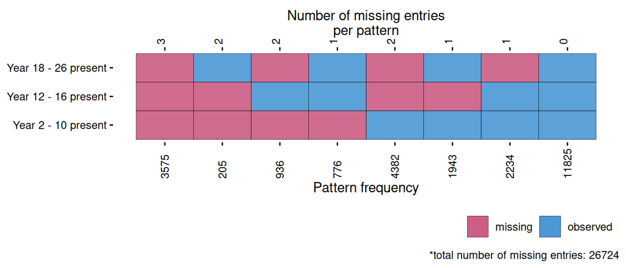

```r
df %>%
  select(all_of(pps_times1)) %>%
  mutate_all(~ tidyr::replace_na(., 0) == 1) %>%
  rowwise() %>%
  mutate(
    `Year 2 - 10 present`  = any(btwdata1, ctwdata1, dtwdata1, gcdata1, icdata1, jcdata1),
    `Year 12 - 16 present` = any(lcwdata1, lcqdata1, pcwebdata1, pcbhdata1, pcl2data1),
    `Year 18 - 26 present` = any(rcqdata1, u1cdata1, zmhdata1, zcdata1)
  ) %>%
  select(ends_with("present")) %>%
  mutate_all(~ na_if(., FALSE)) %>%
  ggmice::plot_pattern(rotate = TRUE) +
  scale_x_discrete(limits = c("Year 2 - 10 present", "Year 12 - 16 present", "Year 18 - 26 present")) +
  theme(
    axis.text   = element_text(color = "black"),
    axis.text.y = element_text(vjust = .5),
    axis.text.x = element_text(vjust = .5)
    ) +
  labs(x = NULL) +
  coord_flip()
```

```r
save_plot("11_participation_pattern_grouped", width = 7, height = 3)
```

# Research Question 1: Predictors of Attrition

### Full list of imputation variables (RQ1)

The table below lists every variable included in the single imputation of baseline/predictor data used for RQ1 (see Singly Impute Missing Predictor/Baseline Data), showing the study wave, description, TEDS variable code, observed range or factor levels, number of non-missing observations, and percent missing prior to imputation.

```r
# Function to map variable prefix to study wave
get_study_wave = function(var_name) {
  prefix = substr(var_name, 1, 1)
  wave_map = c(
    "a" = "1st Contact",
    "b" = "2 Year",
    "c" = "3 Year",
    "d" = "4 Year",
    "e" = "In Home",
    "g" = "7 Year",
    "h" = "8 Year",
    "i" = "9 Year",
    "j" = "10 Year",
    "l" = "12 Year",
    "n" = "14 Year",
    "p" = "16 Year",
    "r" = "18 Year",
    "u" = "21 Year",
    "z" = "26 Year"
  )
  if (var_name %in% c("sex1", "zygos")) return("")
  return(wave_map[prefix])
}

rq1_imputation_vars = colnames(df_rq1)
impute_vars_labels = var_to_label(rq1_imputation_vars) %>%
  sapply(., function(x) ifelse(is.null(x[1]), "", x[1]))

# Create formatted table for imputation variables
v_impute = data.frame(
  `Study.Wave` = sapply(rq1_imputation_vars, get_study_wave),
  Description = impute_vars_labels,
  `Teds Code` = ifelse(rq1_imputation_vars %in% colnames(df0), rq1_imputation_vars, paste0(rq1_imputation_vars, "*")),
  `Range or Level` = sapply(rq1_imputation_vars, function(var) {
    if (var %in% colnames(df)) {
      if (class(df[[var]]) == "numeric") {
        paste0(round(min(df[[var]], na.rm = TRUE), 2), " - ", round(max(df[[var]], na.rm = TRUE), 2))
      } else if (is.factor(df[[var]])) {
        factor_levels = levels(df[[var]])
        paste(c(paste0(factor_levels[1], "*"), factor_levels[-1]), collapse = ", ")
      } else {
        paste(unique(df[[var]]), collapse = ", ")
      }
    } else {
      "Variable not found"
    }
  }),
  N = sapply(rq1_imputation_vars, function(var) {
    if (var %in% colnames(df)) {
      sum(!is.na(df[[var]]))
    } else {
      0
    }
  })
) %>%
  mutate(
    `Percent Missing` = (nrow(df)-N)/nrow(df)
  )

v_impute$Study.Wave[v_impute$Teds.Code=="cohort"]=""

gt(v_impute) %>%
  fmt_percent(`Percent Missing`) %>%
  cols_label_with(fn = ~ gsub("\\.", " ", .x)) %>%
  tab_style(
    style = cell_text(size = px(12)),
    locations = cells_body()
  ) %>%
  tab_style(
    style = cell_text(size = px(12)),
    locations = cells_column_labels()
  ) %>%
  # cols_hide(N) %>%
  tab_source_note(
    source_note = "Note. Range or Level shows min-max values for numeric variables or factor levels for categorical variables (reference level marked with asterisk). Teds codes marked with an asterisk have been derived or modified from the original dataset. N indicate the number of non-missing observations."
  ) %>%
  tab_options(
    table.width = "70%"
  ) %>%
  cols_width(
    Description ~ px(300),
    everything() ~ px(120)
  )
```

| Study Wave | Description | Teds Code | Range or Level | N | Percent Missing |
| --- | --- | --- | --- | --- | --- |
|  | School cohort, see value labels | cohort | Cohort 1: twins born Jan-94 to Aug-94*, Cohort 2: twins born Sep-94 to Aug-95, Cohort 3: twins born Sep-95 to Aug-96, Cohort 4: twins born Sep-96 to Dec-96 | 26040 | 0.00% |
|  | Twin sex, 0female 1male | sex1 | 0 - 1 | 26040 | 0.00% |
| 1st Contact | Age in years of natural mother at time of birth of twins | amumagetw | 14 - 45 | 25563 | 1.83% |
| 1st Contact | Age in years of natural father at time of birth of twins | adadagetw | 16 - 66 | 22975 | 11.77% |
| 1st Contact | Single Parent | asingle | cohabiting biological mother and father / cohabiting biological parent with other*, single parent | 25587 | 1.74% |
|  | Twin pair zygosity (best available estimate), 1MZ 2DZ | zygos | 1*, 2 | 26040 | 0.00% |
| 1st Contact | Mother medical risk factor composite scale (1st Contact), standardised | amedtot | -2.49 - 4.98 | 25864 | 0.68% |
| 1st Contact | Father SOC employment level (1st Contact), 1-9 | afasoc2* | 1*, 2, 3, 4, 5, 6, 7, 8, 9, caring for children at home, no job | 23111 | 11.25% |
| 1st Contact | Male parent highest qualification level (1st Contact), see value labels | afahqual | CSE grade 1 or O-level/GCSE grade A-C*, no qualifications, CSE grade 2-5 or O-level/GCSE grade D-G, A-level or S-level, HNC, HND, undergraduate degree, postgraduate qualification | 23049 | 11.49% |
| 1st Contact | Mother SOC employment level (1st Contact), 1-9 | amosoc2* | caring for children at home*, 1, 2, 3, 4, 5, 6, 7, 8, 9, no job | 25650 | 1.50% |
| 1st Contact | Female parent highest qualification level (1st Contact), see value labels | amohqual | no qualifications*, CSE grade 2-5 or O-level/GCSE grade D-G, CSE grade 1 or O-level/GCSE grade A-C, A-level or S-level, HNC, HND, undergraduate degree, postgraduate qualification | 25629 | 1.58% |
| 1st Contact | Twin medical risk factor composite scale (1st Contact), standardised | atwmed1 | -1.88 - 3.33 | 25832 | 0.80% |
| 1st Contact | Ethnic origin of twins, original codes (1st Contact), see value labels | aethnicc | White*, Asian, Black, Mixed race, Other | 25946 | 0.36% |
| 1st Contact | Main language spoken at home (1st Contact), see value labels | alang | other*, English, English + other | 25678 | 1.39% |
| 1st Contact | Number of older siblings (1st Contact), see value labels | anoldsib | 0*, 1, 2, 3, 4, 5 or more | 26040 | 0.00% |
| 1st Contact | Number of younger siblings (1st Contact), see value labels | anyngsib | 0*, 1, 2 or more | 26040 | 0.00% |
| 1st Contact | Member of a Twins Club (1st Contact), 1Y 0N | atwclub | 0*, 1 | 25148 | 3.43% |
| 1st Contact | Twins looked after by anyone else (1st Contact), 1Y 0N | alookels | 0*, 1 | 24791 | 4.80% |
| 1st Contact | Smoked cigarettes while pregnant (1st Contact), 1Y 0N | asmoke | 0*, 1 | 25932 | 0.41% |
| 1st Contact | Drank alcohol while pregnant (1st Contact), 1Y 0N | adrink | 0*, 1 | 25783 | 0.99% |
| 1st Contact | Severe stress during pregnancy (1st Contact), 1Y 0N | astress | 0*, 1 | 25889 | 0.58% |
| 16 Year | Principal Component of 1998 pollution variables | pollution1998pca | -2.47 - 4.57 | 23030 | 11.56% |
| 4 Year | Twin booklet data present (4 Year), 1Y 0N | dtwdata1 | 0 - 1 | 26040 | 0.00% |
| 12 Year | Twin web data (at least one test) present at 12, 1Y 0N | lcwdata1 | 0 - 1 | 26040 | 0.00% |
| 12 Year | Child questionnaire data present at 12, 1Y 0N | lcqdata1 | 0 - 1 | 26040 | 0.00% |
| 16 Year | Child behaviour booklet data present at 16, 1Y 0N | pcbhdata1 | 0 - 1 | 26040 | 0.00% |
| 18 Year | Twin questionnaire data present at 18, 1Y 0N | rcqdata1 | 0 - 1 | 26040 | 0.00% |
| 21 Year | TEDS21 phase 1 twin qnr data present, 1Y 0N | u1cdata1 | 0 - 1 | 26040 | 0.00% |
| 26 Year | TEDS26 twin MHQ data present, 1Y 0N | zmhdata1 | 0 - 1 | 26040 | 0.00% |
| 26 Year | CATSLife twin web study: data are present, 1Y 0N | zcdata1 | 0 - 1 | 26040 | 0.00% |
| 8 Year | Genotyped | hasgeno1 | 1, 0, NA | 23933 | 8.09% |
| 4 Year | Twin booklet data present (4 Year), 1Y 0N | dtwdata2 | 0 - 1 | 26040 | 0.00% |
| 12 Year | Twin web data (at least one test) present at 12, 1Y 0N | lcwdata2 | 0 - 1 | 26040 | 0.00% |
| 12 Year | Child questionnaire data present at 12, 1Y 0N | lcqdata2 | 0 - 1 | 26040 | 0.00% |
| 16 Year | Child behaviour booklet data present at 16, 1Y 0N | pcbhdata2 | 0 - 1 | 26040 | 0.00% |
| 18 Year | Twin questionnaire data present at 18, 1Y 0N | rcqdata2 | 0 - 1 | 26040 | 0.00% |
| 21 Year | TEDS21 phase 1 twin qnr data present, 1Y 0N | u1cdata2 | 0 - 1 | 26040 | 0.00% |
| 26 Year | TEDS26 twin MHQ data present, 1Y 0N | zmhdata2 | 0 - 1 | 26040 | 0.00% |
| 26 Year | CATSLife twin web study: data are present, 1Y 0N | zcdata2 | 0 - 1 | 26040 | 0.00% |
| 8 Year | Genotyped | hasgeno2 | 1, 0, NA | 23933 | 8.09% |

Note. Range or Level shows min-max values for numeric variables or factor levels for categorical variables (reference level marked with asterisk). Teds codes marked with an asterisk have been derived or modified from the original dataset. N indicate the number of non-missing observations.

### Twin-Level Logistic Regression Coefficients

The table below reports coefficients (with 95% CIs and cluster-robust Wald p-values, clustered by family) from the univariate logistic regressions predicting participation at each study wave from each baseline predictor, one model per outcome column. Cells shaded green indicate a statistically significant predictor (Wald p < .05) for that wave.

```r
# Extract all coefficients from twin models and combine
twinmodels_results0 = do.call(rbind, lapply(1:length(twinmodels), function(i) {
    vcov_robust = clubSandwich::vcovCR(twinmodels[[i]],
                                    cluster = twinmodels[[i]]$data$famid,
                                    type = "CR2")
    coefs       = clubSandwich::conf_int(twinmodels[[i]], vcov = vcov_robust, test = "naive-tp")

    coefs$outcome = rq1y_twin1[i]
  return(coefs)
}))
twinmodels_results = twinmodels_results0 %>%
  data.frame() %>%
  dplyr::rename(term = "Coef") %>%
  `rownames<-`(NULL)


# # Extract all coefficients from twin models and combine
# twinmodels_results = do.call(rbind, lapply(1:length(twinmodels), function(i) {
#   coefs = broom::tidy(twinmodels[[i]], conf.int = FALSE) %>%
#     select(-std.error, -statistic, -p.value)
#   coefs$outcome = rq1y_twin1[i]
#   return(coefs)
# }))

twinmodels_results$var = str_extract(twinmodels_results$term, paste0("^(", paste(rq1x, collapse = "|"), ")"))
twinmodels_results$var[twinmodels_results0$Coef == "(Intercept)"] = "Intercept"
twinmodels_results$var_outcome = paste(twinmodels_results$var,twinmodels_results$outcome, sep = "_")
# Bonferonni-holm corrected p-value
twinmodels_results$Wald_p = glm_model_comparison_results_df$Wald_p[match(twinmodels_results$var_outcome,glm_model_comparison_results_df$var_outcome)]

twinmodels_results %>%
    mutate(
      outcome = rq1y_twin_labels_clean_extrashort[match(.$outcome, rq1y_twin1)],
      term = case_when(
        term == "(Intercept)" ~ "Intercept",
        term == "sex1" ~ "Twin Sex (Male)",
        term == "amumagetw" ~ "Mother age at birth",
        term == "adadagetw" ~ "Father age at birth",
        term == "aadultscohabiting biological parent with other" ~ "Household Type: Cohabiting parent",
        term == "asinglesingle parent" ~ "Single Parent (ref: cohabiting parents)",
        term == "zygos2" ~ "Zygosity (DZ)",
        term == "amedtot" ~ "Mother medical risk",
        str_starts(term, "afasoc2") & str_detect(term, "^afasoc2\\d$") ~ paste0("Father employment: Level ", str_sub(term, -1)),
        term == "afasoc2caring for children at home" ~ "Father employment: Caring for children",
        term == "afasoc2no job" ~ "Father employment: No job",
        term == "afahqualno qualifications" ~ "Father education: No qualifications",
        term == "afahqualCSE grade 2-5 or O-level/GCSE grade D-G" ~ "Father education: CSE/GCSE D-G",
        term == "afahqualA-level or S-level" ~ "Father education: A-level",
        term == "afahqualHNC" ~ "Father education: HNC",
        term == "afahqualHND" ~ "Father education: HND",
        term == "afahqualundergraduate degree" ~ "Father education: Undergraduate",
        term == "afahqualpostgraduate qualification" ~ "Father education: Postgraduate",
        str_starts(term, "amosoc2") & str_detect(term, "^amosoc2\\d$") ~ paste0("Mother employment: Level ", str_sub(term, -1)),
        term == "amosoc2no job" ~ "Mother employment: No job",
        term == "amohqualCSE grade 2-5 or O-level/GCSE grade D-G" ~ "Mother education: CSE/GCSE D-G",
        term == "amohqualCSE grade 1 or O-level/GCSE grade A-C" ~ "Mother education: CSE/GCSE A-C",
        term == "amohqualA-level or S-level" ~ "Mother education: A-level",
        term == "amohqualHNC" ~ "Mother education: HNC",
        term == "amohqualHND" ~ "Mother education: HND",
        term == "amohqualundergraduate degree" ~ "Mother education: Undergraduate",
        term == "amohqualpostgraduate qualification" ~ "Mother education: Postgraduate",
        term == "atwmed1" ~ "Twin medical risk",
        term == "aethniccAsian" ~ "Ethnic origin: Asian",
        term == "aethniccBlack" ~ "Ethnic origin: Black",
        term == "aethniccMixed race" ~ "Ethnic origin: Mixed race",
        term == "aethniccOther" ~ "Ethnic origin: Other",
        term == "alangEnglish" ~ "Language: English only",
        term == "alangEnglish + other" ~ "Language: English + other",
        str_starts(term, "anoldsib") & str_detect(term, "\\d+$") ~ paste0("Older siblings: ", str_extract(term, "\\d+")),
        term == "anoldsib5 or more" ~ "Older siblings: 5+",
        term == "anyngsib1" ~ "Younger siblings: 1",
        term == "anyngsib2 or more" ~ "Younger siblings: 2+",
        term == "atwclub1" ~ "Twins club member",
        term == "alookels1" ~ "Childcare by others",
        term == "asmoke1" ~ "Smoking in pregnancy",
        term == "adrink1" ~ "Alcohol in pregnancy",
        term == "astress1" ~ "Severe stress in pregnancy",
        term == "cens01pop98density" ~ "Population density",
        term == "pollution1998pca" ~ "Pollution index",
        TRUE ~ term
      )
    ) %>%
  mutate(
    beta = gbtoolbox::apa_num(beta, n_decimal_places = 3),
    CI_L = gbtoolbox::apa_num(CI_L, n_decimal_places = 3),
    CI_U = gbtoolbox::apa_num(CI_U, n_decimal_places = 3),
    SE   = gbtoolbox::apa_num(SE,   n_decimal_places = 3),
    Wald_p_clean = gbtoolbox::apa_num(Wald_p, n_decimal_places = 3),

    table_val = paste0(beta,"\n[",CI_L,",\n",CI_U,"]\np=",Wald_p_clean,"\nSE=", SE = SE)
  ) %>%
  select(term, table_val, Wald_p, outcome) %>%
  pivot_wider(
    id_cols = term,
    values_from = c("table_val", "Wald_p"),
    names_from = outcome
  ) %>%
  gt() %>%
  tab_style(
    style = cell_text(whitespace = "pre-wrap"),
    locations = cells_body(columns = starts_with("table_val"))
  ) %>%
  # tab_style(
  #   style = cell_fill(color = "#d5e8d4"),
  #   locations = cells_body(columns = "table_val_Y2", rows = Wald_p_Y2 < 0.05)
  # ) %>%
  # tab_style(
  #   style = cell_fill(color = "#d5e8d4"),
  #   locations = cells_body(columns = "table_val_Y3", rows = Wald_p_Y3 < 0.05)
  # ) %>%
  tab_style(
    style = cell_fill(color = "#d5e8d4"),
    locations = cells_body(columns = "table_val_Y4", rows = Wald_p_Y4 < 0.05)
  ) %>%
  # tab_style(
  #   style = cell_fill(color = "#d5e8d4"),
  #   locations = cells_body(columns = "table_val_Y7", rows = Wald_p_Y7 < 0.05)
  # ) %>%
  # tab_style(
  #   style = cell_fill(color = "#d5e8d4"),
  #   locations = cells_body(columns = "table_val_Y9", rows = Wald_p_Y9 < 0.05)
  # ) %>%
  # tab_style(
  #   style = cell_fill(color = "#d5e8d4"),
  #   locations = cells_body(columns = "table_val_Y10", rows = Wald_p_Y10 < 0.05)
  # ) %>%
  tab_style(
    style = cell_fill(color = "#d5e8d4"),
    locations = cells_body(columns = "table_val_Y12 (web test)", rows = `Wald_p_Y12 (web test)` < 0.05)
  ) %>%
  tab_style(
    style = cell_fill(color = "#d5e8d4"),
    locations = cells_body(columns = "table_val_Y12 (q'aire)", rows = `Wald_p_Y12 (q'aire)` < 0.05)
  ) %>%
  # tab_style(
  #   style = cell_fill(color = "#d5e8d4"),
  #   locations = cells_body(columns = "table_val_Y16 (web)", rows = `Wald_p_Y16 (web)` < 0.05)
  # ) %>%
  tab_style(
    style = cell_fill(color = "#d5e8d4"),
    locations = cells_body(columns = "table_val_Y16 (q'aire)", rows = `Wald_p_Y16 (q'aire)` < 0.05)
  ) %>%
  tab_style(
    style = cell_fill(color = "#d5e8d4"),
    locations = cells_body(columns = "table_val_Y18", rows = Wald_p_Y18 < 0.05)
  ) %>%
  tab_style(
    style = cell_fill(color = "#d5e8d4"),
    locations = cells_body(columns = "table_val_Y21", rows = Wald_p_Y21 < 0.05)
  ) %>%
  tab_style(
    style = cell_fill(color = "#d5e8d4"),
    locations = cells_body(columns = "table_val_Y26 (q'aire)", rows = `Wald_p_Y26 (q'aire)` < 0.05)
  ) %>%
  tab_style(
    style = cell_fill(color = "#d5e8d4"),
    locations = cells_body(columns = "table_val_Y26 (web test)", rows = `Wald_p_Y26 (web test)` < 0.05)
  ) %>%
  tab_style(
    style = cell_fill(color = "#d5e8d4"),
    locations = cells_body(columns = "table_val_Genotyped", rows = Wald_p_Genotyped < 0.05)
  ) %>%
  cols_hide(columns = starts_with("Wald_p")) %>%
  cols_label_with(
    fn = function(x) str_remove(x, "table_val_")
  ) %>%
  tab_options(
      table.width = "100%",
      table.font.size = "12px"
    ) %>%
      cols_width(
      term ~ px(90),
      starts_with("table_val") ~ px(40)
    ) %>%
  tab_source_note(
    source_note = "Note: Confidence intervals calculated using cluster robust standard errors clustered by family, calculated using the clubSandwich R package with CR2 (bias-reduced linearization) adjustment and naive-tp small sample adjustment. Cluster robust Wald tests were used to calculate using the ClubSandwich R package. Note that for dummy variables, Wald tests were performed by constraining all dummy variables in a given set to zero - therefore dummy variables derived from the same categorical variable have the same p-values."
  )
```

| term | Y4 | Y12 (web test) | Y12 (q'aire) | Y16 (q'aire) | Y18 | Y21 | Y26 (q'aire) | Y26 (web test) | Genotyped |
| --- | --- | --- | --- | --- | --- | --- | --- | --- | --- |
| Intercept | -1.156 [-1.604, -.709] p= SE= .228 | -1.645 [-2.089, -1.202] p= SE= .226 | -1.661 [-2.112, -1.211] p= SE= .230 | -1.678 [-2.142, -1.215] p= SE= .237 | -1.498 [-1.951, -1.046] p= SE= .231 | -1.349 [-1.781, -.917] p= SE= .220 | -1.187 [-1.601, -.772] p= SE= .211 | -2.183 [-2.722, -1.644] p= SE= .275 | -.637 [-1.033, -.240] p= SE= .202 |
| Twin Sex (Male) | -.109 [-.182, -.036] p= .038 SE= .037 | -.231 [-.302, -.159] p= .000 SE= .036 | -.181 [-.253, -.109] p= .000 SE= .037 | -.393 [-.467, -.319] p= .000 SE= .038 | -.253 [-.325, -.181] p= .000 SE= .037 | -.683 [-.752, -.613] p= .000 SE= .035 | -.738 [-.806, -.671] p= .000 SE= .034 | -.687 [-.774, -.599] p= .000 SE= .045 | -.153 [-.221, -.085] p= .000 SE= .035 |
| Mother age at birth | .034 [ .024, .044] p= .000 SE= .005 | .026 [ .016, .036] p= .000 SE= .005 | .026 [ .016, .036] p= .000 SE= .005 | .030 [ .019, .040] p= .000 SE= .005 | .045 [ .035, .056] p= .000 SE= .005 | .014 [ .004, .024] p= .054 SE= .005 | .012 [ .003, .022] p= .140 SE= .005 | .012 [-.001, .024] p= .543 SE= .006 | .013 [ .003, .023] p= .095 SE= .005 |
| Father age at birth | .009 [ .001, .017] p= .212 SE= .004 | .006 [-.002, .013] p= .760 SE= .004 | .007 [-.001, .015] p= .574 SE= .004 | .001 [-.008, .009] p=1.000 SE= .004 | .007 [-.001, .015] p= .571 SE= .004 | .009 [ .001, .016] p= .239 SE= .004 | .006 [-.001, .013] p=1.000 SE= .004 | .006 [-.003, .016] p=1.000 SE= .005 | -.001 [-.008, .007] p=1.000 SE= .004 |
| Single Parent (ref: cohabiting parents) | -.430 [-.593, -.268] p= .000 SE= .083 | -.397 [-.565, -.229] p= .000 SE= .086 | -.340 [-.509, -.171] p= .001 SE= .086 | -.473 [-.656, -.291] p= .000 SE= .093 | -.426 [-.591, -.261] p= .000 SE= .084 | -.546 [-.714, -.377] p= .000 SE= .086 | -.424 [-.588, -.261] p= .000 SE= .083 | -.397 [-.624, -.170] p= .010 SE= .116 | -.203 [-.357, -.049] p= .106 SE= .079 |
| Zygosity (DZ) | -.156 [-.235, -.078] p= .001 SE= .040 | -.344 [-.420, -.267] p= .000 SE= .039 | -.324 [-.402, -.247] p= .000 SE= .040 | -.287 [-.366, -.207] p= .000 SE= .041 | -.312 [-.391, -.234] p= .000 SE= .040 | -.287 [-.362, -.213] p= .000 SE= .038 | -.268 [-.340, -.196] p= .000 SE= .037 | -.327 [-.418, -.235] p= .000 SE= .047 | -.850 [-.927, -.773] p= .000 SE= .039 |
| Mother medical risk | -.029 [-.074, .016] p= .965 SE= .023 | -.045 [-.089, -.000] p= .343 SE= .023 | -.020 [-.065, .025] p= .951 SE= .023 | -.057 [-.104, -.011] p= .159 SE= .024 | -.085 [-.129, -.040] p= .002 SE= .023 | -.021 [-.064, .022] p=1.000 SE= .022 | -.031 [-.072, .011] p=1.000 SE= .021 | -.033 [-.087, .020] p=1.000 SE= .027 | -.022 [-.064, .021] p=1.000 SE= .022 |
| Father employment: Level 2 | .161 [ .021, .302] p= .525 SE= .072 | .079 [-.052, .210] p= .343 SE= .067 | .064 [-.068, .197] p= .951 SE= .068 | .125 [-.009, .259] p=1.000 SE= .068 | .160 [ .022, .297] p= .007 SE= .070 | .147 [ .020, .273] p= .141 SE= .065 | .115 [-.006, .235] p= .150 SE= .061 | .140 [-.007, .287] p=1.000 SE= .075 | .084 [-.044, .212] p=1.000 SE= .065 |
| Father employment: Level 3 | -.059 [-.209, .092] p= .525 SE= .077 | .189 [ .044, .334] p= .343 SE= .074 | .103 [-.044, .249] p= .951 SE= .075 | .059 [-.090, .208] p=1.000 SE= .076 | .066 [-.083, .216] p= .007 SE= .076 | .097 [-.043, .238] p= .141 SE= .072 | .043 [-.093, .180] p= .150 SE= .070 | .095 [-.070, .261] p=1.000 SE= .084 | -.071 [-.211, .070] p=1.000 SE= .072 |
| Father employment: Level 4 | .014 [-.190, .217] p= .525 SE= .104 | .167 [-.031, .365] p= .343 SE= .101 | .131 [-.070, .332] p= .951 SE= .103 | .097 [-.110, .303] p=1.000 SE= .105 | .003 [-.199, .206] p= .007 SE= .103 | .051 [-.143, .245] p= .141 SE= .099 | .067 [-.122, .256] p= .150 SE= .096 | .106 [-.132, .345] p=1.000 SE= .122 | -.023 [-.219, .173] p=1.000 SE= .100 |
| Father employment: Level 5 | -.052 [-.170, .066] p= .525 SE= .060 | -.024 [-.140, .092] p= .343 SE= .059 | -.029 [-.146, .087] p= .951 SE= .059 | -.101 [-.221, .020] p=1.000 SE= .061 | -.088 [-.205, .028] p= .007 SE= .059 | -.099 [-.211, .014] p= .141 SE= .057 | -.100 [-.209, .009] p= .150 SE= .056 | -.071 [-.215, .072] p=1.000 SE= .073 | -.023 [-.134, .088] p=1.000 SE= .057 |
| Father employment: Level 6 | -.110 [-.284, .064] p= .525 SE= .089 | .060 [-.109, .228] p= .343 SE= .086 | .042 [-.128, .212] p= .951 SE= .087 | .111 [-.064, .286] p=1.000 SE= .089 | .053 [-.119, .224] p= .007 SE= .087 | -.013 [-.177, .151] p= .141 SE= .084 | .008 [-.151, .167] p= .150 SE= .081 | .042 [-.161, .246] p=1.000 SE= .104 | -.031 [-.195, .133] p=1.000 SE= .084 |
| Father employment: Level 7 | -.182 [-.405, .041] p= .525 SE= .114 | .168 [-.049, .385] p= .343 SE= .111 | .101 [-.122, .324] p= .951 SE= .114 | -.014 [-.246, .217] p=1.000 SE= .118 | .082 [-.138, .301] p= .007 SE= .112 | -.032 [-.250, .185] p= .141 SE= .111 | -.011 [-.213, .192] p= .150 SE= .103 | .047 [-.213, .307] p=1.000 SE= .133 | .050 [-.163, .263] p=1.000 SE= .109 |
| Father employment: Level 8 | .032 [-.115, .178] p= .525 SE= .075 | -.019 [-.165, .126] p= .343 SE= .074 | -.101 [-.249, .046] p= .951 SE= .075 | .003 [-.148, .155] p=1.000 SE= .077 | -.052 [-.197, .094] p= .007 SE= .074 | -.072 [-.213, .069] p= .141 SE= .072 | -.046 [-.182, .089] p= .150 SE= .069 | -.140 [-.329, .049] p=1.000 SE= .096 | -.025 [-.164, .113] p=1.000 SE= .071 |
| Father employment: Level 9 | .083 [-.110, .276] p= .525 SE= .098 | .077 [-.115, .270] p= .343 SE= .098 | .100 [-.094, .294] p= .951 SE= .099 | .027 [-.175, .230] p=1.000 SE= .103 | .116 [-.074, .305] p= .007 SE= .097 | -.085 [-.275, .104] p= .141 SE= .097 | -.132 [-.316, .052] p= .150 SE= .094 | -.094 [-.345, .157] p=1.000 SE= .128 | .088 [-.094, .269] p=1.000 SE= .093 |
| Father employment: Caring for children | -.038 [-.305, .229] p= .525 SE= .136 | -.031 [-.295, .232] p= .343 SE= .134 | .020 [-.248, .287] p= .951 SE= .136 | -.049 [-.328, .230] p=1.000 SE= .142 | -.184 [-.447, .079] p= .007 SE= .134 | -.069 [-.333, .195] p= .141 SE= .135 | -.133 [-.392, .127] p= .150 SE= .132 | .000 [-.330, .331] p=1.000 SE= .169 | -.172 [-.429, .084] p=1.000 SE= .131 |
| Father employment: No job | -.112 [-.285, .062] p= .525 SE= .089 | -.136 [-.313, .041] p= .343 SE= .090 | -.120 [-.299, .059] p= .951 SE= .091 | -.123 [-.310, .064] p=1.000 SE= .095 | -.312 [-.489, -.136] p= .007 SE= .090 | -.257 [-.431, -.082] p= .141 SE= .089 | -.281 [-.453, -.109] p= .150 SE= .088 | -.153 [-.381, .075] p=1.000 SE= .116 | .011 [-.154, .177] p=1.000 SE= .084 |
| Father education: No qualifications | -.172 [-.301, -.043] p= .108 SE= .066 | -.214 [-.345, -.083] p= .030 SE= .067 | -.139 [-.272, -.006] p= .202 SE= .068 | -.174 [-.313, -.035] p= .236 SE= .071 | -.188 [-.318, -.059] p= .182 SE= .066 | -.180 [-.308, -.052] p= .012 SE= .065 | -.173 [-.299, -.048] p=1.000 SE= .064 | -.186 [-.359, -.013] p= .128 SE= .088 | -.142 [-.265, -.018] p=1.000 SE= .063 |
| Father education: CSE/GCSE D-G | -.104 [-.221, .012] p= .108 SE= .059 | -.157 [-.274, -.041] p= .030 SE= .059 | -.067 [-.185, .051] p= .202 SE= .060 | -.106 [-.228, .016] p= .236 SE= .062 | -.093 [-.209, .023] p= .182 SE= .059 | -.140 [-.255, -.026] p= .012 SE= .058 | -.083 [-.193, .028] p=1.000 SE= .056 | -.078 [-.227, .071] p= .128 SE= .076 | -.080 [-.192, .032] p=1.000 SE= .057 |
| Father education: A-level | -.158 [-.285, -.030] p= .108 SE= .065 | -.180 [-.304, -.055] p= .030 SE= .064 | -.117 [-.244, .009] p= .202 SE= .064 | -.041 [-.171, .089] p= .236 SE= .067 | -.083 [-.209, .043] p= .182 SE= .064 | -.057 [-.180, .065] p= .012 SE= .062 | -.005 [-.123, .114] p=1.000 SE= .060 | .004 [-.150, .159] p= .128 SE= .079 | -.135 [-.255, -.015] p=1.000 SE= .061 |
| Father education: HNC | .066 [-.100, .233] p= .108 SE= .085 | -.018 [-.178, .142] p= .030 SE= .081 | .085 [-.077, .246] p= .202 SE= .082 | .085 [-.080, .249] p= .236 SE= .084 | .096 [-.067, .258] p= .182 SE= .083 | .019 [-.134, .173] p= .012 SE= .078 | .013 [-.137, .162] p=1.000 SE= .076 | .014 [-.179, .207] p= .128 SE= .098 | -.063 [-.216, .090] p=1.000 SE= .078 |
| Father education: HND | -.109 [-.286, .068] p= .108 SE= .090 | .009 [-.159, .177] p= .030 SE= .086 | -.073 [-.244, .098] p= .202 SE= .087 | .014 [-.159, .186] p= .236 SE= .088 | -.070 [-.241, .102] p= .182 SE= .088 | -.006 [-.169, .157] p= .012 SE= .083 | .008 [-.151, .167] p=1.000 SE= .081 | .035 [-.165, .235] p= .128 SE= .102 | -.133 [-.296, .030] p=1.000 SE= .083 |
| Father education: Undergraduate | .034 [-.116, .185] p= .108 SE= .077 | .040 [-.102, .182] p= .030 SE= .073 | .122 [-.022, .265] p= .202 SE= .073 | .124 [-.022, .270] p= .236 SE= .074 | .045 [-.102, .192] p= .182 SE= .075 | .155 [ .018, .292] p= .012 SE= .070 | .023 [-.109, .156] p=1.000 SE= .067 | .210 [ .047, .374] p= .128 SE= .083 | -.052 [-.190, .087] p=1.000 SE= .071 |
| Father education: Postgraduate | -.149 [-.329, .031] p= .108 SE= .092 | -.022 [-.192, .148] p= .030 SE= .087 | .049 [-.124, .223] p= .202 SE= .088 | .115 [-.060, .290] p= .236 SE= .089 | -.107 [-.284, .070] p= .182 SE= .090 | .169 [ .006, .332] p= .012 SE= .083 | .061 [-.095, .217] p=1.000 SE= .080 | .256 [ .063, .450] p= .128 SE= .099 | -.135 [-.299, .030] p=1.000 SE= .084 |
| Mother employment: Level 1 | -.330 [-.493, -.166] p= .020 SE= .084 | -.019 [-.174, .136] p= .000 SE= .079 | .007 [-.151, .166] p= .001 SE= .081 | -.055 [-.215, .104] p= .000 SE= .081 | .125 [-.036, .285] p= .000 SE= .082 | .013 [-.137, .163] p= .008 SE= .077 | .008 [-.136, .151] p= .150 SE= .073 | -.023 [-.204, .157] p=1.000 SE= .092 | -.047 [-.198, .104] p= .000 SE= .077 |
| Mother employment: Level 2 | -.104 [-.294, .086] p= .020 SE= .097 | .174 [ .001, .348] p= .000 SE= .088 | .072 [-.103, .247] p= .001 SE= .089 | .057 [-.117, .232] p= .000 SE= .089 | .190 [ .004, .377] p= .000 SE= .095 | .082 [-.084, .247] p= .008 SE= .085 | -.014 [-.170, .141] p= .150 SE= .079 | -.082 [-.271, .107] p=1.000 SE= .096 | .014 [-.155, .183] p= .000 SE= .086 |
| Mother employment: Level 3 | -.043 [-.205, .118] p= .020 SE= .082 | .333 [ .182, .483] p= .000 SE= .077 | .296 [ .142, .450] p= .001 SE= .078 | .308 [ .156, .461] p= .000 SE= .078 | .459 [ .299, .620] p= .000 SE= .082 | .240 [ .098, .382] p= .008 SE= .072 | .220 [ .085, .355] p= .150 SE= .069 | .069 [-.099, .237] p=1.000 SE= .086 | .305 [ .156, .453] p= .000 SE= .076 |
| Mother employment: Level 4 | -.091 [-.218, .037] p= .020 SE= .065 | .028 [-.095, .152] p= .000 SE= .063 | -.050 [-.175, .075] p= .001 SE= .064 | -.041 [-.170, .087] p= .000 SE= .066 | .065 [-.061, .190] p= .000 SE= .064 | -.046 [-.168, .076] p= .008 SE= .062 | -.009 [-.127, .110] p= .150 SE= .061 | -.103 [-.257, .052] p=1.000 SE= .079 | -.069 [-.189, .052] p= .000 SE= .062 |
| Mother employment: Level 5 | -.148 [-.563, .268] p= .020 SE= .212 | .162 [-.230, .553] p= .000 SE= .200 | -.056 [-.451, .338] p= .001 SE= .201 | .010 [-.417, .437] p= .000 SE= .218 | .055 [-.358, .469] p= .000 SE= .211 | .040 [-.337, .417] p= .008 SE= .192 | .231 [-.113, .575] p= .150 SE= .176 | .052 [-.407, .511] p=1.000 SE= .234 | .256 [-.147, .659] p= .000 SE= .205 |
| Mother employment: Level 6 | -.168 [-.329, -.008] p= .020 SE= .082 | .124 [-.034, .282] p= .000 SE= .081 | .069 [-.091, .229] p= .001 SE= .082 | .046 [-.118, .209] p= .000 SE= .083 | -.055 [-.214, .104] p= .000 SE= .081 | -.077 [-.231, .076] p= .008 SE= .078 | -.006 [-.156, .144] p= .150 SE= .077 | -.176 [-.376, .025] p=1.000 SE= .102 | .025 [-.128, .179] p= .000 SE= .078 |
| Mother employment: Level 7 | -.194 [-.373, -.016] p= .020 SE= .091 | .011 [-.166, .187] p= .000 SE= .090 | -.076 [-.255, .103] p= .001 SE= .091 | -.241 [-.430, -.052] p= .000 SE= .096 | -.204 [-.382, -.027] p= .000 SE= .091 | -.204 [-.381, -.027] p= .008 SE= .090 | -.120 [-.291, .051] p= .150 SE= .087 | -.105 [-.333, .124] p=1.000 SE= .117 | -.241 [-.411, -.070] p= .000 SE= .087 |
| Mother employment: Level 8 | -.123 [-.486, .239] p= .020 SE= .185 | -.118 [-.489, .254] p= .000 SE= .190 | -.277 [-.659, .106] p= .001 SE= .195 | -.379 [-.798, .040] p= .000 SE= .214 | -.420 [-.784, -.055] p= .000 SE= .186 | -.327 [-.713, .060] p= .008 SE= .197 | -.072 [-.431, .288] p= .150 SE= .183 | -.186 [-.678, .306] p=1.000 SE= .251 | -.240 [-.586, .105] p= .000 SE= .176 |
| Mother employment: Level 9 | -.016 [-.270, .238] p= .020 SE= .130 | .200 [-.053, .453] p= .000 SE= .129 | .138 [-.120, .396] p= .001 SE= .132 | -.085 [-.357, .186] p= .000 SE= .139 | .032 [-.225, .289] p= .000 SE= .131 | .071 [-.178, .321] p= .008 SE= .127 | .089 [-.146, .324] p= .150 SE= .120 | .022 [-.293, .337] p=1.000 SE= .161 | -.041 [-.284, .202] p= .000 SE= .124 |
| Mother employment: No job | -.202 [-.314, -.089] p= .020 SE= .057 | -.159 [-.274, -.045] p= .000 SE= .058 | -.209 [-.324, -.093] p= .001 SE= .059 | -.268 [-.390, -.146] p= .000 SE= .062 | -.184 [-.297, -.070] p= .000 SE= .058 | -.154 [-.266, -.041] p= .008 SE= .057 | -.122 [-.232, -.012] p= .150 SE= .056 | -.152 [-.300, -.004] p=1.000 SE= .075 | -.272 [-.379, -.165] p= .000 SE= .055 |
| Mother education: CSE/GCSE D-G | .300 [ .146, .454] p= .000 SE= .079 | .202 [ .036, .367] p= .000 SE= .084 | .194 [ .028, .360] p= .000 SE= .085 | .188 [ .010, .365] p= .000 SE= .091 | .280 [ .121, .440] p= .000 SE= .082 | .241 [ .077, .405] p= .000 SE= .084 | .144 [-.016, .304] p= .000 SE= .082 | .039 [-.188, .265] p= .000 SE= .116 | .181 [ .032, .331] p= .000 SE= .076 |
| Mother education: CSE/GCSE A-C | .433 [ .291, .576] p= .000 SE= .073 | .475 [ .323, .626] p= .000 SE= .077 | .412 [ .259, .564] p= .000 SE= .078 | .408 [ .246, .570] p= .000 SE= .083 | .527 [ .380, .675] p= .000 SE= .075 | .456 [ .306, .606] p= .000 SE= .077 | .337 [ .190, .484] p= .000 SE= .075 | .293 [ .087, .499] p= .000 SE= .105 | .311 [ .173, .448] p= .000 SE= .070 |
| Mother education: A-level | .475 [ .308, .642] p= .000 SE= .085 | .622 [ .449, .795] p= .000 SE= .088 | .583 [ .409, .757] p= .000 SE= .089 | .589 [ .407, .771] p= .000 SE= .093 | .669 [ .498, .839] p= .000 SE= .087 | .559 [ .389, .729] p= .000 SE= .087 | .507 [ .342, .672] p= .000 SE= .084 | .499 [ .275, .723] p= .000 SE= .114 | .404 [ .244, .564] p= .000 SE= .082 |
| Mother education: HNC | .715 [ .455, .976] p= .000 SE= .133 | .717 [ .462, .972] p= .000 SE= .130 | .602 [ .345, .859] p= .000 SE= .131 | .554 [ .291, .817] p= .000 SE= .134 | .718 [ .463, .972] p= .000 SE= .130 | .622 [ .380, .864] p= .000 SE= .124 | .518 [ .280, .756] p= .000 SE= .121 | .415 [ .100, .730] p= .000 SE= .161 | .603 [ .357, .848] p= .000 SE= .125 |
| Mother education: HND | .542 [ .310, .774] p= .000 SE= .119 | .738 [ .509, .968] p= .000 SE= .117 | .709 [ .476, .943] p= .000 SE= .119 | .464 [ .223, .705] p= .000 SE= .123 | .740 [ .508, .971] p= .000 SE= .118 | .442 [ .217, .667] p= .000 SE= .115 | .321 [ .106, .535] p= .000 SE= .110 | .298 [ .010, .587] p= .000 SE= .147 | .477 [ .256, .698] p= .000 SE= .113 |
| Mother education: Undergraduate | .764 [ .572, .957] p= .000 SE= .098 | .808 [ .618, .999] p= .000 SE= .097 | .763 [ .570, .956] p= .000 SE= .098 | .732 [ .532, .931] p= .000 SE= .102 | .885 [ .692, 1.078] p= .000 SE= .098 | .730 [ .544, .916] p= .000 SE= .095 | .693 [ .513, .872] p= .000 SE= .092 | .510 [ .270, .749] p= .000 SE= .122 | .622 [ .442, .801] p= .000 SE= .092 |
| Mother education: Postgraduate | .952 [ .713, 1.190] p= .000 SE= .122 | .696 [ .469, .923] p= .000 SE= .116 | .617 [ .387, .846] p= .000 SE= .117 | .590 [ .354, .825] p= .000 SE= .120 | .815 [ .584, 1.047] p= .000 SE= .118 | .724 [ .504, .945] p= .000 SE= .113 | .685 [ .474, .896] p= .000 SE= .108 | .560 [ .287, .833] p= .000 SE= .139 | .586 [ .370, .801] p= .000 SE= .110 |
| Twin medical risk | .000 [-.041, .042] p=1.000 SE= .021 | -.029 [-.069, .011] p= .760 SE= .021 | -.040 [-.081, .001] p= .437 SE= .021 | -.020 [-.061, .022] p=1.000 SE= .021 | -.013 [-.053, .028] p=1.000 SE= .021 | -.010 [-.049, .029] p=1.000 SE= .020 | .002 [-.035, .040] p=1.000 SE= .019 | .052 [ .004, .099] p= .356 SE= .024 | -.047 [-.086, -.009] p= .164 SE= .020 |
| Ethnic origin: Asian | .081 [-.229, .391] p= .019 SE= .158 | .127 [-.189, .443] p= .006 SE= .161 | .162 [-.159, .482] p= .042 SE= .164 | .216 [-.106, .538] p= .009 SE= .164 | .314 [-.005, .634] p= .004 SE= .163 | .385 [ .088, .681] p= .000 SE= .151 | .059 [-.226, .345] p= .000 SE= .146 | .407 [ .077, .736] p= .001 SE= .168 | NA |
| Ethnic origin: Black | -.559 [-.857, -.261] p= .019 SE= .152 | -.452 [-.766, -.139] p= .006 SE= .160 | -.503 [-.820, -.187] p= .042 SE= .162 | -.605 [-.949, -.261] p= .009 SE= .175 | -.328 [-.629, -.027] p= .004 SE= .153 | -.576 [-.894, -.257] p= .000 SE= .163 | -.532 [-.824, -.239] p= .000 SE= .149 | -.908 [-1.422, -.394] p= .001 SE= .262 | NA |
| Ethnic origin: Mixed race | -.142 [-.357, .072] p= .019 SE= .109 | -.382 [-.603, -.160] p= .006 SE= .113 | -.236 [-.459, -.014] p= .042 SE= .114 | -.275 [-.508, -.041] p= .009 SE= .119 | -.336 [-.558, -.113] p= .004 SE= .114 | -.394 [-.614, -.174] p= .000 SE= .112 | -.398 [-.612, -.185] p= .000 SE= .109 | -.306 [-.583, -.029] p= .001 SE= .141 | NA |
| Ethnic origin: Other | -.339 [-.784, .106] p= .019 SE= .227 | -.125 [-.594, .344] p= .006 SE= .239 | .119 [-.337, .575] p= .042 SE= .233 | .079 [-.408, .566] p= .009 SE= .248 | -.404 [-.894, .086] p= .004 SE= .250 | -.107 [-.567, .353] p= .000 SE= .235 | .142 [-.321, .605] p= .000 SE= .236 | .206 [-.344, .757] p= .001 SE= .281 | NA |
| Language: English only | .286 [-.017, .588] p= .211 SE= .154 | .317 [ .017, .617] p= .023 SE= .153 | .337 [ .029, .646] p= .036 SE= .157 | .306 [-.007, .620] p= .672 SE= .160 | -.089 [-.400, .222] p=1.000 SE= .159 | .283 [-.004, .571] p= .311 SE= .147 | .136 [-.141, .413] p=1.000 SE= .141 | .173 [-.183, .530] p=1.000 SE= .182 | .747 [ .488, 1.007] p= .000 SE= .132 |
| Language: English + other | -.089 [-.459, .280] p= .211 SE= .188 | -.217 [-.600, .165] p= .023 SE= .195 | -.171 [-.563, .221] p= .036 SE= .200 | .056 [-.351, .462] p= .672 SE= .207 | -.106 [-.483, .271] p=1.000 SE= .192 | -.015 [-.377, .348] p= .311 SE= .185 | -.150 [-.503, .203] p=1.000 SE= .180 | -.167 [-.630, .297] p=1.000 SE= .237 | .057 [-.301, .416] p= .000 SE= .183 |
| Older siblings: 1 | -.201 [-.286, -.115] p= .000 SE= .044 | -.017 [-.100, .065] p= .004 SE= .042 | -.054 [-.137, .030] p= .007 SE= .043 | -.073 [-.158, .013] p= .015 SE= .044 | -.133 [-.217, -.049] p= .000 SE= .043 | -.094 [-.174, -.013] p= .008 SE= .041 | -.111 [-.188, -.033] p= .087 SE= .040 | -.115 [-.215, -.016] p= .169 SE= .051 | .017 [-.063, .097] p= .546 SE= .041 |
| Older siblings: 2 | -.280 [-.398, -.161] p= .000 SE= .060 | -.095 [-.211, .021] p= .004 SE= .059 | -.166 [-.284, -.049] p= .007 SE= .060 | -.175 [-.297, -.053] p= .015 SE= .062 | -.296 [-.414, -.179] p= .000 SE= .060 | -.178 [-.291, -.064] p= .008 SE= .058 | -.192 [-.303, -.081] p= .087 SE= .057 | -.102 [-.244, .040] p= .169 SE= .072 | .099 [-.013, .210] p= .546 SE= .057 |
| Older siblings: 3 | -.554 [-.737, -.371] p= .000 SE= .093 | -.217 [-.408, -.025] p= .004 SE= .098 | -.258 [-.451, -.065] p= .007 SE= .098 | -.302 [-.508, -.097] p= .015 SE= .105 | -.414 [-.606, -.223] p= .000 SE= .098 | -.277 [-.466, -.087] p= .008 SE= .096 | -.164 [-.345, .018] p= .087 SE= .093 | -.331 [-.586, -.075] p= .169 SE= .130 | .003 [-.174, .181] p= .546 SE= .091 |
| Older siblings: 4 | -.504 [-.856, -.153] p= .000 SE= .179 | -.664 [-1.059, -.269] p= .004 SE= .201 | -.507 [-.882, -.132] p= .007 SE= .191 | -.578 [-.988, -.167] p= .015 SE= .210 | -.514 [-.882, -.147] p= .000 SE= .188 | -.546 [-.921, -.172] p= .008 SE= .191 | -.030 [-.386, .325] p= .087 SE= .182 | -.251 [-.734, .232] p= .169 SE= .246 | -.355 [-.696, -.015] p= .546 SE= .174 |
| Older siblings: 5+ | -1.022 [-1.607, -.438] p= .000 SE= .298 | -1.052 [-1.773, -.332] p= .004 SE= .368 | -.849 [-1.524, -.174] p= .007 SE= .344 | -.396 [-1.067, .275] p= .015 SE= .342 | -.989 [-1.644, -.334] p= .000 SE= .334 | -.355 [-.940, .229] p= .008 SE= .298 | -.356 [-.966, .255] p= .087 SE= .311 | -1.195 [-2.284, -.105] p= .169 SE= .556 | -.439 [-1.018, .140] p= .546 SE= .295 |
| Younger siblings: 1 | -.185 [-.398, .027] p= .965 SE= .108 | -.210 [-.422, .003] p= .760 SE= .108 | -.254 [-.473, -.036] p= .517 SE= .111 | -.126 [-.347, .094] p=1.000 SE= .112 | -.135 [-.348, .079] p=1.000 SE= .109 | -.131 [-.341, .079] p= .925 SE= .107 | -.141 [-.346, .064] p=1.000 SE= .105 | -.034 [-.288, .219] p=1.000 SE= .129 | .020 [-.179, .219] p=1.000 SE= .102 |
| Younger siblings: 2+ | -.230 [-.941, .480] p= .965 SE= .363 | -.060 [-.732, .613] p= .760 SE= .343 | -.037 [-.754, .680] p= .517 SE= .366 | -.229 [-.948, .490] p=1.000 SE= .367 | -.079 [-.700, .542] p=1.000 SE= .317 | -.450 [-1.087, .186] p= .925 SE= .325 | -.576 [-1.331, .178] p=1.000 SE= .385 | -1.076 [-2.304, .152] p=1.000 SE= .626 | .248 [-.370, .866] p=1.000 SE= .315 |
| Twins club member | .223 [ .140, .306] p= .000 SE= .042 | .309 [ .231, .387] p= .000 SE= .040 | .267 [ .188, .346] p= .000 SE= .040 | .324 [ .244, .405] p= .000 SE= .041 | .257 [ .177, .338] p= .000 SE= .041 | .321 [ .245, .396] p= .000 SE= .039 | .251 [ .178, .324] p= .000 SE= .037 | .278 [ .186, .369] p= .000 SE= .047 | .267 [ .190, .344] p= .000 SE= .039 |
| Childcare by others | -.121 [-.230, -.012] p= .212 SE= .056 | -.044 [-.150, .062] p= .836 SE= .054 | -.065 [-.172, .043] p= .951 SE= .055 | -.066 [-.176, .044] p=1.000 SE= .056 | .131 [ .022, .239] p= .170 SE= .056 | .003 [-.099, .106] p=1.000 SE= .052 | .039 [-.060, .138] p=1.000 SE= .050 | .027 [-.098, .153] p=1.000 SE= .064 | -.045 [-.148, .057] p=1.000 SE= .052 |
| Smoking in pregnancy | -.207 [-.308, -.105] p= .001 SE= .052 | -.145 [-.248, -.042] p= .059 SE= .053 | -.227 [-.332, -.122] p= .000 SE= .053 | -.262 [-.372, -.152] p= .000 SE= .056 | -.104 [-.206, -.001] p= .327 SE= .052 | -.151 [-.252, -.050] p= .042 SE= .052 | -.081 [-.179, .017] p=1.000 SE= .050 | -.168 [-.299, -.038] p= .148 SE= .067 | -.055 [-.152, .042] p=1.000 SE= .049 |
| Alcohol in pregnancy | -.012 [-.098, .074] p=1.000 SE= .044 | .088 [ .005, .171] p= .293 SE= .042 | .056 [-.028, .140] p= .951 SE= .043 | .002 [-.083, .088] p=1.000 SE= .044 | .040 [-.044, .125] p=1.000 SE= .043 | -.059 [-.140, .022] p= .907 SE= .041 | -.050 [-.128, .028] p=1.000 SE= .040 | -.104 [-.203, -.005] p= .391 SE= .050 | .141 [ .061, .222] p= .007 SE= .041 |
| Severe stress in pregnancy | -.013 [-.109, .082] p=1.000 SE= .049 | -.023 [-.117, .071] p= .836 SE= .048 | .008 [-.087, .103] p= .951 SE= .049 | .024 [-.074, .122] p=1.000 SE= .050 | -.001 [-.095, .094] p=1.000 SE= .048 | .005 [-.087, .097] p=1.000 SE= .047 | .005 [-.084, .094] p=1.000 SE= .045 | -.036 [-.150, .078] p=1.000 SE= .058 | -.073 [-.163, .016] p= .872 SE= .046 |
| Pollution index | -.096 [-.135, -.058] p= .000 SE= .020 | -.050 [-.087, -.013] p= .080 SE= .019 | -.051 [-.089, -.013] p= .083 SE= .019 | -.057 [-.095, -.018] p= .047 SE= .020 | -.098 [-.136, -.060] p= .000 SE= .019 | -.041 [-.078, -.005] p= .239 SE= .019 | -.063 [-.098, -.028] p= .007 SE= .018 | -.079 [-.124, -.034] p= .010 SE= .023 | -.068 [-.103, -.033] p= .002 SE= .018 |

Note: Confidence intervals calculated using cluster robust standard errors clustered by family, calculated using the clubSandwich R package with CR2 (bias-reduced linearization) adjustment and naive-tp small sample adjustment. Cluster robust Wald tests were used to calculate using the ClubSandwich R package. Note that for dummy variables, Wald tests were performed by constraining all dummy variables in a given set to zero - therefore dummy variables derived from the same categorical variable have the same p-values.

## RQ1: Marginal Effects of Maternal Education on Participation

The plot below shows, for each study wave, the model-predicted probability of participation at each level of maternal education (with 95% CIs), holding all other predictors at their observed means/modes. This illustrates how strongly and consistently maternal education predicts later participation across timepoints.

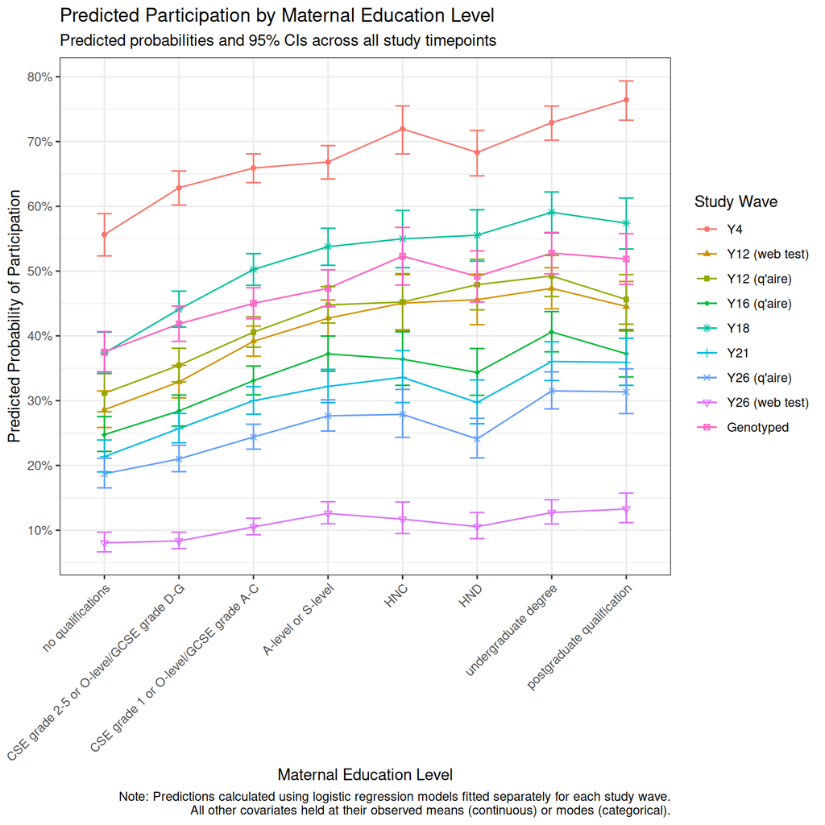

```r
# Calculate average predictions for maternal education variables

# Calculate predictions for all models

all_predictions = map_dfr(1:length(twinmodels), function(i) {
  data_grid = marginaleffects::datagrid(
    model = twinmodels[[i]],
    amohqual = unique
  )

  pred = predict(twinmodels[[i]], newdata = data_grid, type = "link", se.fit = TRUE)
  cbind.data.frame(
    data_grid,
    estimate = plogis(pred$fit),
    conf.low  = plogis(pred$fit - 1.96 * pred$se.fit),
    conf.high = plogis(pred$fit + 1.96 * pred$se.fit)
  ) %>%
    mutate(
      outcome = rq1y_twin_labels_clean_extrashort[i],
      amohqual = factor(amohqual, levels = levels(df$amohqual))
    )
})

# Plot all predictions together
all_predictions %>%
  mutate(
    outcome = factor(outcome, levels = rq1y_twin_labels_clean_extrashort)
  ) %>%
  ggplot(aes(x = amohqual, y = estimate, group = outcome, color = outcome, shape = outcome)) +
  geom_point() +
  geom_line() +
  geom_errorbar(aes(ymin = conf.low, ymax = conf.high), width = 0.2) +
  scale_shape_manual(values = c(16, 17, 15, 18, 8, 3, 4, 25, 7)) +
  scale_y_continuous(
    breaks = seq(0, 1, by = 0.1),
    labels = scales::percent_format(accuracy = 1)
  ) +
  theme_bw() +
  theme(axis.text.x = element_text(angle = 45, hjust = 1)) +
  labs(
    title = "Predicted Participation by Maternal Education Level",
    subtitle = "Predicted probabilities and 95% CIs across all study timepoints",
    x = "Maternal Education Level",
    y = "Predicted Probability of Participation",
    color = "Study Wave",
    shape = "Study Wave",
    caption = "Note: Predictions calculated using logistic regression models fitted separately for each study wave.\nAll other covariates held at their observed means (continuous) or modes (categorical)."
  )
```

## RQ1: Marginal Effects of Ethnicity on Participation

The plot below shows, for each study wave, the model-predicted probability of participation at each level of ethnic origin (with 95% CIs), holding all other predictors at their observed means/modes. This illustrates how strongly and consistently ethnicity predicts later participation across timepoints.

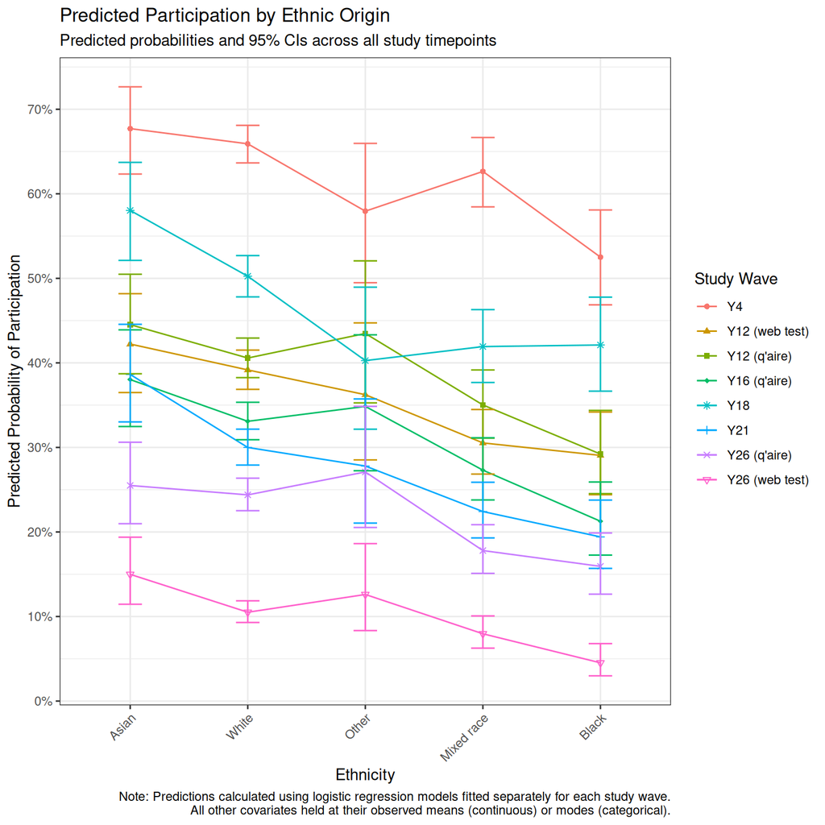

```r
# Calculate average predictions for ethnicity

# Calculate predictions for all models

all_predictions_ethnicity = map_dfr(1:(length(twinmodels)-1), function(i) {
  data_grid = marginaleffects::datagrid(
    model = twinmodels[[i]],
    aethnicc = unique
  )

  pred = predict(twinmodels[[i]], newdata = data_grid, type = "link", se.fit = TRUE)
  cbind.data.frame(
    data_grid,
    estimate = plogis(pred$fit),
    conf.low  = plogis(pred$fit - 1.96 * pred$se.fit),
    conf.high = plogis(pred$fit + 1.96 * pred$se.fit)
  ) %>%
    mutate(
      outcome = rq1y_twin_labels_clean_extrashort[i],
      aethnicc = factor(aethnicc, levels = levels(df$aethnicc))
    )
})

# Plot all predictions together
all_predictions_ethnicity %>%
  mutate(
    outcome = factor(outcome, levels = rq1y_twin_labels_clean_extrashort),
    aethnicc = factor(
      aethnicc,
      levels = c("Asian", "White", "Other", "Mixed race", "Black")
    )
  ) %>%
  ggplot(aes(x = aethnicc, y = estimate, group = outcome, color = outcome, shape = outcome)) +
  geom_point() +
  geom_line() +
  geom_errorbar(aes(ymin = conf.low, ymax = conf.high), width = 0.2) +
  scale_shape_manual(values = c(16, 17, 15, 18, 8, 3, 4, 25, 7)) +
  scale_y_continuous(
    breaks = seq(0, 1, by = 0.1),
    labels = scales::percent_format(accuracy = 1)
  ) +
  theme_bw() +
  theme(axis.text.x = element_text(angle = 45, hjust = 1)) +
  labs(
    title = "Predicted Participation by Ethnic Origin",
    subtitle = "Predicted probabilities and 95% CIs across all study timepoints",
    x = "Ethnicity",
    y = "Predicted Probability of Participation",
    color = "Study Wave",
    shape = "Study Wave",
    caption = "Note: Predictions calculated using logistic regression models fitted separately for each study wave.\nAll other covariates held at their observed means (continuous) or modes (categorical)."
  )
```

# Research Question 2: Effects of Attrition(ing)

## Toddlerhood Outcomes - Attritioned vs Original Estimates (Bias)

## Effect of attritioning on sample sizes

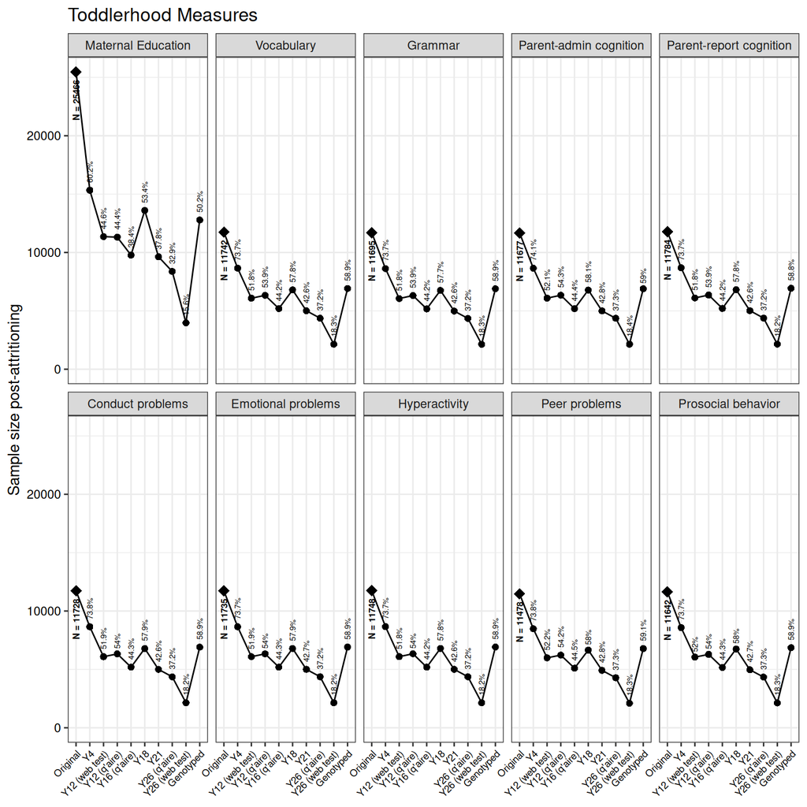

```r
response_statistics = df %>%
  select(randomtwinid, all_of(rq2y), all_of(rq1y_twin1)) %>%
  mutate(all1 = 1) %>%
  pivot_longer(cols = all_of(rq2y), names_to = "variable", values_to = "score") %>%
  pivot_longer(cols = all_of(c("all1", rq1y_twin1)), names_to = "timepoint", values_to = "participation_indicator") %>%
  filter(!is.na(score)) %>%
  filter(participation_indicator ==1)  %>%
  group_by(variable, timepoint) %>%
  summarise(
    n = dplyr::n(),
    .groups = "drop"
  ) %>%
  group_by(variable) %>%
  mutate(
    max = base::max(n),
    percent = n/max
  )

response_statistics %>%
  mutate(
    variable = rq2y_labels_short[match(variable, rq2y)],
    variable = factor(variable, levels = rq2y_labels_short),
    timepoint = rq1y_twin_labels_clean_extrashort[match(timepoint, rq1y_twin1)],
    timepoint = ifelse(is.na(timepoint), "Original", timepoint),
    timepoint = factor(timepoint, levels = c("Original", rq1y_twin_labels_clean_extrashort)),
    original  = factor(ifelse(timepoint == "Original", "Original", "Attritioned"))
  ) %>%
  ggplot(aes(x = timepoint, y = n, group = variable)) +
  geom_line() +
  geom_point(aes(shape = original, size = original)) +
  geom_text(
    data = ~ filter(.x, timepoint == "Original"),
    aes(label = paste0("N = ", as.character(n))),
    vjust = .5, hjust = 1.2, size = 2.2, angle = 90, fontface = "bold"
  ) +
  geom_text(
    data = ~ filter(.x, timepoint != "Original"),
    aes(label = paste0(round(percent * 100, digits = 1), "%")),
    vjust = .5, hjust = -.35, size = 1.9, angle = 90
  ) +
  scale_shape_manual(values = c("Original" = 18, "Attritioned" = 16)) +
  scale_size_manual(values = c("Original" = 3.5, "Attritioned" = 2)) +
  scale_y_continuous(limits = c(0, NA)) +
  labs(
    y = "Sample size post-attritioning",
    x = NULL
  ) +
  facet_wrap(~variable, nrow = 2) +
  theme_bw() +
  theme(
    axis.text   = element_text(color = "black"),
    axis.text.x = element_text(angle = 45, vjust = 1, hjust = 1, size = 7),
    legend.position = "none"
  ) +
  labs(
    title = "Toddlerhood Measures"
  )
```

```r
save_plot("2_attrition_numbers", width = 7.3, height = 4.3)
```

📊 View Full Resolution Attrition Numbers Plot (PNG)

### Sample Size Table

```r
response_statistics %>%
  mutate(
    variable = rq2y_labels_short[match(variable, rq2y)],
    variable = factor(variable, levels = rq2y_labels_short),
    timepoint = rq1y_twin_labels_clean_extrashort[match(timepoint, rq1y_twin1)],
    timepoint = ifelse(is.na(timepoint), "Original", timepoint),
    # Combine n and percent into formatted string
    n_pct = paste0(format(n, big.mark = ","), " (", sprintf("%.1f%%", percent * 100), ")")
  ) %>%
  select(variable, timepoint, n_pct) %>%
  pivot_wider(names_from = timepoint, values_from = n_pct) %>%
  arrange(variable) %>%
  gt() %>%
  cols_label(
    variable = "Variable"
  ) %>%
  tab_spanner(
    label = "Sample Size (% of Original) by Attrition Timepoint",
    columns = -variable
  ) %>%
  tab_style(
    style = cell_text(size = px(10)),
    locations = list(
      cells_body(),
      cells_stub(),
      cells_row_groups(),
      cells_column_labels(),
      cells_column_spanners(),
      cells_footnotes()
    )
  ) %>%
  tab_footnote(
    footnote = "Original = full sample before any attrition. Other columns show sample sizes (and percentage of original) after removing participants who did not take part at that timepoint.",
    placement = "right"
  ) %>%
  cols_move_to_start(columns = c(variable, Original))
```

| Sample Size (% of Original) by Attrition Timepoint Original | Sample Size (% of Original) by Attrition Timepoint Y4 | Sample Size (% of Original) by Attrition Timepoint Genotyped | Sample Size (% of Original) by Attrition Timepoint Y12 (q'aire) | Sample Size (% of Original) by Attrition Timepoint Y12 (web test) | Sample Size (% of Original) by Attrition Timepoint Y16 (q'aire) | Sample Size (% of Original) by Attrition Timepoint Y18 | Sample Size (% of Original) by Attrition Timepoint Y21 | Sample Size (% of Original) by Attrition Timepoint Y26 (web test) | Sample Size (% of Original) by Attrition Timepoint Y26 (q'aire) |
| --- | --- | --- | --- | --- | --- | --- | --- | --- | --- |
| Maternal Education |  |  |  |  |  |  |  |  |  |
| 25,466 (100.0%) | 15,334 (60.2%) | 12,783 (50.2%) | 11,310 (44.4%) | 11,359 (44.6%) | 9,772 (38.4%) | 13,600 (53.4%) | 9,631 (37.8%) | 3,970 (15.6%) | 8,375 (32.9%) |
| Vocabulary |  |  |  |  |  |  |  |  |  |
| 11,742 (100.0%) | 8,654 (73.7%) | 6,913 (58.9%) | 6,330 (53.9%) | 6,081 (51.8%) | 5,194 (44.2%) | 6,792 (57.8%) | 5,007 (42.6%) | 2,143 (18.3%) | 4,373 (37.2%) |
| Grammar |  |  |  |  |  |  |  |  |  |
| 11,695 (100.0%) | 8,620 (73.7%) | 6,891 (58.9%) | 6,309 (53.9%) | 6,055 (51.8%) | 5,167 (44.2%) | 6,749 (57.7%) | 4,983 (42.6%) | 2,136 (18.3%) | 4,352 (37.2%) |
| Parent-admin cognition |  |  |  |  |  |  |  |  |  |
| 11,677 (100.0%) | 8,654 (74.1%) | 6,893 (59.0%) | 6,337 (54.3%) | 6,088 (52.1%) | 5,183 (44.4%) | 6,782 (58.1%) | 4,994 (42.8%) | 2,145 (18.4%) | 4,361 (37.3%) |
| Parent-report cognition |  |  |  |  |  |  |  |  |  |
| 11,784 (100.0%) | 8,686 (73.7%) | 6,933 (58.8%) | 6,356 (53.9%) | 6,104 (51.8%) | 5,208 (44.2%) | 6,816 (57.8%) | 5,018 (42.6%) | 2,145 (18.2%) | 4,379 (37.2%) |
| Conduct problems |  |  |  |  |  |  |  |  |  |
| 11,728 (100.0%) | 8,650 (73.8%) | 6,907 (58.9%) | 6,330 (54.0%) | 6,086 (51.9%) | 5,191 (44.3%) | 6,787 (57.9%) | 5,001 (42.6%) | 2,137 (18.2%) | 4,364 (37.2%) |
| Emotional problems |  |  |  |  |  |  |  |  |  |
| 11,735 (100.0%) | 8,651 (73.7%) | 6,911 (58.9%) | 6,333 (54.0%) | 6,088 (51.9%) | 5,193 (44.3%) | 6,790 (57.9%) | 5,005 (42.7%) | 2,141 (18.2%) | 4,370 (37.2%) |
| Hyperactivity |  |  |  |  |  |  |  |  |  |
| 11,748 (100.0%) | 8,662 (73.7%) | 6,918 (58.9%) | 6,339 (54.0%) | 6,091 (51.8%) | 5,192 (44.2%) | 6,796 (57.8%) | 5,003 (42.6%) | 2,141 (18.2%) | 4,370 (37.2%) |
| Peer problems |  |  |  |  |  |  |  |  |  |
| 11,478 (100.0%) | 8,474 (73.8%) | 6,784 (59.1%) | 6,223 (54.2%) | 5,992 (52.2%) | 5,103 (44.5%) | 6,656 (58.0%) | 4,917 (42.8%) | 2,101 (18.3%) | 4,283 (37.3%) |
| Prosocial behavior |  |  |  |  |  |  |  |  |  |
| 11,642 (100.0%) | 8,577 (73.7%) | 6,859 (58.9%) | 6,286 (54.0%) | 6,049 (52.0%) | 5,160 (44.3%) | 6,749 (58.0%) | 4,968 (42.7%) | 2,126 (18.3%) | 4,340 (37.3%) |

Original = full sample before any attrition. Other columns show sample sizes (and percentage of original) after removing participants who did not take part at that timepoint.

## Toddlerhood Outcomes: Means, SMDs, and Variances

For each toddlerhood outcome, the table below compares the “original” (full) sample to the “attritioned” sample created by setting that outcome to missing for participants who did not take part in a given wave. Row groups correspond to each attritioned wave. Reported for each outcome are the raw mean difference, the standardized mean difference (SMD), and the percentage change in variance (attritioned relative to original), each with bootstrap 95% CIs and Bonferroni-Holm adjusted p-values; statistically significant increases are shaded red and decreases blue.

```r
variable_comparisons_df %>%
  select(-starts_with("."),-pd, -pval) %>%
  pivot_wider(
    names_from = "stat",
    values_from = c("y","ymin","ymax","pval_adj"),
    id_cols = c("variable", "dataset")
  ) %>%
  dplyr::rename( Outcome = "variable") %>%
  gt(groupname_col = "dataset") %>%
  tab_options(
    table.width = px(800)
    # table.border.top.style = "none",
    # table.border.bottom.style = "none",
    # column_labels.border.bottom.style = "solid",
    # column_labels.border.bottom.width = px(1),
    # column_labels.border.bottom.color = "black",
    # table_body.border.bottom.style = "none",
    # table_body.vlines.style = "none",
    # row_group.border.bottom.style = "none"
  ) %>%

  # Create column spanners (nested headers)
  tab_spanner(
    label = "Mean Difference",
    columns = c(y_md, ymin_md, ymax_md, pval_adj_md)
  ) %>%
  tab_spanner(
    label = "Standardized Mean Difference",
    columns = c(y_smd, ymin_smd, ymax_smd, pval_adj_smd)
  ) %>%
  tab_spanner(
    label = "Variance % Change",
    columns = c(y_var, ymin_var, ymax_var, pval_adj_var)
  ) %>%

  # Rename columns under each spanner
  cols_label(
    y_md = "Est", ymin_md = "LB", ymax_md = "UB", pval_adj_md = "p",
    y_smd = "Est", ymin_smd = "LB", ymax_smd = "UB", pval_adj_smd = "p",
    y_var = "Est", ymin_var = "LB", ymax_var = "UB", pval_adj_var = "p"
  ) %>%

  # Format numbers
  fmt(
    columns = !contains("var") & !contains("Outcome"),
    fns = function(x) {gbtoolbox::apa_num(x, n_decimal_places = 3)}
  ) %>%
  fmt(
    columns = "pval_adj_var",
    fns = function(x) {gbtoolbox::apa_num(x, n_decimal_places = 3)}
  ) %>%
  fmt_percent(
    columns = c("y_var", "ymin_var","ymax_var"),
    decimals = 2,
    drop_trailing_zeros = FALSE,
    drop_trailing_dec_mark = FALSE
  ) %>%
  # Styling - uniform font size
  tab_style(
    style = cell_text(size = px(10)),
    locations = cells_column_spanners()
  ) %>%
  tab_style(
    style = cell_text(size = px(10)),
    locations = cells_body()
  ) %>%
  tab_style(
    style = cell_text(size = px(10), align = "center"),
    locations = cells_row_groups()
  ) %>%
  tab_style(
    style = cell_text(size = px(10)),
    locations = cells_column_labels()
  ) %>%
  tab_style(
    style = cell_text(size = px(10)),
    locations = cells_footnotes()
  ) %>%

  # Highlight significant results - positive effects (light red)
  tab_style(
    style = cell_fill(color = "#ffd9d1"),  # Light red for positive effects
    locations = cells_body(
      columns = c(y_md, ymin_md, ymax_md, pval_adj_md),
      rows = pval_adj_md < 0.05 & y_md > 0
    )
  ) %>%
  tab_style(
    style = cell_fill(color = "#ffd9d1"),  # Light red for positive effects
    locations = cells_body(
      columns = c(y_smd, ymin_smd, ymax_smd, pval_adj_smd),
      rows = pval_adj_smd < 0.05 & y_smd > 0
    )
  ) %>%
  tab_style(
    style = cell_fill(color = "#ffd9d1"),  # Light red for positive effects
    locations = cells_body(
      columns = c(y_var, ymin_var, ymax_var, pval_adj_var),
      rows = pval_adj_var < 0.05 & y_var > 0
    )
  ) %>%

  # Highlight significant results - negative effects (light blue)
  tab_style(
    style = cell_fill(color = "#b6c3e0"),  # Light blue for negative effects
    locations = cells_body(
      columns = c(y_md, ymin_md, ymax_md, pval_adj_md),
      rows = pval_adj_md < 0.05 & y_md < 0
    )
  ) %>%
  tab_style(
    style = cell_fill(color = "#b6c3e0"),  # Light blue for negative effects
    locations = cells_body(
      columns = c(y_smd, ymin_smd, ymax_smd, pval_adj_smd),
      rows = pval_adj_smd < 0.05 & y_smd < 0
    )
  ) %>%
  tab_style(
    style = cell_fill(color = "#b6c3e0"),  # Light blue for negative effects
    locations = cells_body(
      columns = c(y_var, ymin_var, ymax_var, pval_adj_var),
      rows = pval_adj_var < 0.05 & y_var < 0
    )
  ) %>%

  # Add footnotes
  tab_footnote(
    footnote = md("<em>Note.</em> Est = Estimate, LB = Lower Bound 95% Confidence Interval, UB = Upper Bound 95% Confidence Interval. Significant (p<sub>Bonferroni-Holm</sub>) effects are highlighted in red (increases) or blue (decreases)."),
    # locations = cells_column_spanners(),
    placement = "right"
  ) %>%
  tab_footnote(
    footnote = "P values are Bonferroni-Holm adjusted within each participation group",
    locations = cells_column_labels(columns = contains("pval_adj")),
    placement = "right"
  ) %>%
  tab_footnote(
    footnote = md("Standardized mean difference = (Mean<sub>original</sub> - Mean<sub>attritioned</sub>) / SD<sub>original</sub>"),
    locations = cells_column_spanners(spanners = "Standardized Mean Difference"),
    placement = "right"
  ) %>%
    tab_footnote(
    footnote = md("Percentage change = (Var<sub>attritioned</sub> - Var<sub>original</sub>) / Var<sub>original</sub>"),
    locations = cells_column_spanners(spanners = "Variance % Change"),
    placement = "right"
  ) %>%
  opt_footnote_marks(marks = c("*", "†","‡"))
```

| Outcome | Mean Difference Est | Mean Difference LB | Mean Difference UB | Mean Difference p‡ | Standardized Mean Difference* Est | Standardized Mean Difference* LB | Standardized Mean Difference* UB | Standardized Mean Difference* p‡ | Variance % Change† Est | Variance % Change† LB | Variance % Change† UB | Variance % Change† p‡ |
| --- | --- | --- | --- | --- | --- | --- | --- | --- | --- | --- | --- | --- |
| Y4 |  |  |  |  |  |  |  |  |  |  |  |  |
| Maternal Education | .267 | .240 | .295 | .000 | .134 | .120 | .148 | .000 | 5.54% | 4.03% | 7.07% | .000 |
| Parent-admin cognition | -.018 | -.032 | -.004 | .059 | -.018 | -.032 | -.004 | .059 | −4.01% | −5.81% | −2.20% | .000 |
| Grammar | .008 | -.002 | .019 | .258 | .011 | -.003 | .025 | .258 | −0.06% | −1.16% | 1.04% | .910 |
| Parent-report cognition | .066 | .017 | .115 | .047 | .020 | .005 | .034 | .047 | −4.93% | −7.36% | −2.60% | .000 |
| Conduct problems | -.050 | -.070 | -.031 | .000 | -.034 | -.047 | -.021 | .000 | −4.40% | −6.49% | −2.36% | .000 |
| Emotional problems | -.007 | -.019 | .004 | .258 | -.008 | -.022 | .005 | .258 | −2.16% | −4.29% | −0.13% | .139 |
| Hyperactivity | -.034 | -.054 | -.013 | .006 | -.021 | -.033 | -.008 | .006 | −1.00% | −2.47% | 0.45% | .363 |
| Peer problems | -.024 | -.037 | -.012 | .002 | -.025 | -.038 | -.012 | .002 | −3.42% | −5.39% | −1.52% | .001 |
| Prosocial behavior | -.036 | -.067 | -.006 | .070 | -.016 | -.030 | -.003 | .070 | 1.47% | −0.19% | 3.09% | .235 |
| Vocabulary | .352 | -.027 | .734 | .212 | .014 | -.001 | .029 | .212 | −3.01% | −4.70% | −1.42% | .001 |
| Y12 (web test) |  |  |  |  |  |  |  |  |  |  |  |  |
| Maternal Education | .403 | .366 | .442 | .000 | .202 | .183 | .221 | .000 | 5.20% | 3.13% | 7.25% | .000 |
| Parent-admin cognition | -.035 | -.057 | -.013 | .008 | -.035 | -.057 | -.013 | .008 | −7.80% | −10.43% | −5.13% | .000 |
| Grammar | .024 | .007 | .042 | .026 | .032 | .009 | .054 | .026 | −0.21% | −1.98% | 1.60% | .824 |
| Parent-report cognition | .154 | .076 | .231 | .001 | .046 | .023 | .069 | .001 | −9.12% | −12.54% | −5.74% | .000 |
| Conduct problems | -.064 | -.093 | -.034 | .000 | -.043 | -.063 | -.023 | .000 | −5.09% | −8.18% | −1.98% | .009 |
| Emotional problems | .008 | -.009 | .025 | .724 | .009 | -.011 | .030 | .724 | −2.81% | −5.99% | 0.32% | .247 |
| Hyperactivity | -.051 | -.083 | -.019 | .011 | -.031 | -.050 | -.011 | .011 | −2.23% | −4.50% | 0.05% | .222 |
| Peer problems | -.044 | -.064 | -.025 | .000 | -.045 | -.065 | -.025 | .000 | −5.62% | −8.60% | −2.68% | .001 |
| Prosocial behavior | -.022 | -.071 | .026 | .724 | -.010 | -.032 | .012 | .724 | 1.22% | −1.53% | 3.89% | .748 |
| Vocabulary | .619 | .029 | 1.222 | .121 | .025 | .001 | .048 | .121 | −4.99% | −7.55% | −2.50% | .000 |
| Y12 (q'aire) |  |  |  |  |  |  |  |  |  |  |  |  |
| Maternal Education | .395 | .356 | .434 | .000 | .198 | .179 | .217 | .000 | 5.72% | 3.62% | 7.83% | .000 |
| Parent-admin cognition | -.029 | -.050 | -.007 | .050 | -.029 | -.051 | -.007 | .050 | −5.03% | −7.59% | −2.46% | .002 |
| Grammar | .019 | .002 | .036 | .110 | .024 | .003 | .046 | .110 | 0.39% | −1.28% | 2.11% | .719 |
| Parent-report cognition | .139 | .066 | .213 | .000 | .041 | .020 | .063 | .000 | −7.70% | −11.10% | −4.41% | .000 |
| Conduct problems | -.076 | -.105 | -.047 | .000 | -.051 | -.071 | -.032 | .000 | −5.04% | −8.04% | −2.05% | .006 |
| Emotional problems | .006 | -.011 | .023 | .975 | .007 | -.013 | .028 | .975 | −2.83% | −5.94% | 0.14% | .199 |
| Hyperactivity | -.041 | -.072 | -.009 | .050 | -.025 | -.043 | -.006 | .050 | −2.30% | −4.54% | −0.11% | .167 |

[output cut: 69 more lines]

## Effect of attrition on the variance of maternal education

Unlike the other outcomes, the variance of maternal education increased after attrition in our main analyses. The tables below show that this depends on how maternal education is coded.

In the original 8-level coding used in our main analyses, the higher qualifications are spread over a wide range of codes (A-levels = 4 to postgraduate = 8), far from the most common category (GCSE grades A–C = 3; see the maternal education distribution). Attrition mainly removed families with lower maternal education, so more of the remaining sample fell into these distant upper categories, increasing variance (e.g., by 10% in the Year 26 web test sample). However, this coding does not appear to reflect equal steps: child outcomes were similar for mothers with A-levels, HNC and HND qualifications (see descriptives). When these three categories are merged into a 6-level coding, variance instead decreased slightly in every attritioned sample (by 1–5%), consistent with the other outcomes.

When maternal education is dichotomised into degree vs. no degree, variance increased after attrition (e.g., by 32% in the Year 26 web test sample). This is expected for a binary variable: its variance, *p*(1 − *p*), increases as *p* moves towards .5, and the proportion of mothers with a degree rose from .18 in the full sample to .26 in the Year 26 web test sample.

### Original Coding

```r
entropy = function(x) {
  counts = table(x)
  p = as.numeric(counts) / sum(counts)
  p = p[p > 0]
  -sum(p * log2(p))
}

summary_stats = df %>%
  mutate(mat_edu = amohqualn1) %>%
  select(all_of(rq1y_twin1),mat_edu) %>%
  mutate(fullsample = 1) %>%
  pivot_longer(cols = !mat_edu) %>%
  group_by(name, value) %>%
  summarise(
    mean = mean(mat_edu, na.rm = TRUE),
    var  = sd(mat_edu, na.rm = TRUE)^2,
    entropy = entropy(mat_edu),
    n    = dplyr::n()
  ) %>%
  filter(value == 1)
summary_stats %>%
  mutate(
    name = rq1y_twin_labels_clean_extrashort[match(name, rq1y_twin1)],
    name = case_when(
      is.na(name) ~ "Full Sample",
      .default = name
    )
  ) %>%
  arrange(factor(name, levels = c("Full Sample", rq1y_twin_labels_clean_extrashort))) %>% # longitudinal order, full sample first
  ungroup() %>%
  select(-value) %>%
  gt() %>%
  fmt_number(
    decimals = 3,
    columns = !n
    )
```

| name | mean | var | entropy | n |
| --- | --- | --- | --- | --- |
| Full Sample | 3.729 | 3.974 | 2.588 | 25876 |
| Y4 | 3.996 | 4.195 | 2.600 | 15517 |
| Y12 (web test) | 4.132 | 4.181 | 2.602 | 11474 |
| Y12 (q'aire) | 4.124 | 4.202 | 2.609 | 11432 |
| Y16 (q'aire) | 4.185 | 4.242 | 2.601 | 9876 |
| Y18 | 4.120 | 4.192 | 2.600 | 13736 |
| Y21 | 4.182 | 4.288 | 2.602 | 9730 |
| Y26 (q'aire) | 4.148 | 4.284 | 2.607 | 8456 |
| Y26 (web test) | 4.281 | 4.354 | 2.615 | 4008 |
| Genotyped | 3.941 | 4.090 | 2.595 | 12912 |

### Combining HNC and HND with A-levels

HNC and HND qualifications are vocational and sit ambiguously between A-levels and undergraduate degrees in the original ordinal coding. Here they are collapsed into the A-level category to create a cleaner 6-level ordinal scale. The table shows the mean, variance, and entropy of the recoded maternal education variable for participants at each study timepoint and for the full sample. Higher entropy indicates a more evenly distributed education profile among participants; a decline in entropy relative to the full sample would indicate that attrition is concentrating the sample toward certain education levels.

```r
# table(df$amohqualn1,  df$amohqual)

df3 = df %>%
  mutate(
    mat_edu = case_when(
      .default = amohqualn1,
      amohqualn1 == 5 ~ 4,  # HNC -> A level
      amohqualn1 == 6 ~ 4,  # HND -> A level
      amohqualn1 == 7 ~ 5,  # undergraduate degree
      amohqualn1 == 8 ~ 6   # postgraduate qualification
    )
  ) %>%
  select(all_of(rq1y_twin1),mat_edu)

summary_stats = df3 %>%
  mutate(fullsample = 1) %>%
  pivot_longer(cols = !mat_edu) %>%
  group_by(name, value) %>%
  summarise(
    mean = mean(mat_edu, na.rm = TRUE),
    var  = sd(mat_edu, na.rm = TRUE)^2,
    entropy = entropy(mat_edu),
    n    = dplyr::n()
  ) %>%
  filter(value == 1)
summary_stats %>%
  mutate(
    name = rq1y_twin_labels_clean_extrashort[match(name, rq1y_twin1)],
    name = case_when(
      is.na(name) ~ "Full Sample",
      .default = name
    )
  ) %>%
  arrange(factor(name, levels = c("Full Sample", rq1y_twin_labels_clean_extrashort))) %>% # longitudinal order, full sample first
  ungroup() %>%
  select(-value) %>%
  gt() %>%
  fmt_number(
    decimals = 3,
    columns = !n
    )
```

| name | mean | var | entropy | n |
| --- | --- | --- | --- | --- |
| Full Sample | 3.270 | 1.672 | 2.341 | 25876 |
| Y4 | 3.451 | 1.657 | 2.336 | 15517 |
| Y12 (web test) | 3.542 | 1.594 | 2.316 | 11474 |
| Y12 (q'aire) | 3.535 | 1.610 | 2.325 | 11432 |
| Y16 (q'aire) | 3.579 | 1.609 | 2.323 | 9876 |
| Y18 | 3.535 | 1.605 | 2.320 | 13736 |
| Y21 | 3.576 | 1.632 | 2.328 | 9730 |
| Y26 (q'aire) | 3.554 | 1.649 | 2.337 | 8456 |
| Y26 (web test) | 3.645 | 1.645 | 2.334 | 4008 |
| Genotyped | 3.416 | 1.628 | 2.329 | 12912 |

```r
table(df$amohqualn1, df3$mat_edu)
```

```
       1    2    3    4    5    6
  1 2396    0    0    0    0    0
  2    0 3978    0    0    0    0
  3    0    0 9508    0    0    0
  4    0    0    0 3386    0    0
  5    0    0    0  712    0    0
  6    0    0    0  968    0    0
  7    0    0    0    0 2968    0
  8    0    0    0    0    0 1550
```

### Dichotomising education into degree vs. no degree

Here maternal education is reduced to a binary variable: whether or not the mother holds an undergraduate or postgraduate degree. This is a common simplification in the literature and avoids assumptions about the spacing of the ordinal scale. The table shows the proportion of mothers with a degree (mean), variance, and entropy among participants at each timepoint and in the full sample. A rising proportion of degree-educated mothers across timepoints would indicate that attrition disproportionately removes families from lower education backgrounds.

```r
df4 = df %>%
  mutate(
    mat_edu_degree = case_when(
      amohqualn1 >= 7 ~ 1L,  # undergraduate degree or above
      amohqualn1 <  7 ~ 0L,
      .default = NA_integer_
    )
  ) %>%
  select(all_of(rq1y_twin1), mat_edu_degree)

summary_stats_degree = df4 %>%
  mutate(fullsample = 1) %>%
  pivot_longer(cols = !mat_edu_degree) %>%
  group_by(name, value) %>%
  summarise(
    mean    = mean(mat_edu_degree, na.rm = TRUE),
    var     = sd(mat_edu_degree, na.rm = TRUE)^2,
    entropy = entropy(mat_edu_degree),
    n       = dplyr::n()
  ) %>%
  filter(value == 1)
summary_stats_degree %>%
  mutate(
    name = rq1y_twin_labels_clean_extrashort[match(name, rq1y_twin1)],
    name = case_when(
      is.na(name) ~ "Full Sample",
      .default = name
    )
  ) %>%
  arrange(factor(name, levels = c("Full Sample", rq1y_twin_labels_clean_extrashort))) %>% # longitudinal order, full sample first
  ungroup() %>%
  select(-value) %>%
  gt() %>%
  fmt_number(
    decimals = 3,
    columns = !n
  )
```

| name | mean | var | entropy | n |
| --- | --- | --- | --- | --- |
| Full Sample | 0.177 | 0.146 | 0.674 | 25876 |
| Y4 | 0.217 | 0.170 | 0.755 | 15517 |
| Y12 (web test) | 0.233 | 0.179 | 0.784 | 11474 |
| Y12 (q'aire) | 0.233 | 0.179 | 0.784 | 11432 |
| Y16 (q'aire) | 0.245 | 0.185 | 0.804 | 9876 |
| Y18 | 0.232 | 0.178 | 0.782 | 13736 |
| Y21 | 0.246 | 0.186 | 0.806 | 9730 |
| Y26 (q'aire) | 0.242 | 0.183 | 0.798 | 8456 |
| Y26 (web test) | 0.261 | 0.193 | 0.829 | 4008 |
| Genotyped | 0.206 | 0.164 | 0.735 | 12912 |

```r
table(df$amohqualn1, df4$mat_edu_degree)
```

```
       0    1
  1 2396    0
  2 3978    0
  3 9508    0
  4 3386    0
  5  712    0
  6  968    0
  7    0 2968
  8    0 1550
```

## Plot changes in correlations

Each panel shows, for one attrition time point, the change in the correlation between each pair of toddlerhood variables (r<sub>attritioned</sub> − r<sub>original</sub>), estimated with the clustered bootstrap. Every cell shows the estimated change.

- **Colour:** cells are coloured only where the change is significant before correction for multiple comparisons (p<sub>unadj</sub> < .05): red for increases and blue for decreases, with darker shades for larger changes (the scale is capped at ±.08). Cells with non-significant changes are white.
- **Text:** changes that stay significant after Bonferroni-Holm correction (p<sub>Holm</sub> < .05, corrected across the 45 correlations within each attrition time point) are shown in larger bold black text. All other changes are shown in small grey text.

A coloured cell with small grey text is therefore significant only before correction.

```r
# Get original column order before pivot
cor_col_order = setdiff(names(cor_df), c(".dataset", ".boot"))

correlation_comparisons_df = cor_df %>%
  pivot_longer(
    cols = !starts_with(".")
  ) %>%
  mutate(
    name = factor(name, levels = cor_col_order)
  ) %>%
  group_by(.dataset, name) %>%
  summarise(
    .mean_qi_pd(value),
    .groups = "drop"
  ) %>%
  group_by(.dataset) %>%
  mutate(
    pval_adj = stats::p.adjust(pval, method = "holm")
  ) %>%
  ungroup() %>%
  mutate(
    x_var = x_var[match(name, cor_col_order)],
    y_var = y_var[match(name, cor_col_order)]
  ) %>%
  arrange(.dataset, name)

correlation_comparisons = split(correlation_comparisons_df, correlation_comparisons_df$.dataset)
correlation_comparisons = lapply(correlation_comparisons, function(x) select(x, -.dataset))
names(correlation_comparisons) = rq1y_twin1[as.numeric(names(correlation_comparisons))]

## Heatmap in the same format as manuscript Fig. 4 (14_pgs_B_results.qmd):
## every cell shows its change in correlation; cells are coloured only where
## p_unadj < .05 (white otherwise); Holm-significant changes (p_Holm < .05,
## corrected across the 45 correlations within each attrition time point) are
## shown in larger bold black text, others in small grey text.
rq2_cor_changes = correlation_comparisons_df %>%
  mutate(
    wave_label = factor(rq1y_twin_labels_clean_extrashort[.dataset],
                        levels = rq1y_twin_labels_clean_extrashort),
    position_1 = match(x_var, rq2y),
    position_2 = match(y_var, rq2y),
    # Variable that comes first in rq2y goes on the x axis, the other on the y axis (lower triangle)
    x_label    = factor(rq2y_labels_short[pmin(position_1, position_2)], levels = rq2y_labels_short),
    y_label    = factor(rq2y_labels_short[pmax(position_1, position_2)], levels = rev(rq2y_labels_short)),
    cell_label = gsub("^(-?)0\\.", "\\1.", sprintf("%.2f", round(y, 2) + 0)),  # e.g. -.07; + 0 turns -0 into 0 so no "-.00"
    fill_value = ifelse(pval < 0.05, y, 0)
  )

testthat::test_that("45 correlation changes per time point, all in the lower triangle", {
  testthat::expect_equal(nrow(rq2_cor_changes), 45 * length(rq1y_twin1))
  testthat::expect_false(anyNA(rq2_cor_changes$x_label))
  testthat::expect_false(anyNA(rq2_cor_changes$wave_label))
  testthat::expect_true(all(rq2_cor_changes$position_1 != rq2_cor_changes$position_2))
})
```

```
Test passed 🌈
```

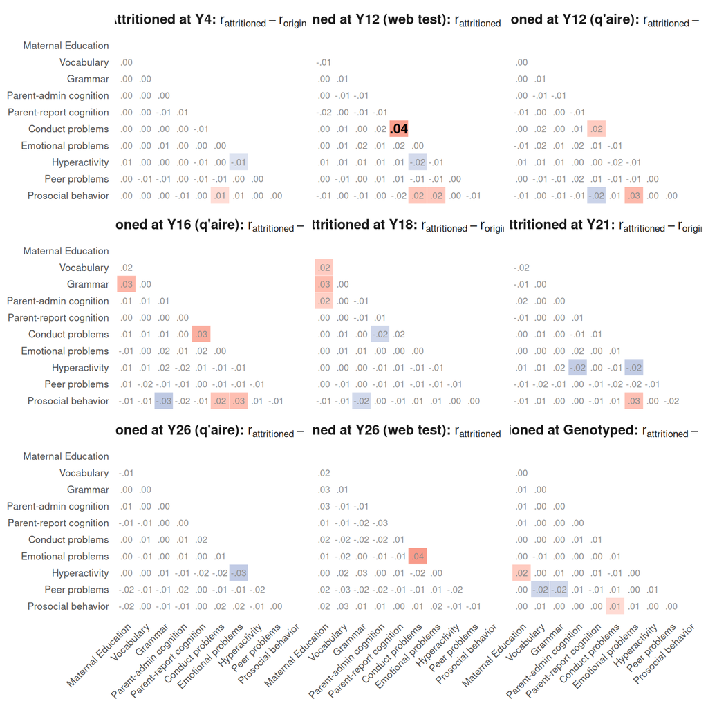

```r
ggplot(rq2_cor_changes, aes(x = x_label, y = y_label, fill = fill_value)) +
  geom_tile(colour = "white") +
  # Non-significant changes: small grey text; Holm-significant changes: larger bold black text
  geom_text(data = ~ filter(.x, pval_adj >= 0.05), aes(label = cell_label), size = 2.6, colour = "grey55") +
  geom_text(data = ~ filter(.x, pval_adj <  0.05), aes(label = cell_label), size = 3.8, fontface = "bold", colour = "black") +
  facet_wrap(~ wave_label, ncol = 3, dir = "h",
             labeller = function(labels) {
               list(lapply(as.character(labels$wave_label), function(w) {
                 as.expression(bquote(bold(.(paste0("Attritioned at ", w, ":"))) ~
                                        r[attritioned] - r[original]))
               }))
             }) +
  scale_x_discrete(drop = FALSE) +
  scale_y_discrete(drop = FALSE) +
  scale_fill_gradient2(low = "#2166ac", mid = "white", high = "#d73027", midpoint = 0,
                       limits = c(-0.08, 0.08), oob = scales::squish) +
  labs(x = NULL, y = NULL) +
  theme_minimal() +
  theme(
    axis.text.x     = element_text(angle = 45, hjust = 1, size = 8),
    axis.text.y     = element_text(size = 8),
    panel.grid      = element_blank(),
    strip.text      = element_text(size = 11),
    legend.position = "none"
  )
```

```r
save_plot(
  "2_rq2_2_correlations", width = 14, height = 14)
```

📊 View Full Resolution Correlation Plots (PNG)

## Toddlerhood Outcomes: Correlations

Below is a results table for the change in correlations. For every pair of toddlerhood outcomes, we compare the correlation in the attritioned sample to the correlation in the original sample (row groups = attrition timepoint), reporting the difference with bootstrap 95% CIs and unadjusted/Bonferroni-Holm adjusted p-values; significant increases are shaded green and decreases red.

```r
cor_table = bind_rows(correlation_comparisons, .id = "timepoint") %>%
  mutate(
    dataset = rq1y_twin_labels_clean_extrashort[match(timepoint, rq1y_twin1)],
    x_var_label = rq2y_labels_short[match(x_var, rq2y)],
    y_var_label = rq2y_labels_short[match(y_var, rq2y)],
    pair = paste(x_var_label, "×", y_var_label)
  ) %>%
  select(dataset, pair, y, ymin, ymax, pval, pval_adj) %>%
  filter(!is.na(dataset)) %>%
  gt(groupname_col = "dataset") %>%
  # tab_options(
  #   table.width = px(800)
  # ) %>%

  # Rename columns
  cols_label(
    pair = "Variable Pair",
    y = "Est",
    ymin = "LB",
    ymax = "UB",
    pval = md("p<sub>unadj</sub>"),
    pval_adj = md("p<sub>adj</sub>")
  ) %>%

  # Create column spanner
  tab_spanner(
    label = md("Correlation difference = Cor<sub>attritioned</sub> - Cor<sub>original</sub>"),
    columns = c(y, ymin, ymax, pval, pval_adj)
  ) %>%

  # Format numbers
  fmt(
    columns = c(y, ymin, ymax),
    fns = function(x) {gbtoolbox::apa_num(x, n_decimal_places = 3)}
  ) %>%
  fmt(
    columns = c(pval, pval_adj),
    fns = function(x) {gbtoolbox::apa_num(x, n_decimal_places = 3)}
  ) %>%

  # Styling - uniform font size
  tab_style(
    style = cell_text(size = px(10)),
    locations = cells_column_spanners()
  ) %>%
  tab_style(
    style = cell_text(size = px(10)),
    locations = cells_body()
  ) %>%
  tab_style(
    style = cell_text(size = px(10), align = "center"),
    locations = cells_row_groups()
  ) %>%
  tab_style(
    style = cell_text(size = px(10)),
    locations = cells_column_labels()
  ) %>%
  tab_style(
    style = cell_text(size = px(10)),
    locations = cells_footnotes()
  ) %>%

  # Highlight significant results - positive effects (light green)
  tab_style(
    style = cell_fill(color = "#d5e8d4"),
    locations = cells_body(
      columns = c(pair, y, ymin, ymax, pval, pval_adj),
      rows = pval_adj < 0.05 & y > 0
    )
  ) %>%

  # Highlight significant results - negative effects (light red)
  tab_style(
    style = cell_fill(color = "#f8cecc"),
    locations = cells_body(
      columns = c(pair, y, ymin, ymax, pval, pval_adj),
      rows = pval_adj < 0.05 & y < 0
    )
  ) %>%

  # Add footnotes
  tab_footnote(
    footnote = md("<em>Note.</em> Est = Estimate, LB = Lower Bound 95% Confidence Interval, UB = Upper Bound 95% Confidence Interval. Significant (p<sub>Bonferroni-Holm</sub>) effects are highlighted in green (increases) or red (decreases)."),
    placement = "right"
  ) %>%
  tab_footnote(
    footnote = "P values are Bonferroni-Holm adjusted within each attrition timepoint",
    locations = cells_column_labels(columns = pval_adj),
    placement = "right"
  ) %>%
  opt_footnote_marks(marks = c("*", "†", "‡"))

cor_table
```

| Variable Pair | Correlation difference = Cor<sub>attritioned</sub> - Cor<sub>original</sub> Est | Correlation difference = Cor<sub>attritioned</sub> - Cor<sub>original</sub> LB | Correlation difference = Cor<sub>attritioned</sub> - Cor<sub>original</sub> UB | Correlation difference = Cor<sub>attritioned</sub> - Cor<sub>original</sub> p<sub>unadj</sub> | Correlation difference = Cor<sub>attritioned</sub> - Cor<sub>original</sub> p<sub>adj</sub>* |
| --- | --- | --- | --- | --- | --- |
| Y4 |  |  |  |  |  |
| Vocabulary × Maternal Education | -.001 | -.015 | .014 | .927 | 1.000 |
| Grammar × Maternal Education | -.001 | -.014 | .012 | .913 | 1.000 |
| Parent-admin cognition × Maternal Education | .004 | -.009 | .017 | .573 | 1.000 |
| Parent-report cognition × Maternal Education | .002 | -.012 | .015 | .817 | 1.000 |
| Conduct problems × Maternal Education | -.002 | -.015 | .010 | .699 | 1.000 |
| Emotional problems × Maternal Education | -.005 | -.017 | .008 | .483 | 1.000 |
| Hyperactivity × Maternal Education | .006 | -.006 | .017 | .332 | 1.000 |
| Peer problems × Maternal Education | -.002 | -.015 | .010 | .723 | 1.000 |
| Prosocial behavior × Maternal Education | -.003 | -.016 | .010 | .609 | 1.000 |
| Grammar × Vocabulary | .001 | -.007 | .009 | .803 | 1.000 |
| Parent-admin cognition × Vocabulary | .002 | -.011 | .015 | .799 | 1.000 |
| Parent-report cognition × Vocabulary | -.002 | -.015 | .012 | .809 | 1.000 |
| Conduct problems × Vocabulary | -.003 | -.018 | .010 | .636 | 1.000 |
| Emotional problems × Vocabulary | .005 | -.009 | .019 | .511 | 1.000 |
| Hyperactivity × Vocabulary | -.001 | -.014 | .012 | .906 | 1.000 |
| Peer problems × Vocabulary | -.011 | -.025 | .003 | .133 | 1.000 |
| Prosocial behavior × Vocabulary | -.004 | -.017 | .009 | .545 | 1.000 |
| Parent-admin cognition × Grammar | -.005 | -.018 | .008 | .484 | 1.000 |
| Parent-report cognition × Grammar | -.008 | -.020 | .005 | .245 | 1.000 |
| Conduct problems × Grammar | -.004 | -.017 | .009 | .592 | 1.000 |
| Emotional problems × Grammar | .007 | -.006 | .019 | .327 | 1.000 |
| Hyperactivity × Grammar | -.003 | -.015 | .010 | .676 | 1.000 |
| Peer problems × Grammar | -.008 | -.020 | .005 | .254 | 1.000 |
| Prosocial behavior × Grammar | -.001 | -.014 | .011 | .833 | 1.000 |
| Parent-report cognition × Parent-admin cognition | .007 | -.006 | .020 | .267 | 1.000 |
| Conduct problems × Parent-admin cognition | -.002 | -.015 | .011 | .776 | 1.000 |
| Emotional problems × Parent-admin cognition | .003 | -.011 | .016 | .692 | 1.000 |
| Hyperactivity × Parent-admin cognition | -.004 | -.016 | .009 | .534 | 1.000 |
| Peer problems × Parent-admin cognition | -.002 | -.015 | .012 | .792 | 1.000 |

[output cut: 386 more lines]

## Toddlerhood Outcomes: ACE Estimates and Differences

```r
bootstrap_summary_df_ace %>%
  filter(par %in% c("a","c","e")) %>%
  group_by(dataset_label) %>%
  mutate(
    pval = stats::p.adjust(pval, method = "holm"),
  ) %>%
  ungroup() %>%
  select(-starts_with("."), -n, -pd) %>%
  mutate(name_clean = rq2y_labels_short[match(name, rq2y)]) %>%
  pivot_wider(
    id_cols = c(par, name_clean, sex, dataset_label),
    names_from = group,
    values_from = c(y, ymin, ymax, pval),
    names_sep = "_"
  ) %>%
  select(-ymin_Original, -ymax_Original, -ymin_Attritioned, -ymax_Attritioned, -pval_Original, -pval_Attritioned) %>%
  select(dataset_label, name_clean, par, y_Original, y_Attritioned, y_Difference, ymin_Difference, ymax_Difference, pval_Difference, sex) %>%
  mutate(
    name_clean    = factor(name_clean,    levels = rq2y_labels_short),
    dataset_label = factor(dataset_label, levels = rq1y_twin_labels_clean_extrashort)
    ) %>%
  arrange(sex, dataset_label, name_clean, par) %>%
  mutate(par = toupper(par)) %>%
  gt(groupname_col = "sex") %>%
  fmt_number(decimals = 3) %>%
  tab_row_group(
    label = "Male",
    rows = sex == "male"
  ) %>%
  tab_row_group(
    label = "Female",
    rows = sex == "female"
  ) %>%
  cols_hide(sex) %>%
  cols_label(
    dataset_label = "Timepoint",
    name_clean = "Variable",
    par = "",
    y_Original = "Original",
    y_Attritioned = "Attritioned",
    y_Difference = "Diff",
    ymin_Difference = "Lower",
    ymax_Difference = "Upper",
    pval_Difference = "p"
  ) %>%
  tab_spanner(
    label = "95% CI",
    columns = c(ymin_Difference, ymax_Difference)
  ) %>%
  tab_spanner(
    label = "Estimates",
    columns = c(y_Attritioned, y_Original)
  ) %>%
  tab_style(
    style = cell_fill(color = "lightgreen"),
    locations = cells_body(
      columns = everything(),
      rows = pval_Difference < 0.05
    )
  ) %>%
  tab_footnote(
    footnote = "P values are Bonferroni-Holm adjusted within each sex, parameter (A, C or E), and timepoint group",
    locations = cells_column_labels(columns = pval_Difference)
  )
```

| Timepoint | Variable |  | Estimates Attritioned | Estimates Original | Diff | 95% CI Lower | 95% CI Upper | p<sup>1</sup> |  |
| --- | --- | --- | --- | --- | --- | --- | --- | --- | --- |
| Female |  |  |  |  |  |  |  |  |  |
| Y4 | Vocabulary | A | 0.118 | 0.130 | −0.012 | −0.055 | 0.026 |  | 1.000 |
| Y4 | Vocabulary | C | 0.817 | 0.809 | 0.008 | −0.026 | 0.049 | 1.000 |  |
| Y4 | Vocabulary | E | 0.065 | 0.061 | 0.004 | −0.006 | 0.013 | 1.000 |  |
| Y4 | Grammar | A | 0.346 | 0.328 | 0.017 | −0.046 | 0.079 | 1.000 |  |
| Y4 | Grammar | C | 0.512 | 0.526 | −0.014 | −0.069 | 0.042 | 1.000 |  |
| Y4 | Grammar | E | 0.142 | 0.145 | −0.003 | −0.020 | 0.013 | 1.000 |  |
| Y4 | Parent-admin cognition | A | 0.191 | 0.220 | −0.029 | −0.098 | 0.039 | 1.000 |  |
| Y4 | Parent-admin cognition | C | 0.510 | 0.504 | 0.006 | −0.054 | 0.069 | 1.000 |  |
| Y4 | Parent-admin cognition | E | 0.298 | 0.276 | 0.023 | 0.003 | 0.042 | 1.000 |  |
| Y4 | Parent-report cognition | A | 0.071 | 0.136 | −0.065 | −0.175 | 0.025 | 1.000 |  |
| Y4 | Parent-report cognition | C | 0.720 | 0.665 | 0.055 | −0.022 | 0.154 | 1.000 |  |
| Y4 | Parent-report cognition | E | 0.209 | 0.199 | 0.010 | −0.017 | 0.035 | 1.000 |  |
| Y4 | Conduct problems | A | 0.357 | 0.455 | −0.099 | −0.216 | 0.011 | 1.000 |  |
| Y4 | Conduct problems | C | 0.125 | 0.045 | 0.080 | 0.000 | 0.177 | 1.000 |  |
| Y4 | Conduct problems | E | 0.518 | 0.500 | 0.019 | −0.020 | 0.055 | 1.000 |  |
| Y4 | Emotional problems | A | 0.550 | 0.528 | 0.022 | −0.055 | 0.117 | 1.000 |  |
| Y4 | Emotional problems | C | 0.032 | 0.062 | −0.030 | −0.110 | 0.034 | 1.000 |  |
| Y4 | Emotional problems | E | 0.418 | 0.410 | 0.008 | −0.025 | 0.040 | 1.000 |  |
| Y4 | Hyperactivity | A | 0.616 | 0.625 | −0.009 | −0.038 | 0.022 | 1.000 |  |
| Y4 | Hyperactivity | C | 0.000 | 0.000 | 0.000 | 0.000 | 0.000 | 1.000 |  |
| Y4 | Hyperactivity | E | 0.384 | 0.375 | 0.009 | −0.022 | 0.038 | 1.000 |  |
| Y4 | Peer problems | A | 0.519 | 0.520 | −0.001 | −0.041 | 0.033 | 1.000 |  |
| Y4 | Peer problems | C | 0.002 | 0.001 | 0.001 | 0.000 | 0.024 | 1.000 |  |
| Y4 | Peer problems | E | 0.479 | 0.480 | 0.000 | −0.032 | 0.032 | 1.000 |  |
| Y4 | Prosocial behavior | A | 0.341 | 0.329 | 0.012 | −0.072 | 0.096 | 1.000 |  |
| Y4 | Prosocial behavior | C | 0.406 | 0.402 | 0.004 | −0.067 | 0.078 | 1.000 |  |
| Y4 | Prosocial behavior | E | 0.253 | 0.269 | −0.016 | −0.043 | 0.008 | 1.000 |  |
| Y12 (web test) | Vocabulary | A | 0.154 | 0.130 | 0.025 | −0.037 | 0.085 | 1.000 |  |
| Y12 (web test) | Vocabulary | C | 0.808 | 0.809 | −0.001 | −0.054 | 0.054 | 1.000 |  |

[output cut: 459 more lines]

## Adolescent Outcomes and Polygenic Scores - Attritioned vs Original Estimates (Bias)

### Sample sizes

Number of twins with data on each adolescent outcome and with PGS, in the original sample and in each attritioned sample (percentage of the original sample in brackets). All 12 PGS are available for the same twins, so they are shown as a single row.

```r
## Per-variable sample sizes, recomputed from the original dataset saved by
## 14_pgs_B_run_bootstrap_attrition.R, using the same attritioning rule: a
## twin's data are removed only if the participation indicator is 0 (NA is kept)
participation = df %>%
  select(randomfamid, twin, all_of(setdiff(waves, "hasgeno1")))

ss_data = b_results$original_dataset %>%
  left_join(participation, by = c("randomfamid", "twin")) %>%
  mutate(hasgeno1 = as.integer(!is.na(pgs_ea1)))                                # as in the bootstrap script: Genotyped = has PGS

testthat::test_that("Participation join keeps one row per twin and all PGS are available for the same twins", {
  testthat::expect_equal(nrow(ss_data), nrow(b_results$original_dataset))
  testthat::expect_true(all(rowSums(!is.na(ss_data[pgs_vars1])) %in% c(0, length(pgs_vars1))))
})
```

```
Test passed 😀
```

```r
ss_long = ss_data %>%
  mutate(pgs_any = pgs_ea1) %>%
  select(all_of(c(rq6y, "pgs_any", waves))) %>%
  pivot_longer(all_of(c(rq6y, "pgs_any")), names_to = "variable", values_to = "score") %>%
  filter(!is.na(score))

sample_sizes_var = bind_rows(
  ss_long %>% count(variable) %>% mutate(timepoint = "Original"),
  lapply(seq_along(waves), function(w) {
    ss_long %>%
      filter(!(as.numeric(.data[[waves[w]]]) %in% 0)) %>%
      count(variable) %>%
      mutate(timepoint = waves_labels[w])
  })
) %>%
  group_by(variable) %>%
  mutate(percent = 100 * n / n[timepoint == "Original"]) %>%
  ungroup()

## Check against the totals saved by the bootstrap script
testthat::test_that("PGS sample sizes match 14_pgs_B_sample_sizes.Rds", {
  pgs_n = sample_sizes_var %>% filter(variable == "pgs_any", timepoint != "Original")
  testthat::expect_equal(pgs_n$n[match(sample_sizes$participation_label, pgs_n$timepoint)], sample_sizes$n_twins_attritioned)
})
```

```
Test passed 🥳
```

```r
sample_sizes_var %>%
  mutate(
    variable  = ifelse(variable == "pgs_any", "PGS (all 12)", rq6y_labels[match(variable, rq6y)]),
    variable  = factor(variable, levels = c(outcome_order, "PGS (all 12)")),
    timepoint = factor(timepoint, levels = c("Original", waves_labels)),
    n_pct     = ifelse(timepoint == "Original",
                       format(n, big.mark = ","),
                       paste0(format(n, big.mark = ","), " (", sprintf("%.1f%%", percent), ")"))
  ) %>%
  arrange(variable, timepoint) %>%
  select(variable, timepoint, n_pct) %>%
  pivot_wider(names_from = timepoint, values_from = n_pct) %>%
  gt() %>%
  cols_label(variable = "Variable") %>%
  tab_spanner(label = "Sample size (% of original) by attrition time point", columns = -c(variable, Original)) %>%
  tab_footnote(
    footnote = "Original = full sample before attritioning (outcomes: all ethnic origins; PGS: genotyped twins of White ethnic origin). Other columns show sample sizes after removing twins who did not take part at that time point. Attritioning on genotyping removes only twins without PGS, so PGS sample sizes are unchanged at that time point.",
    placement = "right"
  )
```

| Variable | Original | Sample size (% of original) by attrition time point Y18 | Sample size (% of original) by attrition time point Y21 | Sample size (% of original) by attrition time point Y26 (q'aire) | Sample size (% of original) by attrition time point Y26 (web test) | Sample size (% of original) by attrition time point Genotyped |
| --- | --- | --- | --- | --- | --- | --- |
| Y12: Externalising (SDQ) | 11,358 | 9,068 (79.8%) | 7,005 (61.7%) | 5,892 (51.9%) | 2,932 (25.8%) | 8,621 (75.9%) |
| Y12: Depression (MFQ) | 11,401 | 9,099 (79.8%) | 7,022 (61.6%) | 5,904 (51.8%) | 2,941 (25.8%) | 8,650 (75.9%) |
| Y12: Cognitive ability | 8,444 | 7,108 (84.2%) | 5,705 (67.6%) | 4,819 (57.1%) | 2,481 (29.4%) | 6,564 (77.7%) |
| Y16: GCSE grade | 12,942 | 10,656 (82.3%) | 7,924 (61.2%) | 6,683 (51.6%) | 3,315 (25.6%) | 9,202 (71.1%) |
| PGS (all 12) | 12,912 | 9,508 (73.6%) | 7,344 (56.9%) | 6,280 (48.6%) | 3,054 (23.7%) | 12,912 (100.0%) |

Original = full sample before attritioning (outcomes: all ethnic origins; PGS: genotyped twins of White ethnic origin). Other columns show sample sizes after removing twins who did not take part at that time point. Attritioning on genotyping removes only twins without PGS, so PGS sample sizes are unchanged at that time point.

### Table: standardised mean differences and variance changes

For each PGS and outcome, the table shows the standardised mean difference (SMD) and percentage change in variance between the attritioned and original samples, with bootstrap 95% CIs. P values are Bonferroni-Holm adjusted across the 16 variables within each attrition time point and statistic (as for the toddlerhood variables in RQ2). Increases are shaded red and decreases blue (as in the plots): a darker shade marks effects significant after Holm correction (p<sub>Holm</sub> < .05), and a very light shade marks effects significant only before correction (p<sub>unadj</sub> < .05, p<sub>Holm</sub> ≥ .05).

```r
b_main %>%
  filter(stat %in% c("smd", "var")) %>%
  select(wave_label, variable_label, stat, estimate, ci_low, ci_high, pval, pval_adj) %>%
  pivot_wider(
    names_from  = stat,
    values_from = c(estimate, ci_low, ci_high, pval, pval_adj)
  ) %>%
  mutate(variable_label = factor(variable_label, levels = variable_order)) %>%
  arrange(wave_label, variable_label) %>%
  rename(Variable = variable_label) %>%
  gt(groupname_col = "wave_label") %>%
  tab_options(
    table.width               = px(800),
    quarto.disable_processing = TRUE   # stop Quarto adding Bootstrap 'table-striped' (alternating grey rows)
  ) %>%
  tab_spanner(
    label   = "Standardized Mean Difference",
    columns = c(estimate_smd, ci_low_smd, ci_high_smd, pval_smd, pval_adj_smd)
  ) %>%
  tab_spanner(
    label   = "Variance % Change",
    columns = c(estimate_var, ci_low_var, ci_high_var, pval_var, pval_adj_var)
  ) %>%
  cols_label(
    estimate_smd = "Est", ci_low_smd = "LB", ci_high_smd = "UB", pval_smd = md("p<sub>unadj</sub>"), pval_adj_smd = md("p<sub>adj</sub>"),
    estimate_var = "Est", ci_low_var = "LB", ci_high_var = "UB", pval_var = md("p<sub>unadj</sub>"), pval_adj_var = md("p<sub>adj</sub>")
  ) %>%
  fmt(
    columns = c(estimate_smd, ci_low_smd, ci_high_smd, pval_smd, pval_adj_smd, pval_var, pval_adj_var),
    fns     = function(x) gbtoolbox::apa_num(x, n_decimal_places = 3)
  ) %>%
  fmt_percent(columns = c(estimate_var, ci_low_var, ci_high_var), decimals = 1) %>%
  sub_missing(missing_text = "NA") %>%
  tab_style(style = cell_text(size = px(10)), locations = list(cells_body(), cells_column_labels(), cells_column_spanners(), cells_footnotes())) %>%
  tab_style(style = cell_text(size = px(10), align = "center"), locations = cells_row_groups()) %>%
  # Shading: darker shade = significant after Holm correction; very light shade = p_unadj < .05 only.
  # Red = increase, blue = decrease (matching the plots' #d73027 / #2166ac).
  # SMD: unadjusted-only significance (light)
  tab_style(
    style     = cell_fill(color = "#fbe5e1"),
    locations = cells_body(columns = ends_with("_smd"), rows = coalesce(pval_smd < 0.05 & !(pval_adj_smd < 0.05) & estimate_smd > 0, FALSE))
  ) %>%
  tab_style(
    style     = cell_fill(color = "#e5eff7"),
    locations = cells_body(columns = ends_with("_smd"), rows = coalesce(pval_smd < 0.05 & !(pval_adj_smd < 0.05) & estimate_smd < 0, FALSE))
  ) %>%
  # SMD: Holm-significant (dark)
  tab_style(
    style     = cell_fill(color = "#f4a582"),
    locations = cells_body(columns = ends_with("_smd"), rows = coalesce(pval_adj_smd < 0.05 & estimate_smd > 0, FALSE))
  ) %>%
  tab_style(
    style     = cell_fill(color = "#92c5de"),
    locations = cells_body(columns = ends_with("_smd"), rows = coalesce(pval_adj_smd < 0.05 & estimate_smd < 0, FALSE))
  ) %>%
  # Variance: unadjusted-only significance (light)
  tab_style(
    style     = cell_fill(color = "#fbe5e1"),
    locations = cells_body(columns = ends_with("_var"), rows = coalesce(pval_var < 0.05 & !(pval_adj_var < 0.05) & estimate_var > 0, FALSE))
  ) %>%
  tab_style(
    style     = cell_fill(color = "#e5eff7"),
    locations = cells_body(columns = ends_with("_var"), rows = coalesce(pval_var < 0.05 & !(pval_adj_var < 0.05) & estimate_var < 0, FALSE))
  ) %>%
  # Variance: Holm-significant (dark)
  tab_style(
    style     = cell_fill(color = "#f4a582"),
    locations = cells_body(columns = ends_with("_var"), rows = coalesce(pval_adj_var < 0.05 & estimate_var > 0, FALSE))
  ) %>%
  tab_style(
    style     = cell_fill(color = "#92c5de"),
    locations = cells_body(columns = ends_with("_var"), rows = coalesce(pval_adj_var < 0.05 & estimate_var < 0, FALSE))
  ) %>%
  tab_style(
    style     = cell_text(color = "grey60"),
    locations = cells_body(rows = is.na(estimate_smd))
  ) %>%
  tab_footnote(
    footnote  = md("<em>Note.</em> Est = Estimate, LB = Lower Bound 95% Confidence Interval, UB = Upper Bound 95% Confidence Interval. Red = increase, blue = decrease. Darker shading: p<sub>Holm</sub> < .05; very light shading: p<sub>unadj</sub> < .05 but p<sub>Holm</sub> ≥ .05. NA = not applicable: attritioning on genotyping removes only twins without PGS, so PGS statistics cannot change."),
    placement = "right"
  ) %>%
  tab_footnote(
    footnote  = md("Standardized mean difference = (Mean<sub>attritioned</sub> - Mean<sub>original</sub>) / SD<sub>original</sub>"),
    locations = cells_column_spanners(spanners = "Standardized Mean Difference"),
    placement = "right"
  ) %>%
  tab_footnote(
    footnote  = md("Percentage change = (Var<sub>attritioned</sub> - Var<sub>original</sub>) / Var<sub>original</sub>"),
    locations = cells_column_spanners(spanners = "Variance % Change"),
    placement = "right"
  ) %>%
  opt_footnote_marks(marks = c("*", "†", "‡"))
```

| Variable | Standardized Mean Difference* Est | Standardized Mean Difference* LB | Standardized Mean Difference* UB | Standardized Mean Difference* p<sub>unadj</sub> | Standardized Mean Difference* p<sub>adj</sub> | Variance % Change† Est | Variance % Change† LB | Variance % Change† UB | Variance % Change† p<sub>unadj</sub> | Variance % Change† p<sub>adj</sub> |
| --- | --- | --- | --- | --- | --- | --- | --- | --- | --- | --- |
| Y18 |  |  |  |  |  |  |  |  |  |  |
| Y12: Externalising (SDQ) | -.051 | -.062 | -.040 | .000 | .000 | −4.9% | −6.8% | −3.1% | .000 | .000 |
| Y12: Depression (MFQ) | -.021 | -.032 | -.010 | .000 | .000 | −3.2% | −6.2% | −0.3% | .031 | .339 |
| Y12: Cognitive ability | .037 | .025 | .049 | .000 | .000 | −2.5% | −4.2% | −1.0% | .001 | .018 |
| Y16: GCSE grade | .072 | .061 | .082 | .000 | .000 | −2.3% | −4.0% | −0.7% | .004 | .056 |
| Executive function PGS | .023 | .011 | .036 | .000 | .001 | 0.1% | −1.6% | 1.9% | .868 | 1.000 |
| Educational attainment PGS | .081 | .068 | .094 | .000 | .000 | −0.5% | −2.3% | 1.3% | .614 | 1.000 |
| Cognitive performance PGS | .037 | .024 | .050 | .000 | .000 | 0.1% | −1.7% | 1.9% | .902 | 1.000 |
| Social deprivation PGS | -.034 | -.047 | -.021 | .000 | .000 | −0.4% | −2.2% | 1.4% | .653 | 1.000 |
| Schizophrenia PGS | -.013 | -.027 | -.000 | .044 | .175 | −0.1% | −1.8% | 1.7% | .948 | 1.000 |
| Major depression PGS | -.051 | -.064 | -.038 | .000 | .000 | −2.0% | −3.9% | −0.2% | .034 | .342 |
| Neuroticism PGS | -.023 | -.036 | -.010 | .001 | .005 | 1.2% | −0.6% | 3.0% | .183 | 1.000 |
| Externalising PGS | -.053 | -.067 | -.040 | .000 | .000 | −1.7% | −3.6% | 0.2% | .082 | .740 |
| Risk tolerance PGS | -.012 | -.026 | .001 | .068 | .205 | −2.3% | −4.2% | −0.5% | .012 | .156 |
| ADHD PGS | -.052 | -.066 | -.040 | .000 | .000 | −0.8% | −2.6% | 0.9% | .378 | 1.000 |
| Autism PGS | -.001 | -.014 | .013 | .934 | .934 | 0.9% | −0.9% | 2.6% | .308 | 1.000 |
| Anxiety PGS | -.008 | -.021 | .005 | .242 | .484 | 2.0% | 0.3% | 3.7% | .025 | .305 |
| Y21 |  |  |  |  |  |  |  |  |  |  |
| Y12: Externalising (SDQ) | -.108 | -.125 | -.092 | .000 | .000 | −8.6% | −11.1% | −6.1% | .000 | .000 |
| Y12: Depression (MFQ) | -.011 | -.027 | .005 | .192 | .331 | 0.2% | −4.1% | 4.2% | .924 | 1.000 |
| Y12: Cognitive ability | .078 | .061 | .096 | .000 | .000 | −5.0% | −7.5% | −2.6% | .000 | .000 |
| Y16: GCSE grade | .176 | .160 | .193 | .000 | .000 | −8.9% | −11.4% | −6.4% | .000 | .000 |
| Executive function PGS | .050 | .032 | .069 | .000 | .000 | −0.9% | −3.5% | 1.6% | .460 | 1.000 |
| Educational attainment PGS | .117 | .099 | .135 | .000 | .000 | −2.9% | −5.4% | −0.4% | .024 | .266 |
| Cognitive performance PGS | .090 | .072 | .108 | .000 | .000 | 0.7% | −1.8% | 3.1% | .605 | 1.000 |
| Social deprivation PGS | -.032 | -.050 | -.014 | .001 | .006 | −0.4% | −2.9% | 2.1% | .763 | 1.000 |
| Schizophrenia PGS | -.049 | -.067 | -.031 | .000 | .000 | −1.3% | −3.8% | 1.2% | .307 | 1.000 |
| Major depression PGS | -.063 | -.081 | -.044 | .000 | .000 | −3.1% | −5.6% | −0.6% | .015 | .200 |
| Neuroticism PGS | -.023 | -.041 | -.005 | .015 | .071 | 0.1% | −2.3% | 2.6% | .905 | 1.000 |
| Externalising PGS | -.090 | -.108 | -.072 | .000 | .000 | −3.0% | −5.6% | −0.5% | .022 | .266 |

[output cut: 55 more lines]

*Note.* Est = Estimate, LB = Lower Bound 95% Confidence Interval, UB = Upper Bound 95% Confidence Interval. Red = increase, blue = decrease. Darker shading: p<sub>Holm</sub> < .05; very light shading: p<sub>unadj</sub> < .05 but p<sub>Holm</sub> ≥ .05. NA = not applicable: attritioning on genotyping removes only twins without PGS, so PGS statistics cannot change.  
* Standardized mean difference = (Mean<sub>attritioned</sub> - Mean<sub>original</sub>) / SD<sub>original</sub>  
† Percentage change = (Var<sub>attritioned</sub> - Var<sub>original</sub>) / Var<sub>original</sub>

### Table: all correlation changes

```r
b_main %>%
  filter(stat == "cor_resid", !not_applicable) %>%
  transmute(
    wave_label,
    var1     = variable_2_label,
    var2     = variable_label,
    estimate,
    ci_low,
    ci_high,
    pval,
    pval_adj
  ) %>%
  arrange(wave_label, desc(abs(estimate))) %>%
  gt(groupname_col = "wave_label") %>%
  tab_options(
    table.width               = px(800),
    quarto.disable_processing = TRUE   # stop Quarto adding Bootstrap 'table-striped' (alternating grey rows)
  ) %>%
  tab_spanner(
    label   = "Change in Correlation",
    columns = c(estimate, ci_low, ci_high, pval, pval_adj)
  ) %>%
  cols_label(
    var1 = "Variable 1", var2 = "Variable 2",
    estimate = "Est", ci_low = "LB", ci_high = "UB",
    pval = md("p<sub>unadj</sub>"), pval_adj = md("p<sub>Holm</sub>")
  ) %>%
  fmt(
    columns = c(estimate, ci_low, ci_high, pval, pval_adj),
    fns     = function(x) gbtoolbox::apa_num(x, n_decimal_places = 3)
  ) %>%
  tab_style(style = cell_text(size = px(10)), locations = list(cells_body(), cells_column_labels(), cells_column_spanners(), cells_footnotes())) %>%
  tab_style(style = cell_text(size = px(10), align = "center"), locations = cells_row_groups()) %>%
  # Shading: darker shade = significant after Holm correction; very light shade = p_unadj < .05 only.
  # Red = increase, blue = decrease (matching the plots' #d73027 / #2166ac).
  tab_style(
    style     = cell_fill(color = "#fbe5e1"),
    locations = cells_body(columns = c(estimate, ci_low, ci_high, pval, pval_adj), rows = coalesce(pval < 0.05 & !(pval_adj < 0.05) & estimate > 0, FALSE))
  ) %>%
  tab_style(
    style     = cell_fill(color = "#e5eff7"),
    locations = cells_body(columns = c(estimate, ci_low, ci_high, pval, pval_adj), rows = coalesce(pval < 0.05 & !(pval_adj < 0.05) & estimate < 0, FALSE))
  ) %>%
  tab_style(
    style     = cell_fill(color = "#f4a582"),
    locations = cells_body(columns = c(estimate, ci_low, ci_high, pval, pval_adj), rows = coalesce(pval_adj < 0.05 & estimate > 0, FALSE))
  ) %>%
  tab_style(
    style     = cell_fill(color = "#92c5de"),
    locations = cells_body(columns = c(estimate, ci_low, ci_high, pval, pval_adj), rows = coalesce(pval_adj < 0.05 & estimate < 0, FALSE))
  ) %>%
  tab_footnote(
    footnote  = md("<em>Note.</em> Est = Estimate, LB = Lower Bound 95% Confidence Interval, UB = Upper Bound 95% Confidence Interval. Rows sorted by absolute change within each time point. Red = increase, blue = decrease. Darker shading: p<sub>Holm</sub> < .05 (Bonferroni-Holm, within time point); very light shading: p<sub>unadj</sub> < .05 but p<sub>Holm</sub> ≥ .05. At the Genotyped time point only outcome-outcome correlations can change, so only these are shown."),
    placement = "right"
  ) %>%
  tab_footnote(
    footnote  = md("Change in correlation = r<sub>attritioned</sub> - r<sub>original</sub>"),
    locations = cells_column_spanners(spanners = "Change in Correlation"),
    placement = "right"
  ) %>%
  opt_footnote_marks(marks = c("*", "†", "‡"))
```

| Variable 1 | Variable 2 | Change in Correlation* Est | Change in Correlation* LB | Change in Correlation* UB | Change in Correlation* p<sub>unadj</sub> | Change in Correlation* p<sub>Holm</sub> |
| --- | --- | --- | --- | --- | --- | --- |
| Y18 |  |  |  |  |  |  |
| Major depression PGS | Y12: Cognitive ability | .021 | .008 | .034 | .002 | .240 |
| Educational attainment PGS | Schizophrenia PGS | .019 | .006 | .031 | .003 | .328 |
| Y12: Depression (MFQ) | Y12: Cognitive ability | .018 | .007 | .031 | .002 | .286 |
| Cognitive performance PGS | Major depression PGS | .018 | .005 | .030 | .005 | .603 |
| Educational attainment PGS | Y12: Depression (MFQ) | .018 | .006 | .030 | .002 | .286 |
| Executive function PGS | Major depression PGS | .016 | .004 | .029 | .012 | 1.000 |
| Externalising PGS | Autism PGS | .016 | .003 | .029 | .015 | 1.000 |
| Educational attainment PGS | Y12: Externalising (SDQ) | .015 | .003 | .027 | .014 | 1.000 |
| Educational attainment PGS | Neuroticism PGS | .015 | .003 | .027 | .017 | 1.000 |
| Major depression PGS | Externalising PGS | -.014 | -.027 | -.002 | .022 | 1.000 |
| Neuroticism PGS | Y12: Cognitive ability | .013 | .001 | .025 | .030 | 1.000 |
| Anxiety PGS | Social deprivation PGS | .013 | .000 | .025 | .050 | 1.000 |
| ADHD PGS | Y12: Externalising (SDQ) | -.012 | -.025 | .000 | .053 | 1.000 |
| Executive function PGS | Neuroticism PGS | .012 | -.000 | .024 | .056 | 1.000 |
| Educational attainment PGS | Major depression PGS | .012 | -.001 | .025 | .070 | 1.000 |
| Major depression PGS | Anxiety PGS | .011 | -.000 | .022 | .052 | 1.000 |
| Major depression PGS | Autism PGS | .011 | -.001 | .023 | .076 | 1.000 |
| ADHD PGS | Schizophrenia PGS | -.011 | -.023 | .001 | .077 | 1.000 |
| Major depression PGS | Schizophrenia PGS | -.011 | -.024 | .002 | .092 | 1.000 |
| Cognitive performance PGS | Schizophrenia PGS | .010 | -.002 | .022 | .101 | 1.000 |
| Schizophrenia PGS | Y12: Cognitive ability | .010 | -.003 | .022 | .127 | 1.000 |
| Externalising PGS | Y12: Cognitive ability | .009 | -.003 | .022 | .135 | 1.000 |
| Externalising PGS | Social deprivation PGS | -.009 | -.021 | .003 | .138 | 1.000 |
| Anxiety PGS | Schizophrenia PGS | .009 | -.003 | .021 | .134 | 1.000 |
| Cognitive performance PGS | Neuroticism PGS | .009 | -.003 | .022 | .137 | 1.000 |
| Externalising PGS | Schizophrenia PGS | -.009 | -.022 | .004 | .178 | 1.000 |
| Educational attainment PGS | Social deprivation PGS | .009 | -.003 | .021 | .154 | 1.000 |
| Executive function PGS | Autism PGS | .009 | -.004 | .021 | .165 | 1.000 |
| ADHD PGS | Risk tolerance PGS | -.009 | -.021 | .004 | .179 | 1.000 |

[output cut: 463 more lines]

### Number of significant correlation changes

With 120 correlations per time point, about 6 would have unadjusted p < .05 by chance. At the Genotyped time point only the outcome-outcome correlations are shown.

```r
b_main %>%
  filter(stat == "cor_resid", !not_applicable) %>%
  mutate(
    pair_type = case_when(
      str_detect(variable, "^pgs") & str_detect(variable_2, "^pgs")   ~ "PGS - PGS",
      !str_detect(variable, "^pgs") & !str_detect(variable_2, "^pgs") ~ "Outcome - outcome",
      TRUE                                                            ~ "PGS - outcome"
    )
  ) %>%
  group_by(`Attrition time point` = wave_label, pair_type) %>%
  summarise(
    n_pairs          = dplyr::n(),
    n_p_unadj_05     = sum(pval < 0.05),
    n_p_holm_05      = sum(pval_adj < 0.05),
    max_abs_change   = max(abs(estimate)),
    .groups = "drop"
  ) %>%
  gt(groupname_col = "Attrition time point") %>%
  fmt_number(columns = max_abs_change, decimals = 3)
```

| pair_type | n_pairs | n_p_unadj_05 | n_p_holm_05 | max_abs_change |
| --- | --- | --- | --- | --- |
| Y18 |  |  |  |  |
| Outcome - outcome | 6 | 1 | 0 | 0.018 |
| PGS - PGS | 66 | 6 | 0 | 0.019 |
| PGS - outcome | 48 | 4 | 0 | 0.021 |
| Y21 |  |  |  |  |
| Outcome - outcome | 6 | 0 | 0 | 0.014 |
| PGS - PGS | 66 | 9 | 0 | 0.027 |
| PGS - outcome | 48 | 1 | 0 | 0.019 |
| Y26 (q'aire) |  |  |  |  |
| Outcome - outcome | 6 | 1 | 0 | 0.031 |
| PGS - PGS | 66 | 4 | 0 | 0.030 |
| PGS - outcome | 48 | 9 | 0 | 0.030 |
| Y26 (web test) |  |  |  |  |
| Outcome - outcome | 6 | 1 | 0 | 0.040 |
| PGS - PGS | 66 | 6 | 0 | 0.046 |
| PGS - outcome | 48 | 7 | 1 | 0.069 |
| Genotyped |  |  |  |  |
| Outcome - outcome | 6 | 0 | 0 | 0.011 |

## Sensitivity analysis: chip-adjusted PGS

PGS additionally residualised on genotyping chip (`pgsc_*`). Because the first genotyping batch (Affymetrix) is enriched for participants, chip adjustment may remove part of the selection signal; see `PGS_ANALYSIS_NOTES.txt` (D5).

```r
chip_comparison = b_df %>%
  filter(set %in% c("pgs_pheno", "pgsc_pheno"), stat %in% c("smd", "var"), is_pgs, !not_applicable) %>%
  mutate(pgs = str_replace(variable, "^pgsc_", "pgs_")) %>%
  select(set, wave_label, stat, pgs, estimate) %>%
  pivot_wider(names_from = set, values_from = estimate) %>%
  mutate(difference = pgsc_pheno - pgs_pheno)

chip_comparison %>%
  group_by(Statistic = stat) %>%
  summarise(
    `Correlation (main vs chip-adjusted)` = cor(pgs_pheno, pgsc_pheno),
    `Max absolute difference`             = max(abs(difference))
  ) %>%
  gt() %>%
  fmt_number(columns = -Statistic, decimals = 4)
```

| Statistic | Correlation (main vs chip-adjusted) | Max absolute difference |
| --- | --- | --- |
| smd | 0.9999 | 0.0039 |
| var | 0.9996 | 0.0017 |

### Adolescent Outcomes: Attritioned vs. Original ACE Estimates

The table below compares the ACE (Additive genetic, shared environment, non-shared environment) variance component estimates from twin models fitted to the original vs. attritioned adolescent samples, separately by sex and attrition timepoint. For each outcome and component (A, C, E) it shows the original and attritioned estimates, their difference with bootstrap 95% CI, and a Bonferroni-Holm adjusted p-value (adjusted within each dataset group); significant differences are highlighted green. This mirrors the format of the Toddlerhood Outcomes ACE Estimates and Differences table.

```r
ace_differences_tbl = ace_differences  %>%
  group_by(dataset) %>%
  mutate(
    pval_adj = stats::p.adjust(pval, method = "holm")
  ) %>%
  ungroup()

ace_estimates_wide = ace_estimates %>%
  filter(par %in% c("a", "c", "e")) %>%
  mutate(
    name_clean = rq6y_labels[match(name, rq6y)],
    group = ifelse(group == "df1", "Attritioned", "Original")
  ) %>%
  select(dataset_label, name_clean, par, sex, group, y) %>%
  pivot_wider(
    id_cols = c(dataset_label, name_clean, par, sex),
    names_from = group,
    values_from = y,
    names_prefix = "y_"
  )
ace_differences_tbl %>%
  mutate(name_clean = rq6y_labels[match(name, rq6y)]) %>%
  select(dataset_label, name_clean, par, sex, y, ymin, ymax, pval_adj) %>%
  left_join(
    ace_estimates_wide,
    by = c("dataset_label", "name_clean", "par", "sex")
  ) %>%
  select(dataset_label, name_clean, par, y_Original, y_Attritioned, y, ymin, ymax, pval_adj, sex) %>%
  mutate(
    name_clean = factor(name_clean, levels = rq6y_labels)
    ) %>%
  arrange(sex, dataset_label, name_clean, par) %>%
  mutate(par = toupper(par)) %>%
  gt(groupname_col = "sex") %>%
  fmt_number(decimals = 3) %>%
  tab_row_group(
    label = "Male",
    rows = sex == "male"
  ) %>%
  tab_row_group(
    label = "Female",
    rows = sex == "female"
  ) %>%
  cols_hide(sex) %>%
  cols_label(
    dataset_label = "Dataset",
    name_clean = "Variable",
    par = "",
    y_Original = "Original",
    y_Attritioned = "Attritioned",
    y = "Diff",
    ymin = "Lower",
    ymax = "Upper",
    pval_adj = "p"
  ) %>%
  tab_spanner(
    label = "95% CI",
    columns = c(ymin, ymax)
  ) %>%
  tab_spanner(
    label = "Estimates",
    columns = c(y_Attritioned, y_Original)
  ) %>%
  tab_style(
    style = cell_fill(color = "lightgreen"),
    locations = cells_body(
      columns = everything(),
      rows = pval_adj < 0.05
    )
  ) %>%
  tab_footnote(
    footnote = "Difference = Attritioned − Original. P values are Bonferroni-Holm adjusted within each dataset group",
    locations = cells_column_labels(columns = pval_adj)
  ) %>%
  tab_options(
    table.font.size = px(9)
  )
```

| Dataset | Variable |  | Estimates Attritioned | Estimates Original | Diff | 95% CI Lower | 95% CI Upper | p<sup>1</sup> |  |
| --- | --- | --- | --- | --- | --- | --- | --- | --- | --- |
| Female |  |  |  |  |  |  |  |  |  |
| Genotyped | Y12: Depression (MFQ) | A | 0.234 | 0.219 | 0.015 | −0.088 | 0.110 |  | 1.000 |
| Genotyped | Y12: Depression (MFQ) | C | 0.182 | 0.206 | −0.024 | −0.110 | 0.066 | 1.000 |  |
| Genotyped | Y12: Depression (MFQ) | E | 0.584 | 0.575 | 0.009 | −0.017 | 0.043 | 1.000 |  |
| Genotyped | Y12: Externalising (SDQ) | A | 0.489 | 0.494 | −0.005 | −0.064 | 0.034 | 1.000 |  |
| Genotyped | Y12: Externalising (SDQ) | C | 0.018 | 0.012 | 0.005 | −0.031 | 0.059 | 1.000 |  |
| Genotyped | Y12: Externalising (SDQ) | E | 0.494 | 0.494 | 0.000 | −0.015 | 0.014 | 1.000 |  |
| Genotyped | Y12: Cognitive ability | A | 0.452 | 0.426 | 0.026 | −0.038 | 0.090 | 1.000 |  |
| Genotyped | Y12: Cognitive ability | C | 0.239 | 0.273 | −0.033 | −0.098 | 0.030 | 1.000 |  |
| Genotyped | Y12: Cognitive ability | E | 0.309 | 0.301 | 0.008 | −0.001 | 0.016 | 1.000 |  |
| Genotyped | Y16: GCSE grade | A | 0.572 | 0.544 | 0.028 | −0.032 | 0.085 | 1.000 |  |
| Genotyped | Y16: GCSE grade | C | 0.317 | 0.347 | −0.030 | −0.085 | 0.029 | 1.000 |  |
| Genotyped | Y16: GCSE grade | E | 0.110 | 0.109 | 0.002 | −0.004 | 0.007 | 1.000 |  |
| Y21 (TEDS21 phase-1 questionnaire) | Y12: Depression (MFQ) | A | 0.148 | 0.220 | −0.072 | −0.208 | 0.060 | 1.000 |  |
| Y21 (TEDS21 phase-1 questionnaire) | Y12: Depression (MFQ) | C | 0.267 | 0.205 | 0.061 | −0.049 | 0.177 | 1.000 |  |
| Y21 (TEDS21 phase-1 questionnaire) | Y12: Depression (MFQ) | E | 0.585 | 0.574 | 0.011 | −0.035 | 0.057 | 1.000 |  |
| Y21 (TEDS21 phase-1 questionnaire) | Y12: Externalising (SDQ) | A | 0.508 | 0.493 | 0.014 | −0.047 | 0.079 | 1.000 |  |
| Y21 (TEDS21 phase-1 questionnaire) | Y12: Externalising (SDQ) | C | 0.011 | 0.013 | −0.001 | −0.053 | 0.050 | 1.000 |  |
| Y21 (TEDS21 phase-1 questionnaire) | Y12: Externalising (SDQ) | E | 0.481 | 0.494 | −0.013 | −0.047 | 0.020 | 1.000 |  |
| Y21 (TEDS21 phase-1 questionnaire) | Y12: Cognitive ability | A | 0.465 | 0.426 | 0.039 | −0.041 | 0.120 | 1.000 |  |
| Y21 (TEDS21 phase-1 questionnaire) | Y12: Cognitive ability | C | 0.222 | 0.273 | −0.052 | −0.128 | 0.023 | 1.000 |  |
| Y21 (TEDS21 phase-1 questionnaire) | Y12: Cognitive ability | E | 0.313 | 0.301 | 0.013 | −0.007 | 0.032 | 1.000 |  |
| Y21 (TEDS21 phase-1 questionnaire) | Y16: GCSE grade | A | 0.591 | 0.544 | 0.047 | −0.014 | 0.109 | 1.000 |  |
| Y21 (TEDS21 phase-1 questionnaire) | Y16: GCSE grade | C | 0.305 | 0.347 | −0.042 | −0.103 | 0.018 | 1.000 |  |
| Y21 (TEDS21 phase-1 questionnaire) | Y16: GCSE grade | E | 0.103 | 0.108 | −0.005 | −0.015 | 0.005 | 1.000 |  |
| Y26 (CATSLife web tests) | Y12: Depression (MFQ) | A | 0.216 | 0.220 | −0.004 | −0.274 | 0.297 | 1.000 |  |
| Y26 (CATSLife web tests) | Y12: Depression (MFQ) | C | 0.192 | 0.205 | −0.014 | −0.240 | 0.228 | 1.000 |  |
| Y26 (CATSLife web tests) | Y12: Depression (MFQ) | E | 0.592 | 0.575 | 0.017 | −0.115 | 0.137 | 1.000 |  |
| Y26 (CATSLife web tests) | Y12: Externalising (SDQ) | A | 0.426 | 0.494 | −0.068 | −0.288 | 0.062 | 1.000 |  |
| Y26 (CATSLife web tests) | Y12: Externalising (SDQ) | C | 0.045 | 0.012 | 0.032 | −0.056 | 0.217 | 1.000 |  |

[output cut: 68 more lines]

<sup>1</sup> Difference = Attritioned − Original. P values are Bonferroni-Holm adjusted within each dataset group

# Research Question 3: Evaluating methods for correcting attrition bias

## Auxiliary variables selected by quickpred

```r
tibble(
  `Time point` = rq1y_twin_labels_clean_extrashort[match(names(aux_selection), rq1y_twin)],
  `Auxiliary variables selected` = sapply(aux_selection, function(x) length(x$selected)),
  `of` = sapply(aux_selection, function(x) length(x$selected) + length(x$dropped)),
  `Predictors per outcome (twin 1: depression, externalising, cognition, GCSE)` = sapply(aux_selection, function(x) paste(x$n_predictors[rq6y], collapse = ", "))
) %>%
  gt() %>%
  tab_footnote("Predictors per outcome include the other outcomes (twin and co-twin), which are always used.")
```

| Time point | Auxiliary variables selected | of | Predictors per outcome (twin 1: depression, externalising, cognition, GCSE) |
| --- | --- | --- | --- |
| Y21 | 73 | 125 | 20, 37, 35, 47 |
| Y26 (q'aire) | 85 | 125 | 20, 42, 37, 57 |
| Y26 (web test) | 85 | 125 | 17, 41, 35, 53 |

Predictors per outcome include the other outcomes (twin and co-twin), which are always used.

```r
# One row per auxiliary variable (twin 1 version; co-twin versions are selected together),
# one column per attrition time point: is the variable in the quickpred imputation model?

tp_labels = rq1y_twin_labels_clean_extrashort[match(names(aux_selection), rq1y_twin)]

# TEDS variable prefixes give the age of data collection
wave_of = function(v) case_when(
  str_detect(v, "^pgs_")  ~ "Polygenic scores",
  str_detect(v, "^cens")  ~ "First contact (postcode-linked)",
  v == "cohort"           ~ "First contact",
  str_detect(v, "^a")     ~ "First contact",
  str_detect(v, "^b")     ~ "Age 2",
  str_detect(v, "^c")     ~ "Age 3",
  str_detect(v, "^d")     ~ "Age 4",
  str_detect(v, "^g")     ~ "Age 7",
  str_detect(v, "^h")     ~ "Age 8",
  str_detect(v, "^i")     ~ "Age 9",
  str_detect(v, "^j")     ~ "Age 10",
  str_detect(v, "^l")     ~ "Age 12",
  str_detect(v, "^n")     ~ "Age 14",
  str_detect(v, "^p")     ~ "Age 16",
  str_detect(v, "^r")     ~ "Age 18",
  str_detect(v, "^u")     ~ "Age 21",
  str_detect(v, "^z")     ~ "Age 26",
  TRUE                    ~ "Other"
)
wave_levels = c("First contact", "First contact (postcode-linked)", paste("Age", c(2, 3, 4, 7, 8, 9, 10, 12, 14, 16, 18, 21, 26)), "Polygenic scores", "Other")

all_aux = unique(unlist(lapply(aux_selection, function(x) c(x$selected, x$dropped))))
twin_specific = all_aux[str_detect(all_aux, "1$") & sub("1$", "2", all_aux) %in% all_aux]   # has a co-twin version

aux_table = imap_dfr(aux_selection, function(x, tp) {
  tibble(variable = c(x$selected, x$dropped), selected = variable %in% x$selected,
         timepoint = tp_labels[match(tp, names(aux_selection))])
}) %>%
  filter(!(variable %in% sub("1$", "2", twin_specific))) %>%                     # one row per twin-specific variable (co-twin selected together)
  mutate(label = str_remove(label_of(variable), "(?i)\\s*\\(?twin 1\\)?$"),
         level = if_else(variable %in% twin_specific, "Twin-level", "Family-level"),
         mark  = if_else(selected, "✓", "–")) %>%
  select(-selected) %>%
  pivot_wider(names_from = timepoint, values_from = mark) %>%
  mutate(n_selected = rowSums(across(all_of(tp_labels), ~ .x == "✓")),
         wave       = factor(wave_of(variable), levels = wave_levels)) %>%
  arrange(wave, desc(n_selected), variable) %>%
  select(wave, variable, label, level, all_of(tp_labels), n_selected)

aux_table %>%
  gt(groupname_col = "wave", rowname_col = "variable") %>%
  tab_header(
    title    = "Auxiliary variables in the quickpred imputation models",
    subtitle = md(paste0("✓ = in the imputation model at that attrition time point; – = dropped (see note).",
                         nrow(aux_table), " variables (", sum(aux_table$level == "Twin-level"), " twin-specific)."))
  ) %>%
  cols_label(label = "Description", level = "Level", n_selected = md("Time points<br>selected")) %>%
  tab_spanner("Attrition time point", columns = all_of(tp_labels)) %>%
  cols_align("center", columns = c(all_of(tp_labels), n_selected)) %>%
  cols_width(label ~ px(380)) %>%
  tab_style(style = list(cell_fill(color = "#d9f0d3"), cell_text(color = "#1a7837", weight = "bold")),
            locations = lapply(tp_labels, function(tp) cells_body(columns = all_of(tp), rows = aux_table[[tp]] == "✓"))) %>%
  tab_style(style = cell_text(color = "grey60"),
            locations = lapply(tp_labels, function(tp) cells_body(columns = all_of(tp), rows = aux_table[[tp]] == "–"))) %>%
  tab_style(style = cell_text(weight = "bold"), locations = cells_row_groups()) %>%
  tab_style(style = cell_text(font = "monospace", size = "small"), locations = cells_stub()) %>%
  grand_summary_rows(columns = all_of(tp_labels), fns = list(`Selected` = ~ sum(.x == "✓")), fmt = ~ fmt_integer(.)) %>%
  tab_footnote(md(paste0(
    "✓ = the variable is in the imputation model at that attrition time point: it was selected by `mice::quickpred` as a predictor of ",
    "at least one outcome (depression, externalising, cognitive ability or GCSE, for either twin). Kept variables are also imputed ",
    "themselves if they have missing data. – = dropped at that time point: not imputed and not used to impute anything. ",
    "A variable that would only help predict other auxiliary variables, and not any outcome, is dropped.<br>",
    "Selection rule (applied at each time point to the attritioned data, pooled over sex-zygosity groups): ",
    "|correlation| > .2 with the outcome or with its missingness indicator, and observed for ≥ 25% of the cases with that outcome missing.<br>",
    "Twin-level variables have one row (twin 1 label). ✓ means either the twin 1 or the twin 2 version was selected; both versions are then kept. ",
    "A ticked variable does not predict every outcome: each outcome uses only the predictors selected for it, and these can differ ",
    "slightly between twin 1 and twin 2. In MZ groups, the co-twin PGS are not used. The four outcomes (twin and co-twin) are always used to impute each other."))) %>%
  opt_row_striping(row_striping = FALSE) %>%
  tab_options(table.font.size = "small", data_row.padding = px(2), row_group.padding = px(4))
```

Auxiliary variables in the quickpred imputation models

✓ = in the imputation model at that attrition time point; – = dropped (see note).70 variables (55 twin-specific).

|  | Description | Level | Attrition time point Y21 | Attrition time point Y26 (q'aire) | Attrition time point Y26 (web test) | Time points selected |  |
| --- | --- | --- | --- | --- | --- | --- | --- |
| First contact |  |  |  |  |  |  |  |
| amohqualn | Maternal Education (formatted as numeric) | Family-level | ✓ | ✓ | ✓ |  | 3 |
| cohort | School cohort, see value labels | Family-level | ✓ | ✓ | ✓ | 3 |  |
| aethnic | Ethnic origin of twins, simplified coding (1st Contact), 1=white 0=other | Family-level | – | – | – | 0 |  |
| alang | Main language spoken at home (1st Contact), see value labels | Family-level | – | – | – | 0 |  |
| amosoc2 | Mother SOC employment level (1st Contact), 1-9 | Family-level | – | – | – | 0 |  |
| amumagetw | Age in years of natural mother at time of birth of twins | Family-level | – | – | – | 0 |  |
| anoldsibn | Number of older siblings (formatted as numeric variable) | Family-level | – | – | – | 0 |  |
| anyngsibn | Number of younger siblings (formatted as numeric variable) | Family-level | – | – | – | 0 |  |
| asingle | Single Parent | Family-level | – | – | – | 0 |  |
| asmoke | Smoked cigarettes while pregnant (1st Contact), 1Y 0N | Family-level | – | – | – | 0 |  |
| atwclub | Member of a Twins Club (1st Contact), 1Y 0N | Family-level | – | – | – | 0 |  |
| First contact (postcode-linked) |  |  |  |  |  |  |  |
| cens01pop98density | Census data 2001 (code KS001) linked to 1998 postcode: population density, N per hectare | Family-level | – | – | – | 0 |  |
| Age 4 |  |  |  |  |  |  |  |
| dchatot | Chaos overall scale (4 Year), standardised | Family-level | ✓ | ✓ | ✓ | 3 |  |
| drawg1 | G: overall cognitive ability composite (4 Year), standardised | Twin-level | ✓ | ✓ | ✓ | 3 |  |
| dsdqcont1 | SDQ Conduct scale (4 Year), 0-10 | Twin-level | ✓ | ✓ | ✓ | 3 |  |
| dsdqhypt1 | SDQ Hyperactivity scale (4 Year), 0-10 | Twin-level | ✓ | ✓ | ✓ | 3 |  |
| danxt1 | ARBQ total scale (4 Year), 0-36 | Twin-level | – | – | – | 0 |  |
| Age 7 |  |  |  |  |  |  |  |
| gcg1 | Child G composite (7 year twin phone), standardised | Twin-level | ✓ | ✓ | ✓ | 3 |  |
| gpsdqcont1 | SDQ conduct total (7 year parent), 0-10 | Twin-level | ✓ | ✓ | ✓ | 3 |  |
| gpsdqhypt1 | SDQ hyperactivity total (7 year parent), 0-10 | Twin-level | ✓ | ✓ | ✓ | 3 |  |
| gt2ac1 | 2-subject (maths, English) mean NC level (7 year teacher), 0-4 | Twin-level | ✓ | ✓ | ✓ | 3 |  |
| gpanxt1 | ARBQ overall anxiety total (7 year parent), 0-52 | Twin-level | – | – | – | 0 |  |
| gpsdqemot1 | SDQ emotion total (7 year parent), 0-10 | Twin-level | – | – | – | 0 |  |
| Age 8 |  |  |  |  |  |  |  |
| hconnt1 | Conners ADHD overall Total at 8 (0-54) | Twin-level | ✓ | ✓ | ✓ | 3 |  |
| Age 9 |  |  |  |  |  |  |  |

[output cut: 54 more lines]

✓ = the variable is in the imputation model at that attrition time point: it was selected by `mice::quickpred` as a predictor of at least one outcome (depression, externalising, cognitive ability or GCSE, for either twin). Kept variables are also imputed themselves if they have missing data. – = dropped at that time point: not imputed and not used to impute anything. A variable that would only help predict other auxiliary variables, and not any outcome, is dropped. Selection rule (applied at each time point to the attritioned data, pooled over sex-zygosity groups): |correlation| > .2 with the outcome or with its missingness indicator, and observed for ≥ 25% of the cases with that outcome missing. Twin-level variables have one row (twin 1 label). ✓ means either the twin 1 or the twin 2 version was selected; both versions are then kept. A ticked variable does not predict every outcome: each outcome uses only the predictors selected for it, and these can differ slightly between twin 1 and twin 2. In MZ groups, the co-twin PGS are not used. The four outcomes (twin and co-twin) are always used to impute each other.

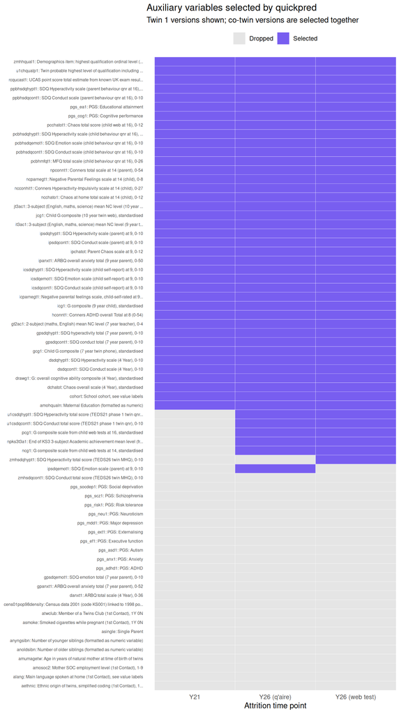

```r
selection_long = imap_dfr(aux_selection, function(x, tp) {
  tibble(variable = c(x$selected, x$dropped), selected = variable %in% x$selected, timepoint = tp)
}) %>%
  filter(!str_detect(variable, "2$") | variable %in% c("amosoc2")) %>%                   # one row per twin-specific variable (co-twin versions are selected together)
  mutate(
    timepoint = factor(rq1y_twin_labels_clean_extrashort[match(timepoint, rq1y_twin)], levels = rq1y_twin_labels_clean_extrashort),
    label     = str_trunc(paste0(variable, ": ", label_of(variable)), 70)
  ) %>%
  group_by(variable) %>%
  mutate(n_selected = sum(selected)) %>%
  ungroup() %>%
  mutate(label = fct_reorder(label, n_selected))

ggplot(selection_long, aes(x = timepoint, y = label, fill = selected)) +
  geom_tile(colour = "white") +
  scale_fill_manual(values = c("TRUE" = "#785EF0", "FALSE" = "grey90"), labels = c("TRUE" = "Selected", "FALSE" = "Dropped"), name = NULL) +
  labs(x = "Attrition time point", y = NULL, title = "Auxiliary variables selected by quickpred",
       subtitle = "Twin 1 versions shown; co-twin versions are selected together") +
  theme_minimal() +
  theme(axis.text.y = element_text(size = 6), panel.grid = element_blank(), legend.position = "top")
```

```r
save_plot("16_quickpred_selected_variables", width = 8, height = 14)
```

## Fraction of Missing Information

### Sample means

As in `8_rq6_3`: for each variable and time point, the K = 250 imputed means and their sampling variances (var / n) are pooled with Rubin’s rules (`mice::pool.scalar`). For the outcomes, only the cases observed in the original sample are kept (the others are set back to missing after imputation), so the FMI reflects the attritioned cases only. In the quickpred models, auxiliary variables that were dropped at a time point are not imputed, so they get no FMI.

```r
# FMI of the sample mean of each numeric variable in `vars`, at each time point
fmi_means = function(imputed_mice, vars, variant) {
  map_dfr(rq1y_twin, function(tp) {                                             # shown time points only
    imp_list = imputed_mice[[tp]]
    map_dfr(vars, function(v) {
      if (!v %in% colnames(imp_list[[1]]) || !is.numeric(imp_list[[1]][[v]])) return(NULL)
      Q = sapply(imp_list, function(d) mean(d[[v]], na.rm = TRUE))                              # K imputed means
      U = sapply(imp_list, function(d) stats::var(d[[v]], na.rm = TRUE) / sum(!is.na(d[[v]])))  # K sampling variances of the mean
      fmi = tryCatch(mice::pool.scalar(Q = Q, U = U)$fmi, error = function(e) NA_real_)
      tibble(timepoint = tp, variable = v, fmi = fmi)
    })
  }) %>%
    mutate(variant = variant)
}

imputed_mice = readRDS(results_file("8_1_imputed_mice", tag))
fmi_quickpred = fmi_means(imputed_mice, rq6_imputation_vars, "quickpred")
rm(imputed_mice); gc()
```

```
           used  (Mb) gc trigger   (Mb)   max used    (Mb)
Ncells  4256875 227.4    8051992  430.1    8051992   430.1
Vcells 54370413 414.9 1204654190 9190.8 1375426073 10493.7
```

```r
imputed_mice = readRDS(results_file("8_1_imputed_mice"))
fmi_inclusive = fmi_means(imputed_mice, rq6_imputation_vars, "Inclusive")
rm(imputed_mice); gc()
```

```
           used  (Mb) gc trigger   (Mb)   max used    (Mb)
Ncells  4257311 227.4    8051992  430.1    8051992   430.1
Vcells 54372877 414.9 1156532023 8823.7 1375426073 10493.7
```

```r
# Dropped auxiliary variables were not imputed in the quickpred models: no FMI
dropped_long = imap_dfr(aux_selection, function(x, tp) tibble(timepoint = tp, variable = x$dropped))

fmi_all = bind_rows(
  fmi_inclusive,
  fmi_quickpred %>% anti_join(dropped_long, by = c("timepoint", "variable"))
) %>%
  mutate(
    timepoint = factor(tp_labels[timepoint], levels = rq1y_twin_labels_clean_extrashort),
    variant   = factor(variant, levels = names(variant_colours))
  )

testthat::test_that("FMI computed for all outcomes, time points and variants", {
  n = fmi_all %>% filter(variable %in% rq6y_all) %>% dplyr::count(variant, timepoint)
  testthat::expect_true(all(n$n == length(rq6y_all)))
  testthat::expect_false(anyNA(fmi_all$fmi[fmi_all$variable %in% rq6y_all]))
})
```

```
Test passed 🥇
```

```r
fmi_all %>%
  filter(variable %in% rq6y) %>%                                                # twin 1 outcomes (twin 2 are near-identical)
  mutate(variable = factor(rq6y_labels[match(variable, rq6y)], levels = rq6y_labels)) %>%
  pivot_wider(names_from = variant, values_from = fmi) %>%
  mutate(Difference = quickpred - Inclusive) %>%
  arrange(timepoint, variable) %>%
  gt(groupname_col = "timepoint", rowname_col = "variable") %>%
  fmt_number(decimals = 3) %>%
  tab_spanner("FMI", columns = c(Inclusive, quickpred, Difference)) %>%
  cols_label(Difference = "quickpred − Inclusive") %>%
  tab_style(style = cell_text(size = px(12)), locations = list(cells_body(), cells_stub(), cells_column_labels(), cells_row_groups())) %>%
  tab_footnote("FMI of the twin 1 outcome means, by attrition time point. Positive differences: more information lost with the quickpred auxiliary set.")
```

|  | FMI Inclusive | FMI quickpred | FMI quickpred − Inclusive |
| --- | --- | --- | --- |
| Y21 |  |  |  |
| Y12: Depression (MFQ) | 0.476 | 0.404 | −0.072 |
| Y12: Externalising (SDQ) | 0.369 | 0.325 | −0.044 |
| Y12: Cognitive ability | 0.277 | 0.250 | −0.027 |
| Y16: GCSE grade | 0.241 | 0.236 | −0.004 |
| Y26 (q'aire) |  |  |  |
| Y12: Depression (MFQ) | 0.530 | 0.502 | −0.028 |
| Y12: Externalising (SDQ) | 0.526 | 0.446 | −0.080 |
| Y12: Cognitive ability | 0.427 | 0.359 | −0.068 |
| Y16: GCSE grade | 0.360 | 0.285 | −0.075 |
| Y26 (web test) |  |  |  |
| Y12: Depression (MFQ) | 0.834 | 0.746 | −0.088 |
| Y12: Externalising (SDQ) | 0.849 | 0.745 | −0.104 |
| Y12: Cognitive ability | 0.935 | 0.655 | −0.280 |
| Y16: GCSE grade | 0.783 | 0.540 | −0.242 |

FMI of the twin 1 outcome means, by attrition time point. Positive differences: more information lost with the quickpred auxiliary set.

### Change statistics

As in `8_rq6_3`: the FMI of the change statistics (attritioned + imputed − original), with the variance across the 40 bootstrap resamples within each imputed dataset as the within-imputation variance, pooled over the 250 imputations with Rubin’s rules (Barnard–Rubin degrees of freedom).

```r
# res[[<timepoint><imputation>]]$<stat> is a list of 40 bootstrap vectors
fmi_change = function(res, variant) {
  map_dfr(seq_along(rq1y_twin), function(tp) {
    nm = names(res)[str_detect(names(res), paste0("^", rq1y_twin[tp], "\\d+$"))]
    map_dfr(c(smd = "smd", var = "var", cor = "cor_resid"), function(stat) {
      map_dfr(nm, function(k) {
        m = do.call(rbind, res[[k]][[stat]])                                    # bootstrap draws x variables
        tibble(variable = if (stat == "cor_resid") cor_pairs else rq6y_labels,
               Q_m = colMeans(m), U_m = apply(m, 2, stats::var))
      })
    }, .id = "stat") %>%
      mutate(timepoint = rq1y_twin_labels_clean_extrashort[tp])
  }) %>%
    group_by(stat, timepoint, variable) %>%
    summarise(m = dplyr::n(), Q_bar = mean(Q_m), W = mean(U_m), B = stats::var(Q_m), .groups = "drop") %>%
    mutate(
      T   = W + B + B / m,                                                      # total variance
      r   = (1 + 1 / m) * B / W,                                                # relative increase in variance due to missingness
      df  = (m - 1) * (1 + 1 / r)^2,                                            # Barnard-Rubin degrees of freedom
      FMI = (r + 2 / (df + 3)) / (r + 1),
      variant = variant
    )
}

fmi_change_all = bind_rows(
  fmi_change(readRDS(results_file("8_rq6_boot_compare_results")),      "Inclusive"),
  fmi_change(readRDS(results_file("8_rq6_boot_compare_results", tag)), "quickpred")
) %>%
  mutate(
    timepoint = factor(timepoint, levels = rq1y_twin_labels_clean_extrashort),
    variant   = factor(variant, levels = names(variant_colours))
  )
gc()
```

```
           used  (Mb) gc trigger   (Mb)   max used    (Mb)
Ncells  4345332 232.1    8051992  430.1    8051992   430.1
Vcells 54577529 416.4  925225619 7059.0 1375426073 10493.7
```

```r
testthat::test_that("Change-statistic FMI: 250 imputations per estimate", {
  testthat::expect_true(all(fmi_change_all$m == 250))
})
```

```
Test passed 😸
```

```r
stat_labels = c(smd = "SMD", var = "Variance % change", cor = "Correlation change")

fmi_change_all %>%
  select(stat, timepoint, variable, variant, FMI) %>%
  pivot_wider(names_from = variant, values_from = FMI) %>%
  mutate(Difference = quickpred - Inclusive,
         stat = factor(stat_labels[stat], levels = stat_labels)) %>%
  arrange(stat, timepoint, variable) %>%
  gt(groupname_col = c("stat", "timepoint"), rowname_col = "variable") %>%
  fmt_number(decimals = 3) %>%
  tab_spanner("FMI", columns = c(Inclusive, quickpred, Difference)) %>%
  cols_label(Difference = "quickpred − Inclusive") %>%
  tab_style(style = cell_text(size = px(11)), locations = list(cells_body(), cells_stub(), cells_column_labels(), cells_row_groups()))
```

|  | FMI Inclusive | FMI quickpred | FMI quickpred − Inclusive |
| --- | --- | --- | --- |
| SMD - Y21 |  |  |  |
| Y12: Cognitive ability | 0.454 | 0.433 | −0.021 |
| Y12: Depression (MFQ) | 0.519 | 0.491 | −0.028 |
| Y12: Externalising (SDQ) | 0.514 | 0.479 | −0.036 |
| Y16: GCSE grade | 0.454 | 0.438 | −0.016 |
| SMD - Y26 (q'aire) |  |  |  |
| Y12: Cognitive ability | 0.527 | 0.506 | −0.021 |
| Y12: Depression (MFQ) | 0.535 | 0.518 | −0.017 |
| Y12: Externalising (SDQ) | 0.587 | 0.544 | −0.043 |
| Y16: GCSE grade | 0.539 | 0.450 | −0.089 |
| SMD - Y26 (web test) |  |  |  |
| Y12: Cognitive ability | 0.880 | 0.695 | −0.185 |
| Y12: Depression (MFQ) | 0.710 | 0.694 | −0.015 |
| Y12: Externalising (SDQ) | 0.784 | 0.704 | −0.080 |
| Y16: GCSE grade | 0.772 | 0.680 | −0.092 |
| Variance % change - Y21 |  |  |  |
| Y12: Cognitive ability | 0.419 | 0.441 | 0.023 |
| Y12: Depression (MFQ) | 0.490 | 0.479 | −0.011 |
| Y12: Externalising (SDQ) | 0.466 | 0.420 | −0.046 |
| Y16: GCSE grade | 0.365 | 0.456 | 0.091 |
| Variance % change - Y26 (q'aire) |  |  |  |
| Y12: Cognitive ability | 0.494 | 0.442 | −0.052 |
| Y12: Depression (MFQ) | 0.504 | 0.487 | −0.016 |
| Y12: Externalising (SDQ) | 0.569 | 0.472 | −0.097 |
| Y16: GCSE grade | 0.492 | 0.409 | −0.083 |
| Variance % change - Y26 (web test) |  |  |  |
| Y12: Cognitive ability | 0.711 | 0.602 | −0.109 |
| Y12: Depression (MFQ) | 0.694 | 0.589 | −0.105 |
| Y12: Externalising (SDQ) | 0.761 | 0.632 | −0.129 |
| Y16: GCSE grade | 0.774 | 0.611 | −0.163 |
| Correlation change - Y21 |  |  |  |
| Y12: Cognitive ability × Y12: Depression (MFQ) | 0.430 | 0.471 | 0.040 |
| Y12: Cognitive ability × Y12: Externalising (SDQ) | 0.482 | 0.454 | −0.028 |
| Y12: Externalising (SDQ) × Y12: Depression (MFQ) | 0.512 | 0.443 | −0.069 |
| Y16: GCSE grade × Y12: Cognitive ability | 0.378 | 0.358 | −0.021 |
| Y16: GCSE grade × Y12: Depression (MFQ) | 0.411 | 0.366 | −0.045 |
| Y16: GCSE grade × Y12: Externalising (SDQ) | 0.402 | 0.395 | −0.007 |
| Correlation change - Y26 (q'aire) |  |  |  |
| Y12: Cognitive ability × Y12: Depression (MFQ) | 0.485 | 0.472 | −0.013 |
| Y12: Cognitive ability × Y12: Externalising (SDQ) | 0.520 | 0.473 | −0.047 |
| Y12: Externalising (SDQ) × Y12: Depression (MFQ) | 0.577 | 0.507 | −0.070 |
| Y16: GCSE grade × Y12: Cognitive ability | 0.482 | 0.448 | −0.034 |
| Y16: GCSE grade × Y12: Depression (MFQ) | 0.446 | 0.464 | 0.018 |
| Y16: GCSE grade × Y12: Externalising (SDQ) | 0.453 | 0.497 | 0.044 |
| Correlation change - Y26 (web test) |  |  |  |
| Y12: Cognitive ability × Y12: Depression (MFQ) | 0.821 | 0.635 | −0.186 |
| Y12: Cognitive ability × Y12: Externalising (SDQ) | 0.858 | 0.639 | −0.220 |
| Y12: Externalising (SDQ) × Y12: Depression (MFQ) | 0.937 | 0.664 | −0.273 |
| Y16: GCSE grade × Y12: Cognitive ability | 0.773 | 0.592 | −0.181 |
| Y16: GCSE grade × Y12: Depression (MFQ) | 0.800 | 0.564 | −0.236 |
| Y16: GCSE grade × Y12: Externalising (SDQ) | 0.787 | 0.626 | −0.160 |

### Plot: Inclusive vs quickpred

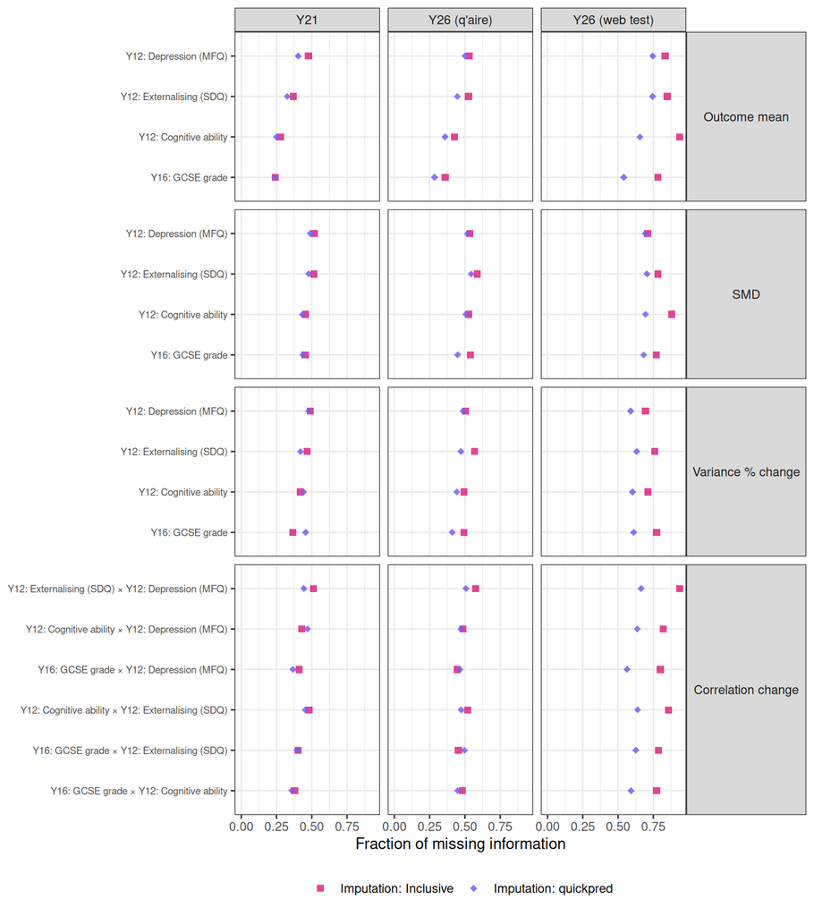

```r
fmi_plot_data = bind_rows(
  fmi_all %>%
    filter(variable %in% rq6y) %>%
    transmute(panel = "Outcome mean", timepoint, variable = rq6y_labels[match(variable, rq6y)], variant, FMI = fmi),
  fmi_change_all %>%
    transmute(panel = stat_labels[stat], timepoint, variable, variant, FMI)
) %>%
  mutate(panel = factor(panel, levels = c("Outcome mean", stat_labels)))

ggplot(fmi_plot_data, aes(x = FMI, y = fct_rev(factor(variable, levels = c(rq6y_labels, cor_pairs))), colour = variant, shape = variant)) +
  geom_point(size = 2, alpha = .85) +
  facet_grid(panel ~ timepoint, scales = "free_y", space = "free_y") +
  scale_colour_manual(values = variant_colours, labels = c("Inclusive" = "Imputation: Inclusive", "quickpred" = "Imputation: quickpred")) +
  scale_shape_manual(values = c("Inclusive" = 15, "quickpred" = 18), labels = c("Inclusive" = "Imputation: Inclusive", "quickpred" = "Imputation: quickpred")) +
  scale_x_continuous(limits = c(0, NA)) +
  labs(x = "Fraction of missing information", y = NULL, colour = NULL, shape = NULL) +
  theme_bw() +
  theme(legend.position = "bottom", strip.text.y = element_text(angle = 0), axis.text.y = element_text(size = 7))
```

```r
save_plot("15_quickpred_fmi", width = 10, height = 9)
```

### Auxiliary variables

FMI of the means of the auxiliary variables, comparing the two models **only for variables imputed in both**. The auxiliary variables quickpred dropped at a time point are not imputed in the quickpred models: their missing values stay missing, so they have no FMI and are left out. Variables with no missing data (FMI = 0 in both models) are left out too. Inclusive imputes every auxiliary variable, so every variable shown was imputed in both models, from different predictors. Unlike the outcomes, the auxiliary variables are not attritioned, so their FMI depends only on their own missingness and on how much information their predictors carry.

The PGS deserve a closer look. A PGS is missing for about 30% of families, and almost always all 24 PGS together (the family was not genotyped). In both models the PGS are used as auxiliary variables to impute the outcomes and the other auxiliary variables, but the PGS are not used to impute each other: for the families with missing PGS, the other PGS are missing too, so they would be imputed from each other’s imputed values. In the inclusive models each PGS is imputed from 109 predictors (the outcomes and the phenotypic auxiliary variables, no PGS; see `8_rq6_1a_imputation_prepare.R`). In the quickpred models, the other PGS are dropped as predictors by `minpuc = .25`, since they are observed for almost none of the cases where the PGS is missing. The 4 kept PGS (EA and cognition, both twins) are imputed from 10–22 phenotypic predictors only. The PGS convergence plot below compares how stable the PGS chains are in the two models.

```r
# Variables actually imputed in the quickpred models: method != "" in at least one sex-zygosity group at that time point
combine_input_qp = readRDS(results_file("8_1_combine_input", tag))
meth_list_qp     = combine_input_qp$meth_list
has_missing      = names(which(colSums(is.na(combine_input_qp$original_dataset)) > 0))
rm(combine_input_qp)

imputed_qp = imap_dfr(set_names(rq1y_twin), function(x, tp) {
  groups = names(meth_list_qp)[str_starts(names(meth_list_qp), paste0(tp, "\\."))]
  tibble(timepoint = tp_labels[[tp]],
         variable  = unique(unlist(lapply(groups, function(g) names(meth_list_qp[[g]])[meth_list_qp[[g]] != ""]))))
}) %>%
  filter(!variable %in% rq6y_all, variable %in% has_missing)

fmi_aux = fmi_all %>%
  filter(!variable %in% rq6y_all) %>%
  mutate(timepoint = as.character(timepoint)) %>%
  pivot_wider(names_from = variant, values_from = fmi) %>%
  semi_join(imputed_qp, by = c("timepoint", "variable")) %>%                    # imputed in the quickpred model at this time point
  filter(!is.na(Inclusive), !is.na(quickpred)) %>%                              # numeric (FMI defined) in both
  mutate(timepoint = factor(timepoint, levels = rq1y_twin_labels_clean_extrashort),
         pgs       = str_detect(variable, "^pgs_"))

testthat::test_that("Auxiliary FMI only for variables imputed in the quickpred model", {
  testthat::expect_false(any(map2_lgl(as.character(fmi_aux$timepoint), fmi_aux$variable,
                                      function(tp, v) v %in% aux_selection[[names(tp_labels)[tp_labels == tp]]]$dropped)))
})
```

```
Test passed 🎉
```

```r
imputed_qp %>%
  dplyr::count(timepoint, name = "Imputed in quickpred (with missing data)") %>%
  left_join(fmi_aux %>% mutate(timepoint = as.character(timepoint)) %>% dplyr::count(timepoint, name = "Numeric (shown below)"), by = "timepoint") %>%
  left_join(tibble(timepoint = tp_labels[names(aux_selection)], `Dropped by quickpred` = sapply(aux_selection, function(x) length(x$dropped))), by = "timepoint") %>%
  gt() %>%
  cols_label(timepoint = "Time point") %>%
  tab_header(title = "Auxiliary variables in the FMI comparison")
```

Auxiliary variables in the FMI comparison

| Time point | Imputed in quickpred (with missing data) | Numeric (shown below) | Dropped by quickpred |
| --- | --- | --- | --- |
| Y21 | 72 | 72 | 52 |
| Y26 (q'aire) | 84 | 84 | 40 |
| Y26 (web test) | 84 | 84 | 40 |

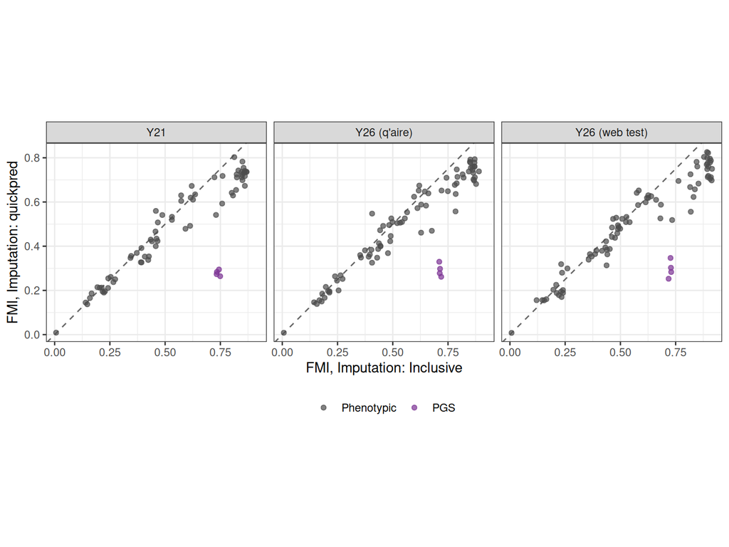

```r
ggplot(fmi_aux, aes(x = Inclusive, y = quickpred, colour = pgs)) +
  geom_abline(linetype = "dashed", colour = "grey40") +
  geom_point(alpha = .7) +
  facet_wrap(~ timepoint, nrow = 1) +
  coord_equal() +
  scale_colour_manual(values = c("FALSE" = "grey30", "TRUE" = "#7b3294"), labels = c("FALSE" = "Phenotypic", "TRUE" = "PGS"), name = NULL) +
  labs(x = "FMI, Imputation: Inclusive", y = "FMI, Imputation: quickpred") +
  theme_bw() +
  theme(legend.position = "bottom")
```

```r
save_plot("15_quickpred_fmi_aux", width = 10, height = 4)

fmi_aux %>%
  mutate(Difference = quickpred - Inclusive) %>%
  group_by(timepoint) %>%
  slice_max(abs(Difference), n = 5) %>%
  ungroup() %>%
  mutate(label = label_of(variable)) %>%
  select(timepoint, variable, label, Inclusive, quickpred, Difference) %>%
  gt(groupname_col = "timepoint", rowname_col = "variable") %>%
  fmt_number(columns = c(Inclusive, quickpred, Difference), decimals = 3) %>%
  cols_label(label = "Description", Difference = "quickpred − Inclusive") %>%
  tab_header(title = "Largest FMI differences for auxiliary variables (top 5 per time point)") %>%
  tab_style(style = cell_text(size = px(11)), locations = list(cells_body(), cells_stub(), cells_column_labels(), cells_row_groups()))
```

Largest FMI differences for auxiliary variables (top 5 per time point)

|  | Description | Inclusive | quickpred | quickpred − Inclusive |
| --- | --- | --- | --- | --- |
| Y21 |  |  |  |  |
| pgs_ea2 | PGS: Educational attainment (co-twin) | 0.749 | 0.264 | −0.485 |
| pgs_ea1 | PGS: Educational attainment | 0.733 | 0.273 | −0.460 |
| pgs_cog1 | PGS: Cognitive performance | 0.734 | 0.284 | −0.451 |
| pgs_cog2 | PGS: Cognitive performance (co-twin) | 0.744 | 0.295 | −0.449 |
| ipsdqhypt1 | SDQ Hyperactivity scale (parent) at 9, 0-10 | 0.730 | 0.541 | −0.189 |
| Y26 (q'aire) |  |  |  |  |
| pgs_ea1 | PGS: Educational attainment | 0.719 | 0.262 | −0.458 |
| pgs_ea2 | PGS: Educational attainment (co-twin) | 0.713 | 0.278 | −0.435 |
| pgs_cog2 | PGS: Cognitive performance (co-twin) | 0.714 | 0.298 | −0.416 |
| pgs_cog1 | PGS: Cognitive performance | 0.710 | 0.330 | −0.381 |
| ipsdqhypt1 | SDQ Hyperactivity scale (parent) at 9, 0-10 | 0.784 | 0.557 | −0.227 |
| Y26 (web test) |  |  |  |  |
| pgs_ea1 | PGS: Educational attainment | 0.718 | 0.253 | −0.465 |
| pgs_ea2 | PGS: Educational attainment (co-twin) | 0.730 | 0.283 | −0.447 |
| pgs_cog1 | PGS: Cognitive performance | 0.729 | 0.303 | −0.426 |
| pgs_cog2 | PGS: Cognitive performance (co-twin) | 0.727 | 0.347 | −0.380 |
| ipsdqhypt1 | SDQ Hyperactivity scale (parent) at 9, 0-10 | 0.819 | 0.556 | −0.263 |

## Bias of Unadjusted, Weighted and Imputed Estimates

## Summary across outcomes

Mean absolute bias and root mean squared error (RMSE, over bootstrap draws: combines bias and variability) for each statistic, averaged over the outcomes (or the 6 correlations). Lower is better.

**How the bootstrap draws and estimates are computed.** Every method has 10,000 bootstrap draws per attrition time point.

- **Resampling.** Each draw resamples families (twin pairs) with replacement. The same resampled families are used for the adjusted attritioned data and the original full-sample data, so each draw gives a paired bias estimate: adjusted attritioned estimate − original estimate.
- **Imputation (Inclusive and quickpred).** 40 draws in each of the 250 imputed datasets (`8_rq6_2_run_bootstrapping.R`, `15_quickpred_4_run_bootstrapping.R`). Pooling the draws across imputations means the intervals include both sampling variability and between-imputation variability. The imputation models are not refitted in each draw, and the quickpred selection is not repeated, so the uncertainty from choosing the auxiliary variables is not included.
- **Weighting.** 10,000 draws (`7_rq6_1_weighting.R`). The response-propensity models and weights are re-estimated within each resample.
- **Unadjusted.** 10,000 draws (`6_rq6_1_run_bootstrap_attritioning.R`).

The estimates are calculated as follows:

- **Per-estimate intervals** (forest plots, ACE): the point is the mean bias across the 10,000 draws. The 95% CI is the 2.5% and 97.5% percentiles of the draws (`ggdist::mean_qi`). The p-value comes from the probability of direction, i.e. the proportion of draws with the same sign as the mean (`bayestestR::p_direction`, converted with `pd_to_p`). It is then Holm-adjusted (p<sub>Holm</sub>; see below).
- **Mean absolute bias plot:** each point is the mean, across outcomes (or the 6 correlation pairs), of the absolute mean bias, as in the table. The ACE panels average over the 4 outcomes × 2 sexes, separately for A, C and E. No confidence intervals are shown. A simple percentile interval for an average of absolute values is biased upward when the true bias is close to zero. The forest plots below give the uncertainty for each estimate.

**Multiple comparisons (Holm correction).** “Significantly biased” means p<sub>Holm</sub> < .05. The Holm correction controls the family-wise error rate within a family: a set of similar tests corrected together. The families are kept small and are defined as in `8_rq6_3` and `9_`. Each row of the table below is one family, and the last column says how many separate families of that kind there are.

| Statistic | Tests corrected together (one family) | Tests per family | Separate family for each |
| --- | --- | --- | --- |
| SMD | bias in the SMD of the 4 outcomes | 4 | method × time point |
| Variance % change | bias in the variance of the 4 outcomes | 4 | method × time point |
| Correlation change | bias in the 6 correlations between the outcomes | 6 | method × time point |
| ACE | bias in A, C and E for the 4 outcomes, for one sex | 12 | method × time point × sex |
| Head-to-head (quickpred vs Inclusive) | difference in \|bias\| for the 4 outcomes (SMD, variance) or the 6 correlations | 4 or 6 | time point × statistic |

For example, the SMD p-values for Imputation (quickpred) at Y21 form one family of 4 tests, and are corrected separately from the SMD p-values for the other methods and time points. Nothing is corrected across methods, time points or statistics. The family-wise error rate is therefore controlled within each family of 4–12 tests, not across the whole document.

```r
bias = draws %>%
  group_by(variant, timepoint, stat, variable) %>%
  reframe(.mean_qi_pd(value), rmse = sqrt(mean(value^2))) %>%
  group_by(variant, timepoint, stat) %>%
  mutate(pval_adj = p.adjust(pval, method = "holm")) %>%                         # Holm family: method x time point x statistic (4 outcomes or 6 correlation pairs)
  ungroup()

ace = ace %>%
  group_by(variant, timepoint, sex) %>%
  mutate(pval_adj = p.adjust(pval, method = "holm")) %>%                         # Holm family: method x time point x sex (A, C, E x 4 outcomes = 12 tests)
  ungroup()

testthat::test_that("Holm family sizes", {
  testthat::expect_true(all((bias %>% dplyr::count(variant, timepoint, stat) %>% mutate(ok = n == ifelse(stat == "cor", 6, 4)))$ok))
  testthat::expect_true(all((ace %>% dplyr::count(variant, timepoint, sex))$n == 12))
})
```

```
Test passed 😸
```

```r
stat_labels = c(smd = "SMD", var = "Variance % change", cor = "Correlation change")

bias %>%
  group_by(stat, timepoint, variant) %>%
  summarise(mean_abs_bias = mean(abs(y)), mean_rmse = mean(rmse), n_biased = sum(pval_adj < .05), n = dplyr::n(), .groups = "drop") %>%
  mutate(stat = factor(stat_labels[stat], levels = stat_labels), n_biased = paste0(n_biased, "/", n),
         variant = factor(variant_plot_labels[as.character(variant)], levels = variant_plot_labels[variant_levels])) %>%   # same method labels as the plots
  select(-n) %>%
  pivot_wider(names_from = variant, values_from = c(mean_abs_bias, mean_rmse, n_biased), names_glue = "{variant}__{.value}") %>%
  arrange(stat, timepoint) %>%
  gt(groupname_col = "stat", rowname_col = "timepoint") %>%
  tab_spanner_delim(delim = "__") %>%
  fmt_number(columns = contains("mean_"), decimals = 3) %>%
  cols_label_with(fn = ~ str_replace_all(.x, c("mean_abs_bias" = "|Bias|", "mean_rmse" = "RMSE", "n_biased" = "Biased"))) %>%
  tab_style(style = cell_text(size = px(11)), locations = list(cells_body(), cells_stub(), cells_column_labels(), cells_column_spanners(), cells_row_groups())) %>%
  tab_footnote(md("|Bias| = mean absolute bias across outcomes (or correlation pairs). RMSE = root mean squared difference from the original estimate across bootstrap draws, averaged across outcomes. Biased = number of estimates significantly different from the original (p<sub>Holm</sub> < .05; Holm-corrected over the 4 outcomes, or the 6 correlation pairs, separately for each method, time point and statistic)."))
```

|  | Unadjusted \|Bias\| | Weighted \|Bias\| | Imputation (Inclusive) \|Bias\| | Imputation (quickpred) \|Bias\| | Unadjusted RMSE | Weighted RMSE | Imputation (Inclusive) RMSE | Imputation (quickpred) RMSE | Unadjusted Biased | Weighted Biased | Imputation (Inclusive) Biased | Imputation (quickpred) Biased |
| --- | --- | --- | --- | --- | --- | --- | --- | --- | --- | --- | --- | --- |
| SMD |  |  |  |  |  |  |  |  |  |  |  |  |
| Y21 | 0.094 | 0.060 | 0.058 | 0.029 | 0.095 | 0.062 | 0.059 | 0.032 | 3/4 | 3/4 | 3/4 | 2/4 |
| Y26 (q'aire) | 0.099 | 0.071 | 0.074 | 0.030 | 0.100 | 0.072 | 0.075 | 0.033 | 3/4 | 3/4 | 4/4 | 2/4 |
| Y26 (web test) | 0.176 | 0.123 | 0.142 | 0.042 | 0.178 | 0.127 | 0.148 | 0.047 | 4/4 | 3/4 | 3/4 | 2/4 |
| Variance % change |  |  |  |  |  |  |  |  |  |  |  |  |
| Y21 | 0.057 | 0.045 | 0.118 | 0.035 | 0.062 | 0.048 | 0.122 | 0.043 | 3/4 | 3/4 | 2/4 | 1/4 |
| Y26 (q'aire) | 0.066 | 0.050 | 0.137 | 0.036 | 0.072 | 0.055 | 0.140 | 0.045 | 3/4 | 2/4 | 3/4 | 2/4 |
| Y26 (web test) | 0.102 | 0.067 | 0.381 | 0.035 | 0.106 | 0.077 | 0.387 | 0.050 | 4/4 | 1/4 | 3/4 | 0/4 |
| Correlation change |  |  |  |  |  |  |  |  |  |  |  |  |
| Y21 | 0.009 | 0.010 | 0.019 | 0.009 | 0.013 | 0.013 | 0.024 | 0.016 | 0/6 | 0/6 | 1/6 | 0/6 |
| Y26 (q'aire) | 0.010 | 0.010 | 0.028 | 0.011 | 0.016 | 0.016 | 0.032 | 0.018 | 1/6 | 1/6 | 1/6 | 0/6 |
| Y26 (web test) | 0.021 | 0.022 | 0.123 | 0.023 | 0.028 | 0.031 | 0.130 | 0.032 | 0/6 | 0/6 | 4/6 | 0/6 |

|Bias| = mean absolute bias across outcomes (or correlation pairs). RMSE = root mean squared difference from the original estimate across bootstrap draws, averaged across outcomes. Biased = number of estimates significantly different from the original (p<sub>Holm</sub> < .05; Holm-corrected over the 4 outcomes, or the 6 correlation pairs, separately for each method, time point and statistic).

```r
# Show and save each plot twice: with all methods, then without Imputation (Inclusive)
# (chunks calling it use results: asis, so the text and links print as markdown)
show_both = function(p, name, width, height) {
  p_no_inc = p %+% droplevels(filter(p$data, variant != "Inclusive"))
  links = function(f) paste0("[PNG](plots/pngs/", f, ".png) · [PDF](plots/pdfs/", f, ".pdf)")
  save_plot(name, width = width, height = height, plot = p)
  save_plot(paste0(name, "_no_inclusive"), width = width, height = height, plot = p_no_inc)
  cat("\n\n**With Imputation (Inclusive)** (all methods). Download:", links(name), "\n\n")
  print(p)
  cat("\n\n**Without Imputation (Inclusive)**. Download:", links(paste0(name, "_no_inclusive")), "\n\n")
  print(p_no_inc)
  cat("\n\n")
}

# ACE: mean |bias| across the 4 outcomes x 2 sexes, separately for A, C and E
ace_stat_labels = c(a = "ACE: A", c = "ACE: C", e = "ACE: E")

ace_mean_abs_bias = ace %>%
  group_by(stat = par, timepoint, variant) %>%
  summarise(mean_abs_bias = mean(abs(y)), .groups = "drop") %>%
  mutate(stat = ace_stat_labels[stat])

p = bias %>%
  group_by(stat, timepoint, variant) %>%
  summarise(mean_abs_bias = mean(abs(y)), .groups = "drop") %>%
  mutate(stat = stat_labels[stat]) %>%
  bind_rows(ace_mean_abs_bias) %>%
  mutate(stat = factor(stat, levels = c(stat_labels, ace_stat_labels))) %>%
  ggplot(aes(x = timepoint, y = mean_abs_bias, colour = variant, shape = variant, group = variant)) +
  geom_line(position = position_dodge(width = 0.4)) +
  geom_point(size = 2.2, position = position_dodge(width = 0.4)) +
  facet_wrap(~ stat, scales = "free_y", ncol = 3) +
  expand_limits(y = 0) +
  scale_colour_manual(values = variant_colours, labels = variant_plot_labels) +
  scale_shape_manual(values = variant_shapes, labels = variant_plot_labels) +
  labs(x = "Attrition time point", y = "Mean absolute bias", colour = NULL, shape = NULL) +
  theme_bw() +
  theme(axis.text.x = element_text(angle = 30, hjust = 1), legend.position = "bottom")

show_both(p, "16_mean_abs_bias", width = 9, height = 8)
```

**With Imputation (Inclusive)** (all methods). Download: PNG · PDF

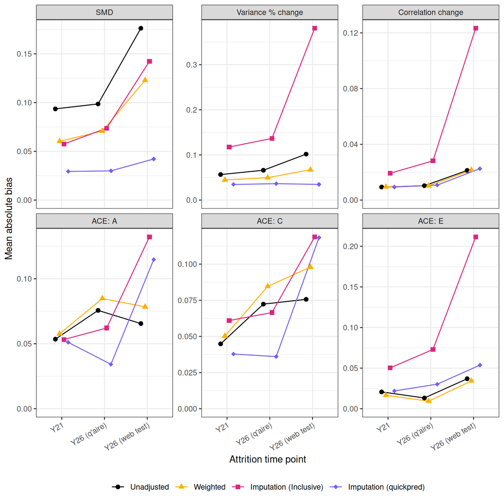

**Without Imputation (Inclusive)**. Download: PNG · PDF

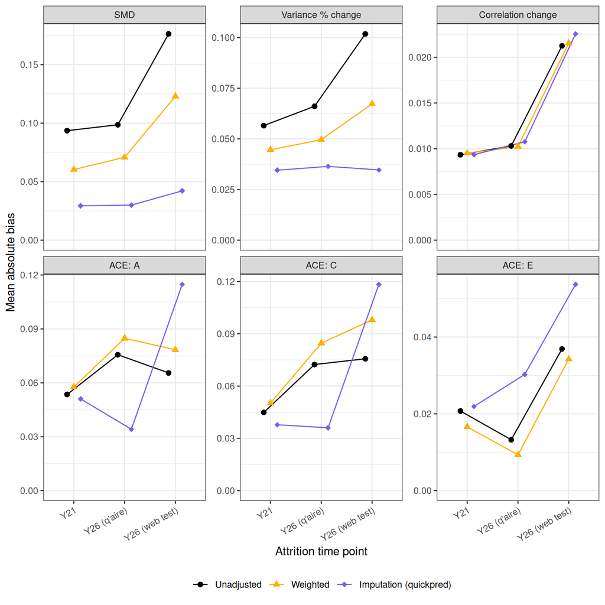

The same plot with the ACE components combined: the ACE panel is the mean |bias| across all 24 ACE estimates (A, C and E × 4 outcomes × 2 sexes).

```r
ace_combined_label = "ACE (A, C & E)"

p = bias %>%
  group_by(stat, timepoint, variant) %>%
  summarise(mean_abs_bias = mean(abs(y)), .groups = "drop") %>%
  # variance bias is a proportional change: x 100 so the panel is in percent
  mutate(mean_abs_bias = ifelse(stat == "var", mean_abs_bias * 100, mean_abs_bias),
         stat = stat_labels[stat]) %>%
  bind_rows(
    ace %>%
      group_by(timepoint, variant) %>%
      summarise(mean_abs_bias = mean(abs(y)), .groups = "drop") %>%
      mutate(stat = ace_combined_label)
  ) %>%
  mutate(
    # point labels: variance in percent (1 decimal); all others 3 decimals
    # with the leading zero dropped (0.012 -> .012)
    value_label = ifelse(
      stat == stat_labels[["var"]],
      paste0(sprintf("%.1f", mean_abs_bias), "%"),
      sub("^(-?)0\\.", "\\1.", sprintf("%.3f", mean_abs_bias))
    ),
    stat = factor(stat, levels = c(stat_labels, ace_combined_label))
  ) %>%
  ggplot(aes(x = timepoint, y = mean_abs_bias, colour = variant, shape = variant, group = variant)) +
  geom_line(position = position_dodge(width = 0.4)) +
  geom_point(size = 3.3, position = position_dodge(width = 0.4)) +             # 50% larger than other plots (Fig 5)
  # value labels in each method's colour: start at the (dodged) point, then
  # repelled vertically only, so labels at the same time point don't overlap
  # each other or the points
  ggrepel::geom_label_repel(
    aes(label = value_label),
    position           = position_dodge(width = 0.4),
    direction          = "y",
    size               = 2.1,
    fill               = alpha("white", 0.8),                                 # keeps labels legible where they cross a line
    label.size         = NA,                                                  # no label border
    label.padding      = 0.08,
    box.padding        = 0.25,
    point.padding      = 0.3,                                                 # keep labels off the points
    force              = 2,
    min.segment.length = Inf,                                                 # no connector lines
    max.overlaps       = Inf,
    seed               = 1,
    show.legend        = FALSE
  ) +
  facet_wrap(~ stat, scales = "free_y", nrow = 1) +
  expand_limits(y = 0) +
  # Breaks/labels functions are called per panel but don't know which panel,
  # so the variance panel (in percent) is identified by its range: it is the
  # only panel extending above 1 (the others are < .2).
  # - variance panel: breaks every 2 percentage points, labelled "2%"
  # - other panels: default breaks, leading zero dropped (0.05 -> .05);
  #   a break at exactly zero is shown as "0"
  scale_y_continuous(
    breaks = function(lims) {
      if (max(lims, na.rm = TRUE) > 1) seq(0, floor(max(lims, na.rm = TRUE) / 2) * 2, by = 2) else scales::extended_breaks()(lims)
    },
    expand = expansion(mult = c(0.05, 0.12)),                                 # headroom for the top labels
    labels = function(x) {
      if (max(x, na.rm = TRUE) > 1) return(ifelse(is.na(x), NA, paste0(x, "%")))
      lab = sub("^(-?)0\\.", "\\1.", trimws(format(x, trim = TRUE)))
      ifelse(is.na(x), NA, ifelse(x == 0, "0", lab))
    }
  ) +
  scale_colour_manual(values = variant_colours, labels = variant_plot_labels) +
  scale_shape_manual(values = variant_shapes, labels = variant_plot_labels) +
  labs(x = "Attrition time point", y = "Mean absolute bias\n(vs original estimate)", colour = NULL, shape = NULL) +
  theme_bw() +
  theme(axis.text.x = element_text(angle = 30, hjust = 1), legend.position = "bottom")

show_both(p, "16_mean_abs_bias_ace_combined", width = 11, height = 5)
```

**With Imputation (Inclusive)** (all methods). Download: PNG · PDF

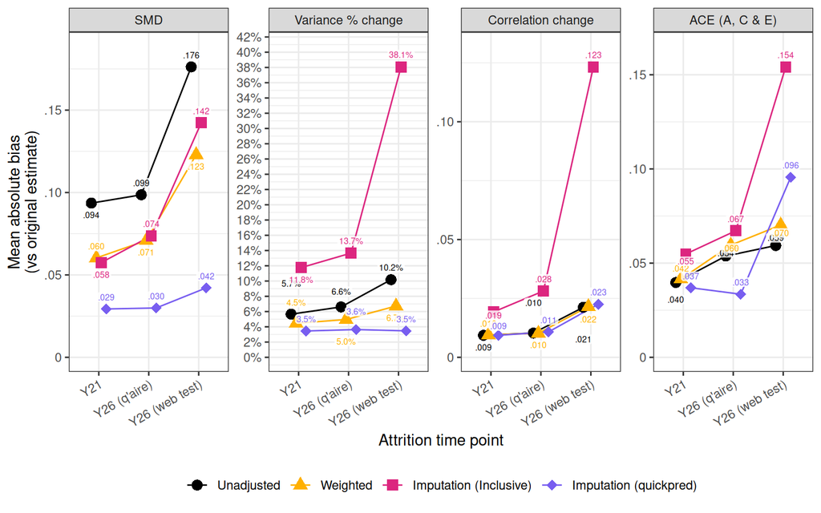

**Without Imputation (Inclusive)**. Download: PNG · PDF

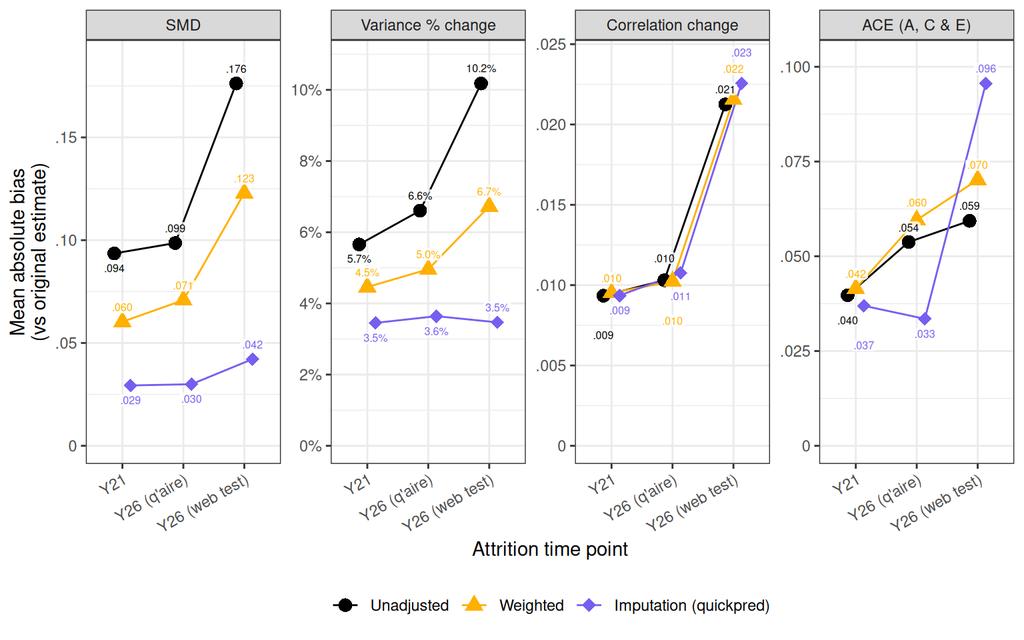

### Percentage reduction in mean absolute bias

Percentage reduction in the mean absolute bias (the metric in the plot above) relative to the unadjusted attritioned data, for each correction method, statistic and attrition time point: 100 × (mean |bias|<sub>Unadjusted</sub> − mean |bias|<sub>method</sub>) / mean |bias|<sub>Unadjusted</sub>. 100% = bias fully removed; negative values (red) = the method increased bias. The last row of each statistic is the average of the per-time-point percentages.

```r
pct_reduction = bias %>%
  group_by(stat, timepoint, variant) %>%
  summarise(mean_abs_bias = mean(abs(y)), .groups = "drop") %>%
  mutate(stat = stat_labels[stat]) %>%
  bind_rows(
    ace %>%
      group_by(timepoint, variant) %>%
      summarise(mean_abs_bias = mean(abs(y)), .groups = "drop") %>%
      mutate(stat = ace_combined_label)
  ) %>%
  group_by(stat, timepoint) %>%
  mutate(unadj_abs_bias = mean_abs_bias[variant == "Unadjusted"],
         pct_reduction  = 100 * (unadj_abs_bias - mean_abs_bias) / unadj_abs_bias) %>%
  ungroup()

testthat::test_that("% reduction: one unadjusted reference per statistic and time point", {
  n_ref = pct_reduction %>% filter(variant == "Unadjusted") %>% dplyr::count(stat, timepoint)
  testthat::expect_true(all(n_ref$n == 1))
  testthat::expect_equal(nrow(n_ref), length(c(stat_labels, ace_combined_label)) * nlevels(pct_reduction$timepoint))
})
```

```
Test passed 🥳
```

```r
pct_method_cols = unname(variant_plot_labels[setdiff(variant_levels, "Unadjusted")])

pct_wide = pct_reduction %>%
  filter(variant != "Unadjusted") %>%
  mutate(method = factor(variant_plot_labels[as.character(variant)], levels = pct_method_cols),
         stat   = factor(stat, levels = c(stat_labels, ace_combined_label))) %>%
  select(stat, timepoint, unadj_abs_bias, method, pct_reduction) %>%
  pivot_wider(names_from = method, values_from = pct_reduction) %>%
  arrange(stat, timepoint) %>%
  mutate(stat = as.character(stat), timepoint = as.character(timepoint))

# Average across time points: mean of the per-time-point % reductions (and of the unadjusted mean |bias|),
# separately for each statistic and method; added as the last row of each statistic group
pct_avg = pct_wide %>%
  group_by(stat) %>%
  summarise(across(c(unadj_abs_bias, all_of(pct_method_cols)), mean), n_tp = dplyr::n(), .groups = "drop") %>%
  mutate(timepoint = "Average across time points")

testthat::test_that("% reduction averages: each average is over all shown time points", {
  testthat::expect_true(all(pct_avg$n_tp == length(rq1y_twin)))
})
```

```
Test passed 🥇
```

```r
pct_wide = bind_rows(pct_wide, select(pct_avg, -n_tp)) %>%
  mutate(stat = factor(stat, levels = c(stat_labels, ace_combined_label))) %>%
  arrange(stat, timepoint == "Average across time points") %>%                     # average last within each statistic
  mutate(stat = as.character(stat))
avg_rows = which(pct_wide$timepoint == "Average across time points")

pct_tbl = pct_wide %>%
  gt(groupname_col = "stat", rowname_col = "timepoint") %>%
  tab_header(title = "Percentage reduction in mean absolute bias relative to the unadjusted attritioned data") %>%
  cols_label(unadj_abs_bias = md("Unadjusted<br>mean |bias|")) %>%
  tab_spanner("% reduction in mean |bias|", columns = all_of(pct_method_cols)) %>%
  fmt_number(columns = unadj_abs_bias, decimals = 3) %>%
  fmt_number(columns = all_of(pct_method_cols), decimals = 1, pattern = "{x}%") %>%
  cols_align("center", columns = -timepoint) %>%
  tab_style(style = cell_text(weight = "bold"), locations = cells_row_groups()) %>%
  tab_style(style = cell_text(size = px(11)), locations = list(cells_body(), cells_stub(), cells_column_labels(), cells_column_spanners(), cells_row_groups())) %>%
  tab_footnote(md(paste0(
    "% reduction = 100 × (mean |bias|<sub>Unadjusted</sub> − mean |bias|<sub>method</sub>) / mean |bias|<sub>Unadjusted</sub>. ",
    "Mean |bias| = mean absolute bias across the 4 outcomes (SMD, variance), the 6 correlation pairs, or the 24 ACE estimates ",
    "(A, C and E × 4 outcomes × 2 sexes), as in the plot above. Variance bias is a proportional change. ",
    "Negative values (red) = the method increased bias. Shaded: the method with the largest reduction in each row. ",
    "Average across time points (bold) = mean of the per-time-point values for that statistic and method."))) %>%
  tab_style(style = list(cell_text(weight = "bold"), cell_borders(sides = "top", color = "grey50")),
            locations = list(cells_body(rows = avg_rows), cells_stub(rows = avg_rows)))

# Negative reductions in red; largest reduction in each row shaded
best_method = apply(as.matrix(pct_wide[, pct_method_cols]), 1, function(r) pct_method_cols[which.max(r)])
for (m in pct_method_cols) {
  neg_rows  = which(pct_wide[[m]] < 0)
  best_rows = which(best_method == m)
  if (length(neg_rows))  pct_tbl = pct_tbl %>% tab_style(cell_text(color = "#C0392B"), cells_body(columns = all_of(m), rows = neg_rows))
  if (length(best_rows)) pct_tbl = pct_tbl %>% tab_style(cell_fill(color = "#E6E6E6"), cells_body(columns = all_of(m), rows = best_rows))
}
pct_tbl
```

Percentage reduction in mean absolute bias relative to the unadjusted attritioned data

|  | Unadjusted mean \|bias\| | % reduction in mean \|bias\| Weighted | % reduction in mean \|bias\| Imputation (Inclusive) | % reduction in mean \|bias\| Imputation (quickpred) |
| --- | --- | --- | --- | --- |
| SMD |  |  |  |  |
| Y21 | 0.094 | 35.5% | 38.5% | 68.6% |
| Y26 (q'aire) | 0.099 | 28.1% | 25.3% | 69.6% |
| Y26 (web test) | 0.176 | 30.2% | 19.2% | 76.1% |
| Average across time points | 0.123 | 31.3% | 27.7% | 71.4% |
| Variance % change |  |  |  |  |
| Y21 | 0.057 | 21.2% | −107.9% | 38.9% |
| Y26 (q'aire) | 0.066 | 24.9% | −106.8% | 44.9% |
| Y26 (web test) | 0.102 | 33.9% | −274.0% | 65.9% |
| Average across time points | 0.075 | 26.7% | −162.9% | 49.9% |
| Correlation change |  |  |  |  |
| Y21 | 0.009 | −1.9% | −106.2% | −0.2% |
| Y26 (q'aire) | 0.010 | 0.7% | −173.2% | −4.4% |
| Y26 (web test) | 0.021 | −1.4% | −480.1% | −6.1% |
| Average across time points | 0.014 | −0.9% | −253.2% | −3.6% |
| ACE (A, C & E) |  |  |  |  |
| Y21 | 0.040 | −4.6% | −38.1% | 7.0% |
| Y26 (q'aire) | 0.054 | −10.8% | −25.0% | 37.7% |
| Y26 (web test) | 0.059 | −18.3% | −159.7% | −61.1% |
| Average across time points | 0.051 | −11.2% | −74.3% | −5.5% |

Root mean squared error (RMSE) of each estimate across the 10,000 bootstrap draws, sqrt(mean(bias²)), averaged across outcomes (or the 6 correlation pairs, or the 4 outcomes × 2 sexes for ACE). It combines bias and variability. Lower is better. Unadjusted is missing from the ACE panels because its per-draw ACE values were not saved.

```r
ace_rmse = ace_draws %>%
  group_by(variant, timepoint, par, variable, sex) %>%
  summarise(rmse = sqrt(mean(value^2)), .groups = "drop") %>%
  group_by(stat = par, timepoint, variant) %>%
  summarise(mean_rmse = mean(rmse), .groups = "drop") %>%
  mutate(stat = ace_stat_labels[stat])

p = bias %>%
  group_by(stat, timepoint, variant) %>%
  summarise(mean_rmse = mean(rmse), .groups = "drop") %>%
  mutate(stat = stat_labels[stat]) %>%
  bind_rows(ace_rmse) %>%
  mutate(stat = factor(stat, levels = c(stat_labels, ace_stat_labels))) %>%
  ggplot(aes(x = timepoint, y = mean_rmse, colour = variant, shape = variant, group = variant)) +
  geom_line(position = position_dodge(width = 0.4)) +
  geom_point(size = 2.2, position = position_dodge(width = 0.4)) +
  facet_wrap(~ stat, scales = "free_y", ncol = 3) +
  expand_limits(y = 0) +
  scale_colour_manual(values = variant_colours, labels = variant_plot_labels, drop = FALSE) +
  scale_shape_manual(values = variant_shapes, labels = variant_plot_labels, drop = FALSE) +
  labs(x = "Attrition time point", y = "Mean RMSE", colour = NULL, shape = NULL) +
  theme_bw() +
  theme(axis.text.x = element_text(angle = 30, hjust = 1), legend.position = "bottom")

show_both(p, "16_rmse", width = 9, height = 8)
```

**With Imputation (Inclusive)** (all methods). Download: PNG · PDF

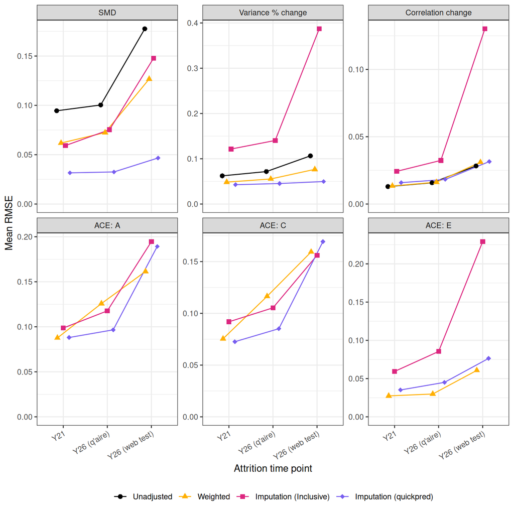

**Without Imputation (Inclusive)**. Download: PNG · PDF

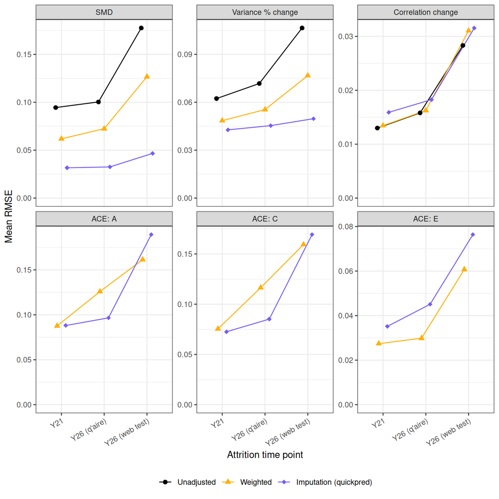

Number of estimates significantly biased (p<sub>Holm</sub> < .05) for each method, statistic and time point. The maximum in each panel is the number of estimates: 4 outcomes (SMD, variance), 6 correlation pairs, or 4 outcomes × 2 sexes (ACE components). The tests are Holm-corrected in the families listed in the table above.

```r
# Plot labels with a subscripted "Holm" (plotmath), reused in the forest plots below
subtitle_holm = quote("Faded: not significantly different from the original estimate (" * italic(p)[Holm] >= ".05" * ")")

n_biased = bias %>%
  group_by(stat, timepoint, variant) %>%
  summarise(n_biased = sum(pval_adj < .05), n = dplyr::n(), .groups = "drop") %>%
  mutate(stat = stat_labels[stat]) %>%
  bind_rows(
    ace %>%
      group_by(stat = par, timepoint, variant) %>%
      summarise(n_biased = sum(pval_adj < .05), n = dplyr::n(), .groups = "drop") %>%
      mutate(stat = ace_stat_labels[stat])
  ) %>%
  mutate(stat = factor(paste0(stat, " (of ", n, ")"), levels = paste0(c(stat_labels, ace_stat_labels), " (of ", c(4, 4, 6, 8, 8, 8), ")")))

testthat::test_that("n-biased plot: facet labels match the number of estimates", {
  testthat::expect_false(anyNA(n_biased$stat))
})
```

Test passed 🥳

```r
p = ggplot(n_biased, aes(x = timepoint, y = n_biased, colour = variant, shape = variant, group = variant)) +
  geom_blank(aes(y = n)) +                                                       # y-axis runs from 0 to the number of estimates in each panel
  geom_line(position = position_dodge(width = 0.4)) +
  geom_point(size = 2.2, position = position_dodge(width = 0.4)) +
  facet_wrap(~ stat, scales = "free_y", ncol = 3) +
  scale_y_continuous(breaks = function(lims) seq(0, floor(lims[2])), limits = c(0, NA)) +
  scale_colour_manual(values = variant_colours, labels = variant_plot_labels) +
  scale_shape_manual(values = variant_shapes, labels = variant_plot_labels) +
  labs(x = "Attrition time point", y = quote("Number of significantly biased estimates (" * italic(p)[Holm] < ".05" * ")"), colour = NULL, shape = NULL) +
  theme_bw() +
  theme(axis.text.x = element_text(angle = 30, hjust = 1), legend.position = "bottom", panel.grid.minor = element_blank())

show_both(p, "16_n_biased", width = 9, height = 8)
```

**With Imputation (Inclusive)** (all methods). Download: PNG · PDF

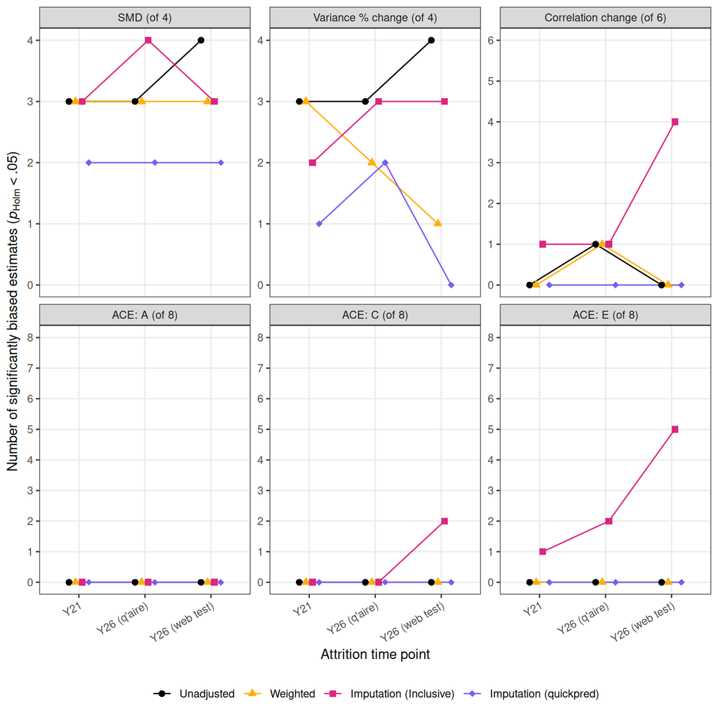

**Without Imputation (Inclusive)**. Download: PNG · PDF

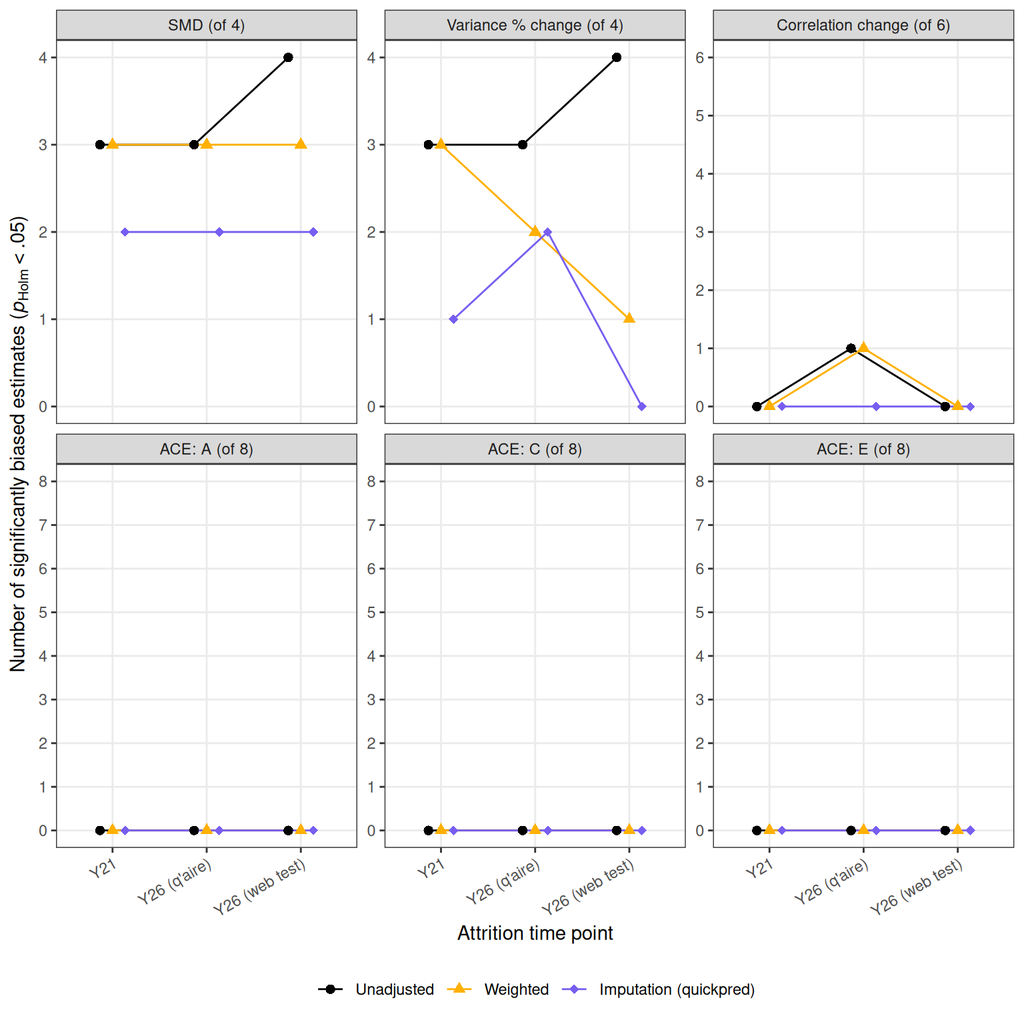

## Bias by parameter: all methods

One row per parameter, one column pair per method. Bias = mean bias across the 10,000 bootstrap draws [95% percentile interval]; RMSE = root mean squared bias across the draws. **Bold**: significantly biased (p<sub>Holm</sub> < .05, same Holm families as above). Shaded: the method with the smallest |bias| for that parameter.

```r
method_cols = variant_plot_labels[variant_levels]

# d: one row per method x parameter, with y, ymin, ymax, pval_adj, rmse, a `group` and a `parameter` column (factors, in display order)
method_table = function(d, footnote) {
  d = d %>%
    mutate(method = factor(variant_plot_labels[as.character(variant)], levels = method_cols),
           est    = sprintf("%.3f [%.3f, %.3f]", y, ymin, ymax),
           sig    = pval_adj < .05) %>%
    group_by(group, parameter) %>%
    mutate(best = abs(y) == min(abs(y))) %>%
    ungroup() %>%
    arrange(group, parameter)

  display = d %>%
    select(group, parameter, method, est, rmse) %>%
    pivot_wider(names_from = method, values_from = c(est, rmse), names_glue = "{method}__{.value}")
  flags = d %>%
    select(group, parameter, method, sig, best) %>%
    pivot_wider(names_from = method, values_from = c(sig, best), names_glue = "{.value}_{method}")
  wide = left_join(display, flags, by = c("group", "parameter")) %>%
    arrange(group, parameter) %>%
    mutate(group = as.character(group), parameter = as.character(parameter))

  methods = intersect(method_cols, unique(as.character(d$method)))
  tbl = wide %>%
    select(group, parameter, all_of(as.vector(rbind(paste0(methods, "__est"), paste0(methods, "__rmse")))), starts_with("sig_"), starts_with("best_")) %>%
    gt(groupname_col = "group", rowname_col = "parameter") %>%
    cols_hide(c(starts_with("sig_"), starts_with("best_"))) %>%
    tab_spanner_delim(delim = "__") %>%
    cols_label_with(fn = ~ str_replace_all(.x, c("^est$" = "Bias [95% CI]", "^rmse$" = "RMSE"))) %>%
    fmt_number(columns = ends_with("__rmse"), decimals = 3) %>%
    sub_missing(missing_text = "—") %>%
    tab_style(style = cell_text(size = px(11)), locations = list(cells_body(), cells_stub(), cells_column_labels(), cells_column_spanners(), cells_row_groups())) %>%
    tab_style(style = cell_text(weight = "bold"), locations = cells_row_groups()) %>%
    tab_footnote(md(footnote))

  for (m in methods) {
    sig_rows  = which(wide[[paste0("sig_", m)]] %in% TRUE)
    best_rows = which(wide[[paste0("best_", m)]] %in% TRUE)
    if (length(sig_rows))  tbl = tbl %>% tab_style(cell_text(weight = "bold"),  cells_body(columns = paste0(m, "__est"), rows = sig_rows))
    if (length(best_rows)) tbl = tbl %>% tab_style(cell_fill(color = "#E6E6E6"), cells_body(columns = paste0(m, c("__est", "__rmse")), rows = best_rows))
  }
  tbl
}

# Means, variances and correlations
bias %>%
  mutate(group     = factor(paste0(stat_labels[stat], " · ", timepoint),
                            levels = paste0(rep(stat_labels, each = nlevels(timepoint)), " · ", levels(timepoint))),
         parameter = factor(variable, levels = c(rq6y_labels, cor_pairs))) %>%
  { testthat::expect_false(anyNA(.$parameter) || anyNA(.$group)); . } %>%
  method_table("Bias in the SMD and correlations: adjusted attritioned − original. Bias in the variance: proportional change (adjusted attritioned vs original). Bold: p<sub>Holm</sub> < .05. Shaded: smallest |bias| for the parameter.")
```

|  | Unadjusted Bias [95% CI] | Unadjusted RMSE | Weighted Bias [95% CI] | Weighted RMSE | Imputation (Inclusive) Bias [95% CI] | Imputation (Inclusive) RMSE | Imputation (quickpred) Bias [95% CI] | Imputation (quickpred) RMSE |
| --- | --- | --- | --- | --- | --- | --- | --- | --- |
| SMD · Y21 |  |  |  |  |  |  |  |  |
| Y12: Depression (MFQ) | -0.011 [-0.027, 0.005] | 0.014 | 0.007 [-0.010, 0.024] | 0.011 | 0.137 [0.108, 0.169] | 0.138 | 0.038 [0.014, 0.062] | 0.040 |
| Y12: Externalising (SDQ) | -0.108 [-0.125, -0.092] | 0.109 | -0.060 [-0.077, -0.042] | 0.060 | 0.031 [0.008, 0.055] | 0.033 | -0.018 [-0.039, 0.004] | 0.021 |
| Y12: Cognitive ability | 0.079 [0.062, 0.096] | 0.079 | 0.058 [0.041, 0.075] | 0.059 | 0.016 [-0.005, 0.036] | 0.019 | 0.014 [-0.006, 0.034] | 0.017 |
| Y16: GCSE grade | 0.177 [0.160, 0.193] | 0.177 | 0.117 [0.102, 0.132] | 0.117 | 0.046 [0.029, 0.062] | 0.046 | 0.048 [0.032, 0.065] | 0.049 |
| SMD · Y26 (q'aire) |  |  |  |  |  |  |  |  |
| Y12: Depression (MFQ) | -0.005 [-0.024, 0.014] | 0.011 | 0.010 [-0.010, 0.031] | 0.015 | 0.161 [0.130, 0.195] | 0.162 | 0.040 [0.012, 0.067] | 0.042 |
| Y12: Externalising (SDQ) | -0.120 [-0.139, -0.102] | 0.121 | -0.064 [-0.085, -0.042] | 0.065 | 0.047 [0.019, 0.076] | 0.049 | -0.019 [-0.044, 0.005] | 0.023 |
| Y12: Cognitive ability | 0.090 [0.070, 0.111] | 0.091 | 0.077 [0.056, 0.098] | 0.078 | 0.031 [0.005, 0.055] | 0.033 | 0.019 [-0.005, 0.042] | 0.022 |
| Y16: GCSE grade | 0.179 [0.160, 0.198] | 0.179 | 0.132 [0.114, 0.150] | 0.132 | 0.056 [0.037, 0.075] | 0.057 | 0.042 [0.025, 0.059] | 0.043 |
| SMD · Y26 (web test) |  |  |  |  |  |  |  |  |
| Y12: Depression (MFQ) | -0.043 [-0.075, -0.010] | 0.046 | -0.012 [-0.051, 0.028] | 0.023 | 0.353 [0.296, 0.414] | 0.354 | 0.060 [0.017, 0.106] | 0.064 |
| Y12: Externalising (SDQ) | -0.195 [-0.226, -0.163] | 0.195 | -0.115 [-0.153, -0.077] | 0.117 | 0.091 [0.038, 0.144] | 0.095 | -0.027 [-0.063, 0.011] | 0.033 |
| Y12: Cognitive ability | 0.174 [0.137, 0.211] | 0.175 | 0.146 [0.107, 0.184] | 0.147 | 0.050 [-0.045, 0.139] | 0.064 | 0.027 [-0.012, 0.064] | 0.033 |
| Y16: GCSE grade | 0.293 [0.261, 0.326] | 0.294 | 0.219 [0.187, 0.250] | 0.219 | 0.075 [0.040, 0.115] | 0.078 | 0.055 [0.027, 0.082] | 0.056 |
| Variance % change · Y21 |  |  |  |  |  |  |  |  |
| Y12: Depression (MFQ) | 0.002 [-0.041, 0.043] | 0.021 | 0.023 [-0.023, 0.069] | 0.033 | 0.329 [0.239, 0.426] | 0.333 | 0.097 [0.030, 0.169] | 0.103 |
| Y12: Externalising (SDQ) | -0.086 [-0.112, -0.061] | 0.087 | -0.046 [-0.074, -0.017] | 0.048 | 0.095 [0.055, 0.138] | 0.098 | -0.011 [-0.044, 0.024] | 0.020 |
| Y12: Cognitive ability | -0.050 [-0.075, -0.026] | 0.052 | -0.039 [-0.065, -0.013] | 0.041 | 0.025 [-0.008, 0.059] | 0.030 | -0.007 [-0.039, 0.028] | 0.019 |
| Y16: GCSE grade | -0.088 [-0.114, -0.063] | 0.089 | -0.070 [-0.099, -0.041] | 0.072 | -0.021 [-0.049, 0.009] | 0.025 | -0.023 [-0.056, 0.009] | 0.029 |
| Variance % change · Y26 (q'aire) |  |  |  |  |  |  |  |  |
| Y12: Depression (MFQ) | 0.007 [-0.041, 0.055] | 0.026 | 0.019 [-0.034, 0.074] | 0.033 | 0.322 [0.228, 0.422] | 0.326 | 0.088 [0.015, 0.164] | 0.096 |
| Y12: Externalising (SDQ) | -0.083 [-0.112, -0.054] | 0.084 | -0.030 [-0.066, 0.005] | 0.035 | 0.133 [0.085, 0.183] | 0.136 | 0.007 [-0.031, 0.047] | 0.021 |
| Y12: Cognitive ability | -0.056 [-0.084, -0.028] | 0.057 | -0.048 [-0.079, -0.018] | 0.051 | 0.028 [-0.012, 0.069] | 0.034 | -0.010 [-0.044, 0.027] | 0.021 |
| Y16: GCSE grade | -0.119 [-0.146, -0.092] | 0.120 | -0.101 [-0.133, -0.069] | 0.102 | -0.063 [-0.095, -0.031] | 0.065 | -0.041 [-0.072, -0.010] | 0.044 |
| Variance % change · Y26 (web test) |  |  |  |  |  |  |  |  |
| Y12: Depression (MFQ) | -0.093 [-0.176, -0.009] | 0.103 | -0.059 [-0.158, 0.046] | 0.079 | 0.581 [0.426, 0.761] | 0.587 | 0.080 [-0.020, 0.193] | 0.097 |
| Y12: Externalising (SDQ) | -0.134 [-0.178, -0.088] | 0.136 | -0.065 [-0.121, -0.006] | 0.071 | 0.393 [0.298, 0.491] | 0.396 | 0.017 [-0.038, 0.072] | 0.033 |
| Y12: Cognitive ability | -0.064 [-0.111, -0.014] | 0.068 | -0.049 [-0.104, 0.008] | 0.057 | 0.515 [0.413, 0.619] | 0.518 | 0.034 [-0.020, 0.090] | 0.044 |
| Y16: GCSE grade | -0.116 [-0.166, -0.066] | 0.119 | -0.096 [-0.152, -0.038] | 0.100 | 0.034 [-0.025, 0.102] | 0.047 | -0.007 [-0.051, 0.042] | 0.025 |
| Correlation change · Y21 |  |  |  |  |  |  |  |  |
| Y12: Externalising (SDQ) × Y12: Depression (MFQ) | 0.013 [-0.001, 0.028] | 0.015 | 0.015 [-0.001, 0.031] | 0.017 | 0.040 [0.015, 0.066] | 0.042 | 0.021 [-0.000, 0.042] | 0.024 |
| Y12: Cognitive ability × Y12: Depression (MFQ) | 0.001 [-0.016, 0.018] | 0.009 | -0.003 [-0.021, 0.016] | 0.010 | -0.003 [-0.031, 0.026] | 0.015 | -0.003 [-0.030, 0.024] | 0.014 |
| Y16: GCSE grade × Y12: Depression (MFQ) | -0.010 [-0.027, 0.007] | 0.013 | -0.014 [-0.033, 0.005] | 0.017 | -0.028 [-0.056, -0.002] | 0.032 | -0.016 [-0.040, 0.007] | 0.020 |
| Y12: Cognitive ability × Y12: Externalising (SDQ) | 0.011 [-0.006, 0.029] | 0.014 | 0.007 [-0.011, 0.027] | 0.012 | 0.015 [-0.013, 0.042] | 0.020 | 0.003 [-0.022, 0.028] | 0.013 |
| Y16: GCSE grade × Y12: Externalising (SDQ) | 0.013 [-0.004, 0.030] | 0.015 | 0.010 [-0.008, 0.028] | 0.013 | 0.011 [-0.012, 0.034] | 0.016 | 0.007 [-0.015, 0.028] | 0.013 |
| Y16: GCSE grade × Y12: Cognitive ability | 0.007 [-0.007, 0.021] | 0.010 | 0.008 [-0.006, 0.023] | 0.011 | -0.018 [-0.038, 0.001] | 0.021 | 0.006 [-0.012, 0.025] | 0.011 |
| Correlation change · Y26 (q'aire) |  |  |  |  |  |  |  |  |
| Y12: Externalising (SDQ) × Y12: Depression (MFQ) | 0.009 [-0.009, 0.026] | 0.012 | 0.009 [-0.010, 0.027] | 0.013 | 0.017 [-0.011, 0.046] | 0.023 | 0.014 [-0.010, 0.038] | 0.019 |
| Y12: Cognitive ability × Y12: Depression (MFQ) | 0.004 [-0.017, 0.025] | 0.012 | -0.003 [-0.025, 0.019] | 0.012 | 0.028 [-0.006, 0.059] | 0.032 | 0.015 [-0.015, 0.045] | 0.021 |
| Y16: GCSE grade × Y12: Depression (MFQ) | -0.000 [-0.021, 0.021] | 0.011 | -0.003 [-0.026, 0.021] | 0.012 | -0.012 [-0.043, 0.018] | 0.020 | -0.003 [-0.032, 0.026] | 0.015 |
| Y12: Cognitive ability × Y12: Externalising (SDQ) | 0.013 [-0.008, 0.035] | 0.017 | 0.005 [-0.018, 0.029] | 0.013 | 0.033 [0.002, 0.066] | 0.037 | 0.010 [-0.018, 0.039] | 0.018 |
| Y16: GCSE grade × Y12: Externalising (SDQ) | 0.031 [0.011, 0.052] | 0.033 | 0.034 [0.012, 0.056] | 0.036 | 0.034 [0.007, 0.061] | 0.037 | 0.022 [-0.004, 0.049] | 0.026 |
| Y16: GCSE grade × Y12: Cognitive ability | 0.004 [-0.012, 0.021] | 0.009 | 0.008 [-0.010, 0.026] | 0.012 | -0.044 [-0.068, -0.020] | 0.046 | -0.000 [-0.021, 0.020] | 0.011 |
| Correlation change · Y26 (web test) |  |  |  |  |  |  |  |  |
| Y12: Externalising (SDQ) × Y12: Depression (MFQ) | 0.025 [-0.005, 0.054] | 0.029 | 0.037 [0.003, 0.071] | 0.041 | -0.146 [-0.253, -0.056] | 0.154 | 0.015 [-0.021, 0.050] | 0.024 |
| Y12: Cognitive ability × Y12: Depression (MFQ) | 0.026 [-0.011, 0.063] | 0.032 | 0.017 [-0.024, 0.058] | 0.027 | 0.092 [0.015, 0.170] | 0.100 | 0.024 [-0.026, 0.069] | 0.034 |
| Y16: GCSE grade × Y12: Depression (MFQ) | 0.013 [-0.024, 0.051] | 0.023 | 0.005 [-0.041, 0.050] | 0.024 | 0.044 [-0.017, 0.107] | 0.054 | -0.005 [-0.045, 0.036] | 0.021 |
| Y12: Cognitive ability × Y12: Externalising (SDQ) | 0.018 [-0.018, 0.055] | 0.026 | 0.015 [-0.025, 0.056] | 0.026 | 0.091 [0.010, 0.173] | 0.100 | 0.015 [-0.027, 0.058] | 0.026 |
| Y16: GCSE grade × Y12: Externalising (SDQ) | 0.040 [0.005, 0.075] | 0.044 | 0.046 [0.007, 0.085] | 0.050 | 0.129 [0.074, 0.189] | 0.133 | 0.037 [0.001, 0.076] | 0.042 |
| Y16: GCSE grade × Y12: Cognitive ability | -0.005 [-0.035, 0.023] | 0.016 | -0.009 [-0.042, 0.023] | 0.019 | -0.238 [-0.296, -0.182] | 0.240 | -0.039 [-0.073, -0.007] | 0.043 |

Bias in the SMD and correlations: adjusted attritioned − original. Bias in the variance: proportional change (adjusted attritioned vs original). Bold: p<sub>Holm</sub> < .05. Shaded: smallest |bias| for the parameter.

```r
ace_rmse_each = ace_draws %>%
  group_by(variant, timepoint, par, variable, sex) %>%
  summarise(rmse = sqrt(mean(value^2)), .groups = "drop")

ace %>%
  left_join(ace_rmse_each, by = c("variant", "timepoint", "par", "variable", "sex")) %>%
  mutate(group     = factor(paste0(toupper(par), " · ", timepoint),
                            levels = paste0(rep(c("A", "C", "E"), each = nlevels(timepoint)), " · ", levels(timepoint))),
         parameter = factor(paste0(variable, " (", str_to_lower(sex), ")"),
                            levels = paste0(rep(rq6y_labels, each = 2), " (", c("male", "female"), ")"))) %>%
  { testthat::expect_false(anyNA(.$parameter) || anyNA(.$group)); . } %>%
  method_table("Bias in the A, C and E components (adjusted attritioned − original), separately for each sex. Bold: p<sub>Holm</sub> < .05 (Holm family: method × time point × sex). Shaded: smallest |bias| for the parameter. RMSE is not available for Unadjusted (only the summary of its ACE draws was saved).")
```

|  | Unadjusted Bias [95% CI] | Unadjusted RMSE | Weighted Bias [95% CI] | Weighted RMSE | Imputation (Inclusive) Bias [95% CI] | Imputation (Inclusive) RMSE | Imputation (quickpred) Bias [95% CI] | Imputation (quickpred) RMSE |
| --- | --- | --- | --- | --- | --- | --- | --- | --- |
| A · Y21 |  |  |  |  |  |  |  |  |
| Y12: Depression (MFQ) (male) | -0.026 [-0.266, 0.121] | — | -0.016 [-0.259, 0.128] | 0.099 | 0.043 [-0.170, 0.200] | 0.099 | 0.046 [-0.140, 0.193] | 0.092 |
| Y12: Depression (MFQ) (female) | -0.072 [-0.208, 0.060] | — | -0.103 [-0.236, 0.026] | 0.124 | -0.015 [-0.223, 0.193] | 0.107 | -0.062 [-0.267, 0.144] | 0.120 |
| Y12: Externalising (SDQ) (male) | -0.085 [-0.252, 0.024] | — | -0.048 [-0.204, 0.059] | 0.081 | -0.116 [-0.330, 0.039] | 0.148 | -0.062 [-0.238, 0.070] | 0.098 |
| Y12: Externalising (SDQ) (female) | 0.014 [-0.047, 0.079] | — | 0.018 [-0.050, 0.080] | 0.035 | 0.045 [-0.037, 0.135] | 0.060 | 0.016 [-0.059, 0.101] | 0.041 |
| Y12: Cognitive ability (male) | 0.103 [-0.037, 0.241] | — | 0.141 [-0.007, 0.291] | 0.160 | 0.113 [-0.129, 0.343] | 0.166 | 0.131 [-0.049, 0.320] | 0.161 |
| Y12: Cognitive ability (female) | 0.039 [-0.041, 0.120] | — | 0.041 [-0.041, 0.124] | 0.059 | 0.049 [-0.071, 0.171] | 0.079 | 0.050 [-0.060, 0.165] | 0.076 |
| Y16: GCSE grade (male) | -0.041 [-0.170, 0.088] | — | -0.045 [-0.181, 0.090] | 0.082 | -0.002 [-0.146, 0.151] | 0.075 | -0.015 [-0.150, 0.128] | 0.071 |
| Y16: GCSE grade (female) | 0.047 [-0.014, 0.109] | — | 0.050 [-0.015, 0.116] | 0.060 | 0.042 [-0.026, 0.115] | 0.055 | 0.027 [-0.043, 0.098] | 0.045 |
| A · Y26 (q'aire) |  |  |  |  |  |  |  |  |
| Y12: Depression (MFQ) (male) | -0.114 [-0.395, 0.123] | — | -0.140 [-0.406, 0.121] | 0.206 | -0.079 [-0.352, 0.098] | 0.134 | -0.018 [-0.333, 0.191] | 0.135 |
| Y12: Depression (MFQ) (female) | 0.036 [-0.143, 0.212] | — | -0.021 [-0.198, 0.165] | 0.095 | 0.142 [-0.107, 0.382] | 0.189 | 0.025 [-0.200, 0.254] | 0.119 |
| Y12: Externalising (SDQ) (male) | -0.118 [-0.378, 0.049] | — | -0.111 [-0.369, 0.056] | 0.159 | -0.155 [-0.389, 0.014] | 0.185 | -0.083 [-0.284, 0.062] | 0.117 |
| Y12: Externalising (SDQ) (female) | -0.016 [-0.133, 0.056] | — | -0.023 [-0.149, 0.050] | 0.055 | 0.015 [-0.060, 0.115] | 0.045 | -0.009 [-0.108, 0.088] | 0.046 |
| Y12: Cognitive ability (male) | 0.140 [-0.067, 0.344] | — | 0.174 [-0.042, 0.378] | 0.205 | 0.027 [-0.309, 0.288] | 0.158 | 0.094 [-0.142, 0.337] | 0.153 |
| Y12: Cognitive ability (female) | 0.028 [-0.077, 0.132] | — | 0.031 [-0.077, 0.138] | 0.063 | 0.020 [-0.123, 0.167] | 0.076 | 0.017 [-0.118, 0.152] | 0.071 |
| Y16: GCSE grade (male) | -0.120 [-0.287, 0.059] | — | -0.146 [-0.319, 0.026] | 0.171 | -0.034 [-0.228, 0.161] | 0.105 | 0.011 [-0.154, 0.176] | 0.084 |
| Y16: GCSE grade (female) | 0.033 [-0.053, 0.117] | — | 0.032 [-0.052, 0.116] | 0.054 | 0.024 [-0.059, 0.109] | 0.050 | 0.017 [-0.068, 0.103] | 0.047 |
| A · Y26 (web test) |  |  |  |  |  |  |  |  |
| Y12: Depression (MFQ) (male) | -0.039 [-0.424, 0.313] | — | -0.063 [-0.430, 0.303] | 0.229 | -0.162 [-0.420, 0.105] | 0.210 | -0.056 [-0.430, 0.274] | 0.209 |
| Y12: Depression (MFQ) (female) | -0.004 [-0.274, 0.297] | — | -0.058 [-0.314, 0.262] | 0.160 | 0.009 [-0.319, 0.321] | 0.168 | -0.071 [-0.353, 0.269] | 0.176 |
| Y12: Externalising (SDQ) (male) | -0.133 [-0.511, 0.114] | — | -0.095 [-0.460, 0.129] | 0.182 | -0.359 [-0.577, -0.124] | 0.380 | -0.253 [-0.570, 0.003] | 0.301 |
| Y12: Externalising (SDQ) (female) | -0.068 [-0.288, 0.062] | — | -0.077 [-0.318, 0.064] | 0.125 | -0.151 [-0.389, -0.000] | 0.179 | -0.153 [-0.412, 0.035] | 0.193 |
| Y12: Cognitive ability (male) | 0.036 [-0.283, 0.374] | — | -0.069 [-0.347, 0.243] | 0.163 | -0.211 [-0.455, 0.099] | 0.257 | 0.113 [-0.278, 0.431] | 0.218 |
| Y12: Cognitive ability (female) | -0.003 [-0.199, 0.196] | — | -0.007 [-0.200, 0.192] | 0.099 | -0.043 [-0.322, 0.202] | 0.146 | 0.017 [-0.201, 0.228] | 0.112 |
| Y16: GCSE grade (male) | -0.113 [-0.349, 0.158] | — | -0.138 [-0.366, 0.126] | 0.186 | 0.037 [-0.172, 0.197] | 0.101 | 0.160 [-0.058, 0.309] | 0.185 |
| Y16: GCSE grade (female) | 0.128 [-0.034, 0.300] | — | 0.120 [-0.042, 0.291] | 0.147 | 0.086 [-0.065, 0.239] | 0.116 | 0.095 [-0.041, 0.241] | 0.119 |
| C · Y21 |  |  |  |  |  |  |  |  |
| Y12: Depression (MFQ) (male) | 0.062 [-0.020, 0.256] | — | 0.041 [-0.045, 0.234] | 0.083 | 0.014 [-0.091, 0.176] | 0.061 | 0.010 [-0.092, 0.157] | 0.056 |
| Y12: Depression (MFQ) (female) | 0.061 [-0.049, 0.177] | — | 0.096 [-0.010, 0.209] | 0.112 | 0.093 [-0.085, 0.270] | 0.130 | 0.064 [-0.106, 0.232] | 0.106 |

[output cut: 51 more lines]

Bias in the A, C and E components (adjusted attritioned − original), separately for each sex. Bold: p<sub>Holm</sub> < .05 (Holm family: method × time point × sex). Shaded: smallest |bias| for the parameter. RMSE is not available for Unadjusted (only the summary of its ACE draws was saved).

## Bias by outcome

```r
plot_bias = function(s, xlab) {
  bias %>%
    filter(stat == s) %>%
    mutate(variable = factor(variable, levels = if (s == "cor") cor_pairs else rq6y_labels), variant = fct_rev(variant)) %>%
    ggplot(aes(x = y, xmin = ymin, xmax = ymax, y = variant, colour = variant, alpha = pval_adj < .05)) +
    geom_vline(xintercept = 0, linetype = "dashed", colour = "grey40") +
    geom_pointrange(size = .25) +
    facet_grid(variable ~ timepoint, labeller = labeller(variable = label_wrap_gen(18))) +
    scale_colour_manual(values = variant_colours, guide = "none") +
    scale_y_discrete(labels = variant_plot_labels) +
    scale_alpha_manual(values = c("TRUE" = 1, "FALSE" = .3), guide = "none") +
    labs(x = xlab, y = NULL, subtitle = subtitle_holm) +
    theme_bw() +
    theme(strip.text.y = element_text(angle = 0, size = 8), axis.text.x = element_text(size = 7))
}

show_both(plot_bias("smd", "Bias in standardised mean difference (attritioned + imputed − original)"), "16_bias_smd", width = 10, height = 7)
```

**With Imputation (Inclusive)** (all methods). Download: PNG · PDF

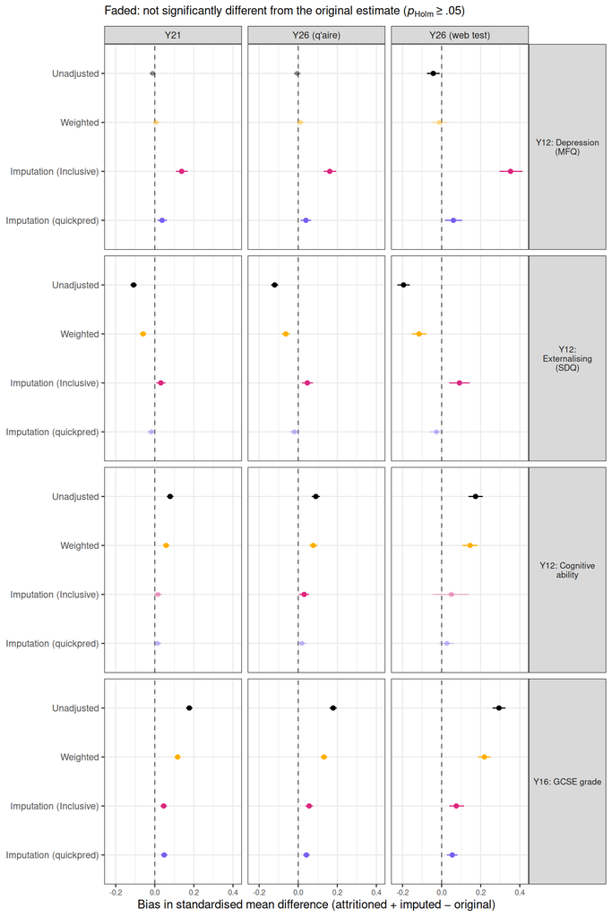

**Without Imputation (Inclusive)**. Download: PNG · PDF

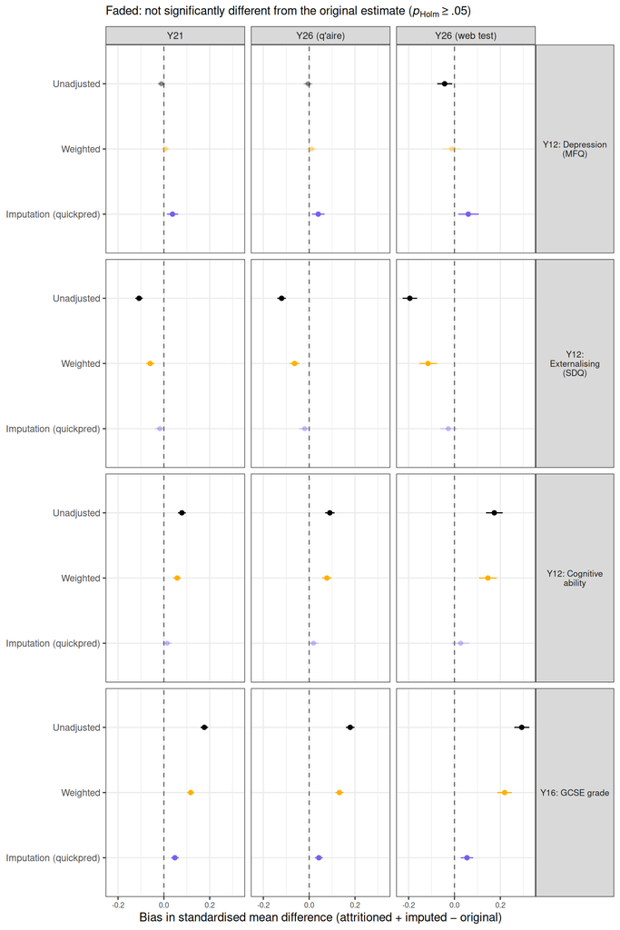

```r
show_both(plot_bias("var", "Bias in variance (proportional change: attritioned + imputed vs original)"), "16_bias_var", width = 10, height = 7)
```

**With Imputation (Inclusive)** (all methods). Download: PNG · PDF

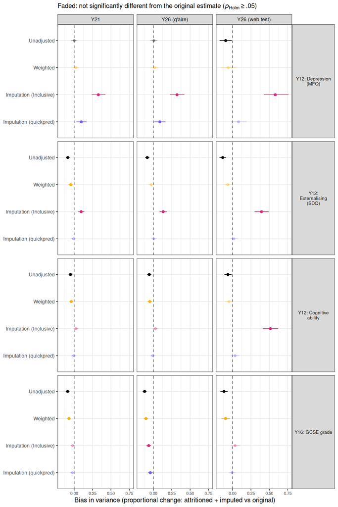

**Without Imputation (Inclusive)**. Download: PNG · PDF

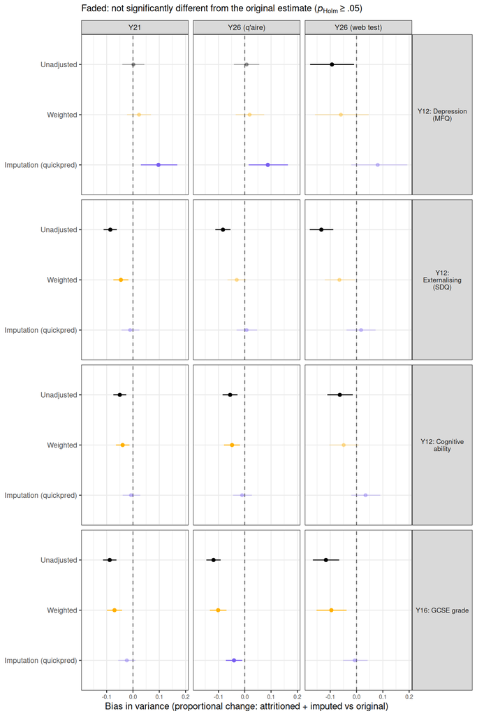

```r
show_both(plot_bias("cor", "Bias in correlation (attritioned + imputed − original)"), "16_bias_cor", width = 10, height = 10)
```

**With Imputation (Inclusive)** (all methods). Download: PNG · PDF

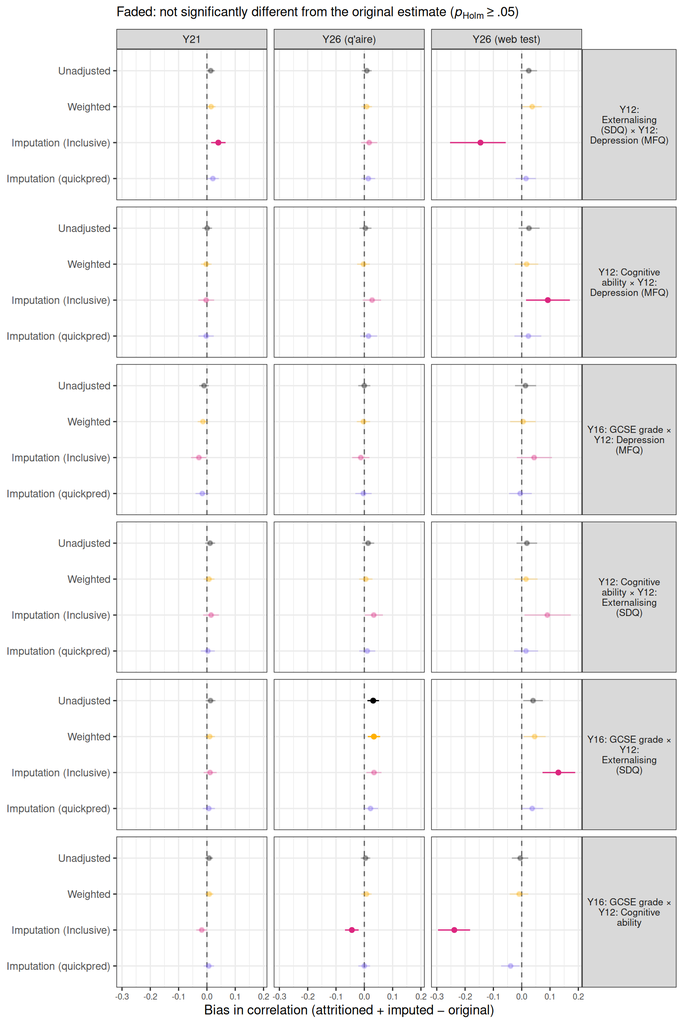

**Without Imputation (Inclusive)**. Download: PNG · PDF

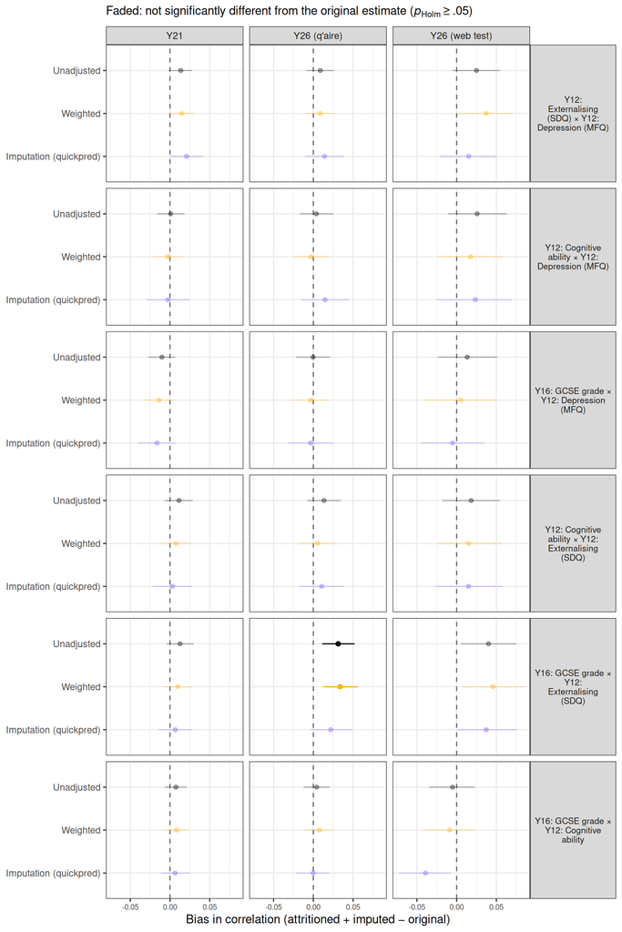

## ACE estimates

```r
ace = ace %>%                                                                   # pval_adj computed in summary-table (Holm family: method x time point x sex)
  mutate(par = toupper(par), sex = str_to_title(sex))

ace %>%
  group_by(par, timepoint, variant) %>%
  summarise(mean_abs_bias = mean(abs(y)), n_biased = sum(pval_adj < .05), n = dplyr::n(), .groups = "drop") %>%
  mutate(n_biased = paste0(n_biased, "/", n),
         variant  = factor(variant_plot_labels[as.character(variant)], levels = variant_plot_labels[variant_levels])) %>%   # same method labels as the plots
  select(-n) %>%
  pivot_wider(names_from = variant, values_from = c(mean_abs_bias, n_biased), names_glue = "{variant}__{.value}") %>%
  arrange(par, timepoint) %>%
  gt(groupname_col = "par", rowname_col = "timepoint") %>%
  tab_spanner_delim(delim = "__") %>%
  fmt_number(columns = contains("mean_"), decimals = 3) %>%
  cols_label_with(fn = ~ str_replace_all(.x, c("mean_abs_bias" = "|Bias|", "n_biased" = "Biased"))) %>%
  tab_style(style = cell_text(size = px(11)), locations = list(cells_body(), cells_stub(), cells_column_labels(), cells_column_spanners(), cells_row_groups())) %>%
  tab_footnote(md("Mean absolute bias in ACE components across the 4 outcomes × 2 sexes. Biased = p<sub>Holm</sub> < .05 (Holm-corrected over the 12 tests for A, C and E × 4 outcomes, separately for each method, time point and sex)."))
```

|  | Unadjusted \|Bias\| | Weighted \|Bias\| | Imputation (Inclusive) \|Bias\| | Imputation (quickpred) \|Bias\| | Unadjusted Biased | Weighted Biased | Imputation (Inclusive) Biased | Imputation (quickpred) Biased |
| --- | --- | --- | --- | --- | --- | --- | --- | --- |
| A |  |  |  |  |  |  |  |  |
| Y21 | 0.054 | 0.058 | 0.053 | 0.051 | 0/8 | 0/8 | 0/8 | 0/8 |
| Y26 (q'aire) | 0.076 | 0.085 | 0.062 | 0.034 | 0/8 | 0/8 | 0/8 | 0/8 |
| Y26 (web test) | 0.066 | 0.078 | 0.132 | 0.115 | 0/8 | 0/8 | 0/8 | 0/8 |
| C |  |  |  |  |  |  |  |  |
| Y21 | 0.045 | 0.050 | 0.061 | 0.038 | 0/8 | 0/8 | 0/8 | 0/8 |
| Y26 (q'aire) | 0.072 | 0.085 | 0.067 | 0.036 | 0/8 | 0/8 | 0/8 | 0/8 |
| Y26 (web test) | 0.076 | 0.098 | 0.119 | 0.118 | 0/8 | 0/8 | 2/8 | 0/8 |
| E |  |  |  |  |  |  |  |  |
| Y21 | 0.021 | 0.017 | 0.050 | 0.022 | 0/8 | 0/8 | 1/8 | 0/8 |
| Y26 (q'aire) | 0.013 | 0.009 | 0.073 | 0.030 | 0/8 | 0/8 | 2/8 | 0/8 |
| Y26 (web test) | 0.037 | 0.034 | 0.212 | 0.054 | 0/8 | 0/8 | 5/8 | 0/8 |

Mean absolute bias in ACE components across the 4 outcomes × 2 sexes. Biased = p<sub>Holm</sub> < .05 (Holm-corrected over the 12 tests for A, C and E × 4 outcomes, separately for each method, time point and sex).

```r
p = ace %>%
  mutate(variable = factor(variable, levels = rq6y_labels), variant = fct_rev(variant)) %>%
  ggplot(aes(x = y, xmin = ymin, xmax = ymax, y = variant, colour = variant, alpha = pval_adj < .05)) +
  geom_vline(xintercept = 0, linetype = "dashed", colour = "grey40") +
  geom_pointrange(size = .2) +
  facet_grid(variable + sex ~ par + timepoint, labeller = labeller(variable = label_wrap_gen(14))) +
  scale_colour_manual(values = variant_colours, labels = variant_plot_labels) +
  scale_alpha_manual(values = c("TRUE" = 1, "FALSE" = .3), guide = "none") +
  labs(x = "Bias in ACE component (adjusted attritioned − original)", y = NULL, colour = NULL, subtitle = subtitle_holm) +
  theme_bw() +
  theme(strip.text.y = element_text(angle = 0, size = 7), strip.text.x = element_text(size = 7),
        axis.text.x = element_text(size = 6, angle = 90, vjust = .5), axis.text.y = element_blank(), axis.ticks.y = element_blank(),
        legend.position = "bottom")

show_both(p, "16_bias_ace", width = 14, height = 9)
```

**With Imputation (Inclusive)** (all methods). Download: PNG · PDF

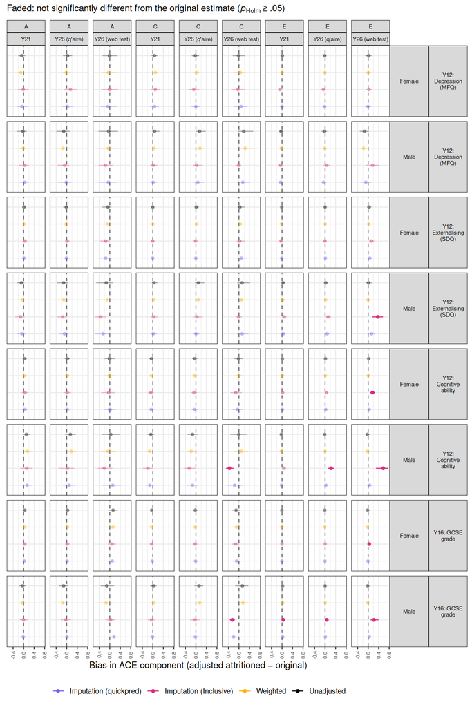

**Without Imputation (Inclusive)**. Download: PNG · PDF

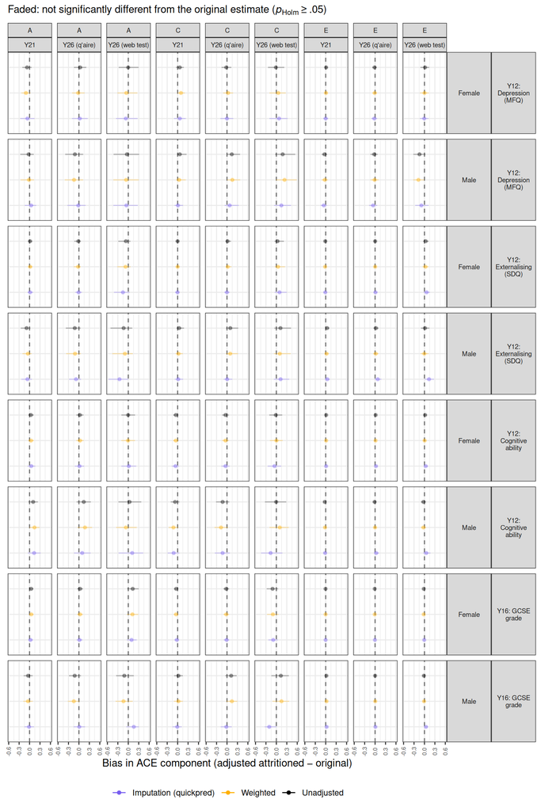

## Convergence Check

Mean and SD of the imputed outcome values at each of the 75 iterations (`chainMean`, `chainVar` of the mids objects). Convergence is suggested by chains that mix and show no trend after the first few iterations.

```r
# Chain means and SDs of `vars`, for every mids object (one per imputation x sex-zygosity group x time point),
# with the number of imputed cells per variable (used to pool the groups below)
extract_traces = function(all_imputations, tasks, vars, variant) {
  map_dfr(tasks$i, function(k) {
    mids_obj = all_imputations[[k]]
    v        = intersect(vars, dimnames(mids_obj$chainMean)[[1]])
    n_iter   = dim(mids_obj$chainMean)[2]
    tibble(
      var       = rep(v, times = n_iter),
      iteration = rep(seq_len(n_iter), each = length(v)),
      mean      = as.vector(mids_obj$chainMean[v, , 1, drop = FALSE]),           # variables x iterations (m = 1 per mids object)
      sd        = sqrt(as.vector(mids_obj$chainVar[v, , 1, drop = FALSE])),
      n_imp     = rep(colSums(mids_obj$where[, v, drop = FALSE]), times = n_iter),
      task      = k
    )
  }) %>%
    left_join(tasks %>% select(i, timepoint, sexzyg, imputation), by = c("task" = "i")) %>%
    mutate(
      twin     = paste("Twin", str_extract(var, "\\d$")),
      variable = if_else(var %in% rq6y_all, rq6y_labels[match(str_remove(var, "\\d$"), rq6y_prefix)], str_remove(var, "\\d$")),
      variant  = variant
    )
}

trace_vars = c(rq6y_all, pgs_vars1)                                             # outcomes + twin 1 PGS (co-twin PGS are not imputed in MZ groups)

all_imputations = readRDS(results_file("8_1_all_imputations", tag))
traces_qp       = extract_traces(all_imputations, tasks, trace_vars, "quickpred")
rm(all_imputations); gc()
```

```
            used  (Mb) gc trigger    (Mb)   max used    (Mb)
Ncells   4526591 241.8   78535092  4194.3   98168864  5242.8
Vcells 119609793 912.6 2138577293 16316.1 2668468628 20358.8
```

```r
tasks_inc       = readRDS(results_file("8_1_tasks")) %>% mutate(i = 1:nrow(.)) %>% filter(timepoint %in% rq1y_twin)
all_imputations = readRDS(results_file("8_1_all_imputations"))
traces_inc      = extract_traces(all_imputations, tasks_inc, trace_vars, "Inclusive")
rm(all_imputations); gc()
```

```
            used   (Mb) gc trigger    (Mb)   max used    (Mb)
Ncells   4526650  241.8  400430366 21385.3  307409548 16417.5
Vcells 184512743 1407.8 2465263608 18808.5 3002404735 22906.6
```

```r
testthat::test_that("Chain traces extracted for every task and outcome", {
  testthat::expect_equal(n_distinct(traces_qp$task),  nrow(tasks))
  testthat::expect_equal(n_distinct(traces_inc$task), nrow(tasks_inc))
  for (tr in list(traces_qp, traces_inc)) {
    o = tr %>% filter(var %in% rq6y_all)
    testthat::expect_false(anyNA(o$mean[o$n_imp > 0]))
  }
})
```

```
Test passed 😸
```

```r
# Pool the chains of all imputations and sex-zygosity groups at each iteration
pool_traces = function(tr) {
  tr %>%
    filter(n_imp > 0, !is.na(mean)) %>%
    group_by(variant, timepoint, var, variable, twin, iteration) %>%
    summarise(
      Mean = weighted.mean(mean, n_imp),
      SD   = sqrt(sum(n_imp * (sd^2 + (mean - Mean)^2)) / sum(n_imp)),        # total variance = within + between chains
      .groups = "drop"
    ) %>%
    pivot_longer(c(Mean, SD), names_to = "statistic") %>%
    mutate(timepoint = factor(tp_labels[timepoint], levels = rq1y_twin_labels_clean_extrashort))
}

pooled = bind_rows(pool_traces(traces_qp), pool_traces(traces_inc)) %>%
  mutate(variant = factor(variant, levels = names(variant_colours)))

plot_pooled_outcomes = function(v) {
  pooled %>%
    filter(variant == v, var %in% rq6y_all) %>%
    mutate(variable = factor(variable, levels = rq6y_labels)) %>%
    ggplot(aes(x = iteration, y = value, colour = timepoint)) +
    geom_line() +
    facet_wrap(statistic + twin ~ variable, scales = "free_y", ncol = 4, labeller = labeller(.multi_line = FALSE)) +   # free y-axis in every panel
    labs(x = "Iteration", y = NULL, colour = "Attrition time point",
         title = paste0("Imputation: ", v, ". Imputed outcome values, pooled across 250 imputations and sex-zygosity groups")) +
    theme_bw() +
    theme(legend.position = "bottom", strip.text = element_text(size = 8), plot.title = element_text(size = 11))
}
```

### Pooled across all imputations and sex-zygosity groups

As the `plot()` of the combined mids objects in `8_rq6_3` (`mice::rbind` averages `chainMean` over the combined objects, weighted by their number of imputed cells), but over all 250 imputations. At each iteration, the mean of all imputed values of a variable is the weighted mean of the chain means (weights = number of imputed cells in each sex-zygosity group). The SD is the SD of all imputed values, pooled from the chain means and SDs (unlike `mice::rbind`, which averages the within-chain variances and ignores the differences in means between groups).

#### Outcomes: quickpred

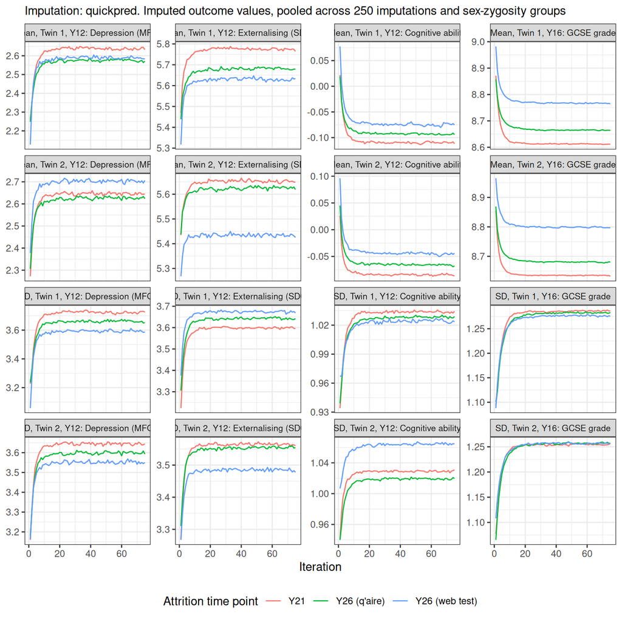

```r
plot_pooled_outcomes("quickpred")
```

```r
save_plot("15_quickpred_convergence_pooled", width = 10, height = 8)
```

#### Outcomes: Inclusive

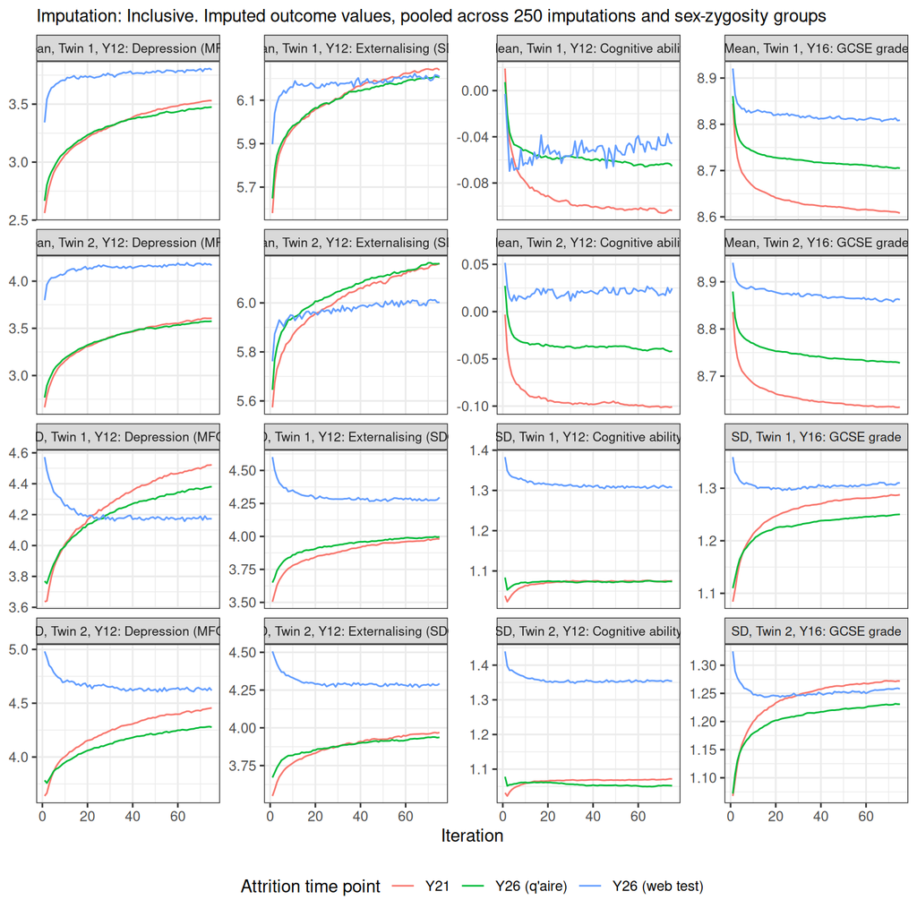

```r
plot_pooled_outcomes("Inclusive")
```

```r
save_plot("15_inclusive_convergence_pooled", width = 10, height = 8)
```